# GWAS Accelerometry UEA

## 15.4 Leave-one-out sensitivity visualizations

Leave-one-out analyses evaluate the influence of individual SNP instruments on causal estimates, ensuring that results are not driven by single variants and highlighting potential influential outliers.

```r
############################################################
# SECTION 15.4 — Improved Leave-one-out MR sensitivity plots
# (robust, readable, publication-grade)
############################################################

library(dplyr)
library(ggplot2)

#-----------------------------------------------------------
# Output directory
#-----------------------------------------------------------
out_dir <- "C:/Users/75118/Desktop/UEA/Proyecto 1/MainMRresults/LOO_figures_clean"
dir.create(out_dir, showWarnings = FALSE, recursive = TRUE)

#-----------------------------------------------------------
# Select only important MR pairs
# (robust + FDR significant — avoids useless clutter)
#-----------------------------------------------------------

important_pairs <- sens2 %>%      # from Section 15.3.2
  filter(!is.na(q) & q < 0.05) %>%
  distinct(exposure, outcome)

loo_pairs <- mr_loo %>%
  semi_join(important_pairs, by = c("exposure","outcome")) %>%
  distinct(exposure, outcome) %>%
  arrange(outcome, exposure)

#-----------------------------------------------------------
# Improved LOO plotting function
#-----------------------------------------------------------

plot_loo_clean <- function(exp, out, top_snps = 25) {

  df <- mr_loo %>%
    filter(
      exposure == exp,
      outcome == out,
      SNP != "All"
    )

  if (nrow(df) < 3) return(NULL)

  # Baseline IVW estimate (full instrument set)
  ivw_base <- mr_results %>%
    filter(
      exposure == exp,
      outcome == out,
      method == "Inverse variance weighted (multiplicative random effects)"
    ) %>%
    pull(b)

  if (length(ivw_base) == 0) ivw_base <- mean(df$b, na.rm = TRUE)

  # Rank SNPs by absolute influence
  df <- df %>%
    mutate(influence = abs(b)) %>%
    arrange(desc(influence)) %>%
    slice_head(n = top_snps)

  # Flag extreme influence SNPs (top 10%)
  df <- df %>%
    mutate(
      extreme = influence >= quantile(influence, 0.90, na.rm = TRUE)
    )

  ggplot(df, aes(y = reorder(SNP, b), x = b)) +

    # Baseline IVW effect
    geom_vline(
      xintercept = ivw_base,
      color = "black",
      linewidth = 0.6
    ) +

    # Null line
    geom_vline(
      xintercept = 0,
      linetype = "dashed",
      color = "grey50"
    ) +

    # Confidence intervals
    geom_errorbarh(
      aes(xmin = b - 1.96 * se, xmax = b + 1.96 * se),
      height = 0.25,
      color = "grey40"
    ) +

    # Points
    geom_point(
      aes(color = extreme),
      size = 2.3
    ) +

    scale_color_manual(
      values = c(`TRUE` = "#D1495B", `FALSE` = "#2E86AB"),
      labels = c("FALSE" = "Typical SNP", "TRUE" = "High influence")
    ) +

    labs(
      title = paste("LOO MR:", exp, "→", out),
      subtitle = paste("Top", top_snps, "SNPs ranked by influence on IVW estimate"),
      x = "IVW causal effect (β ± 95% CI)",
      y = NULL,
      color = NULL
    ) +

    theme_bw(base_size = 12) +
    theme(
      axis.text.y = element_text(size = 7.5),
      plot.title  = element_text(face = "bold"),
      legend.position = "bottom",
      panel.grid.minor = element_blank()
    )
}

#-----------------------------------------------------------
# Generate + save figures (grouped by outcome)
#-----------------------------------------------------------

outcomes <- unique(loo_pairs$outcome)

for (out in outcomes) {

  # Open collapsible block in Rmd
  cat("\n<details>\n")
  cat(paste0(
    "<summary><b>", out,
    " — Leave-one-out MR sensitivity (cleaned)</b></summary>\n\n"
  ))

  these_pairs <- loo_pairs %>%
    filter(outcome == out)

  for (i in seq_len(nrow(these_pairs))) {

    exp <- these_pairs$exposure[i]

    p <- plot_loo_clean(exp, out, top_snps = 25)

    if (is.null(p)) next

    file_name <- paste0(
      out_dir, "/LOO_clean_",
      gsub("[^A-Za-z0-9]", "_", exp), "_",
      gsub("[^A-Za-z0-9]", "_", out), ".png"
    )

    # Save publication-grade figure
    ggsave(
      filename = file_name,
      plot = p,
      width = 6.5,
      height = 5.5,
      dpi = 300
    )

    # Render inline
    print(p)
  }

  cat("\n</details>\n")
}



############################################################
# SECTION 15.4 — Leave-one-out MR sensitivity (TRUE fixed size)
############################################################

library(dplyr)
library(ggplot2)
library(patchwork)

out_dir <- "C:/Users/75118/Desktop/UEA/Proyecto 1/MainMRresults/15.4_LOO"
dir.create(out_dir, showWarnings = FALSE, recursive = TRUE)


#-----------------------------------------------------------
# Standardize exposure/outcome naming (case-safe join)
#-----------------------------------------------------------

sens2 <- sens2 %>%
  mutate(
    exposure = toupper(trimws(as.character(exposure))),
    outcome  = toupper(trimws(as.character(outcome)))
  )

mr_loo <- mr_loo %>%
  mutate(
    exposure = toupper(trimws(as.character(exposure))),
    outcome  = toupper(trimws(as.character(outcome)))
  )


mr_results <- mr_results %>%
  mutate(
    exposure = toupper(trimws(as.character(exposure))),
    outcome  = toupper(trimws(as.character(outcome)))
  )

#-----------------------------------------------------------
# Important MR pairs only
#-----------------------------------------------------------

important_pairs <- sens2 %>%
  filter(!is.na(q) & q < 0.05) %>%
  distinct(exposure, outcome)

loo_pairs <- mr_loo %>%
  semi_join(important_pairs, by = c("exposure","outcome")) %>%
  distinct(exposure, outcome)


#-----------------------------------------------------------
# Compute GLOBAL x-limits PER OUTCOME (critical fix)
#-----------------------------------------------------------

x_limits <- mr_loo %>%
  semi_join(loo_pairs, by = c("exposure","outcome")) %>%
  filter(SNP != "All") %>%
  mutate(
    low  = b - 1.96 * se,
    high = b + 1.96 * se
  ) %>%
  group_by(outcome) %>%
  summarise(
    xmin = min(c(low, 0), na.rm = TRUE),
    xmax = max(c(high, 0), na.rm = TRUE),
    .groups = "drop"
  ) %>%
  mutate(pad = 0.05 * (xmax - xmin),
         xmin = xmin - pad,
         xmax = xmax + pad)

#-----------------------------------------------------------
# Final LOO plot (now uses fixed outcome-scale)
#-----------------------------------------------------------

plot_loo_clean <- function(exp, out, top_snps = 25) {

  df <- mr_loo %>%
    filter(exposure == exp, outcome == out, SNP != "All")

  if (nrow(df) < 3) return(NULL)

  ivw_base <- mr_results %>%
    filter(
      exposure == exp,
      outcome == out,
      method == "Inverse variance weighted (multiplicative random effects)"
    ) %>%
    pull(b)

  if (length(ivw_base) == 0) ivw_base <- mean(df$b)

  df <- df %>%
    mutate(influence = abs(b)) %>%
    arrange(desc(influence)) %>%
    slice_head(n = top_snps) %>%
    mutate(extreme = influence >= quantile(influence, 0.90))

  lims <- x_limits %>% filter(outcome == out)

  ggplot(df, aes(y = reorder(SNP, b), x = b)) +

    geom_vline(xintercept = ivw_base, linewidth = 0.6) +
    geom_vline(xintercept = 0, linetype = "dashed", color = "grey60") +

    geom_errorbarh(
      aes(xmin = b - 1.96 * se, xmax = b + 1.96 * se),
      height = 0.25,
      color = "grey40"
    ) +

    geom_point(aes(color = extreme), size = 2.3) +

    scale_color_manual(
      values = c(`TRUE` = "#D1495B", `FALSE` = "#2E86AB"),
      labels = c("FALSE" = "Typical SNP", "TRUE" = "High influence")
    ) +

    scale_x_continuous(
      limits = c(lims$xmin, lims$xmax),
      expand = c(0, 0)
    ) +

    labs(
      title = paste("LOO MR:", exp, "→", out),
      subtitle = "Top 25 SNPs ranked by influence on IVW estimate",
      x = "IVW causal effect (β ± 95% CI)",
      y = NULL,
      color = NULL
    ) +

    theme_bw(base_size = 12) +
    theme(
      axis.text.y = element_text(size = 7.5),
      plot.title = element_text(face = "bold", size = 13),
      plot.margin = margin(6,6,6,6),
      legend.position = "bottom",
      panel.grid.minor = element_blank()
    )
}

#-----------------------------------------------------------
# Grid export (fixed canvas forever)
#-----------------------------------------------------------

############################################################
# Smart grid export — no empty space, same panel scaling
############################################################

library(cowplot)   # better for tight grids than patchwork

outcomes <- unique(loo_pairs$outcome)

plots_per_row <- 2   # keep 2 columns (journal standard)
max_plots_page <- 6  # still chunk to avoid overcrowding

chunk_list <- function(x, n) split(x, ceiling(seq_along(x)/n))

for (out in outcomes) {

  these_pairs <- loo_pairs %>% filter(outcome == out)
  if (nrow(these_pairs) == 0) next

  plot_list <- lapply(seq_len(nrow(these_pairs)), function(i) {
    plot_loo_clean(these_pairs$exposure[i], out)
  })

  plot_list <- Filter(Negate(is.null), plot_list)

  blocks <- chunk_list(plot_list, max_plots_page)

  for (b in seq_along(blocks)) {

    block <- blocks[[b]]

    # dynamic rows — no empty space
    n_rows <- ceiling(length(block) / plots_per_row)

    block_plot <- plot_grid(
      plotlist = block,
      ncol = plots_per_row,
      nrow = n_rows,
      align = "hv"
    )

    file_name <- file.path(
      out_dir,
      paste0(
        "LOO_Block_",
        gsub("[^A-Za-z0-9]", "_", out),
        "_Part_", b,
        ".png"
      )
    )

    # Height scales with rows, width constant → panel size same
    ggsave(
      filename = file_name,
      plot = block_plot,
      width = 12,
      height = 4 * n_rows,   # each row same height
      dpi = 300
    )

    cat("Saved compressed block:", file_name, "\n")
  }
}
```

Saved compressed block: C:/Users/75118/Desktop/UEA/Proyecto 1/MainMRresults/15.4_LOO/LOO_Block_PARENTAL_LIFESPAN_Part_1.png Saved compressed block: C:/Users/75118/Desktop/UEA/Proyecto 1/MainMRresults/15.4_LOO/LOO_Block_PARENTAL_LIFESPAN_Part_2.png Saved compressed block: C:/Users/75118/Desktop/UEA/Proyecto 1/MainMRresults/15.4_LOO/LOO_Block_USUAL_WALKING_PACE_Part_1.png Saved compressed block: C:/Users/75118/Desktop/UEA/Proyecto 1/MainMRresults/15.4_LOO/LOO_Block_USUAL_WALKING_PACE_Part_2.png Saved compressed block: C:/Users/75118/Desktop/UEA/Proyecto 1/MainMRresults/15.4_LOO/LOO_Block_HEALTHSPAN_Part_1.png Saved compressed block: C:/Users/75118/Desktop/UEA/Proyecto 1/MainMRresults/15.4_LOO/LOO_Block_HEALTHSPAN_Part_2.png

```r
############################################################
# DONE — blocks now perfectly identical
############################################################






############################################################
# SECTION 15.4.1 — Leave-one-out stability summary (quantitative)
############################################################

library(dplyr)
library(gt)
library(kableExtra)
library(openxlsx)

#-----------------------------------------------------------
# Output
#-----------------------------------------------------------

out_dir <- "C:/Users/75118/Desktop/UEA/Proyecto 1/MainMRresults"
dir.create(out_dir, showWarnings = FALSE, recursive = TRUE)

png_file   <- file.path(out_dir, "Section_15.4_LOO_Stability_Summary.png")
excel_file <- file.path(out_dir, "Section_15.4_LOO_Stability_Summary.xlsx")

#-----------------------------------------------------------
# Baseline IVW effects (full instrument set)
#-----------------------------------------------------------

ivw_base <- mr_results %>%
  dplyr::filter(method == "Inverse variance weighted (multiplicative random effects)") %>%
  dplyr::select(exposure, outcome, ivw_b = b)

#-----------------------------------------------------------
# Build LOO stability metrics
#-----------------------------------------------------------

loo_stats <- mr_loo %>%
  filter(SNP != "All") %>%
  group_by(exposure, outcome) %>%
  summarise(
    mean_loo_b = mean(b, na.rm = TRUE),
    sd_loo_b   = sd(b, na.rm = TRUE),
    min_loo_b  = min(b, na.rm = TRUE),
    max_loo_b  = max(b, na.rm = TRUE),
    .groups = "drop"
  ) %>%
  left_join(ivw_base, by = c("exposure","outcome")) %>%
  mutate(

    # absolute worst deviation from baseline IVW
    max_shift = pmax(
      abs(max_loo_b - ivw_b),
      abs(min_loo_b - ivw_b)
    ),

    # relative % shift
    pct_shift = 100 * max_shift / abs(ivw_b),

    # direction flip check
    direction_flip = ifelse(
      (min_loo_b < 0 & ivw_b > 0) | (max_loo_b > 0 & ivw_b < 0),
      "⚠️ Yes",
      "No"
    ),

    # automatic instability flag (conservative but journal-safe)
    unstable = case_when(
      direction_flip == "⚠️ Yes" ~ "⚠️ Unstable",
      pct_shift > 20             ~ "⚠️ Large shift",
      sd_loo_b > 0.05 * abs(ivw_b) ~ "⚠️ High variability",
      TRUE ~ "Stable"
    )
  ) %>%
  arrange(outcome, desc(pct_shift))

#-----------------------------------------------------------
# Clean display table
#-----------------------------------------------------------

loo_display <- loo_stats %>%
  transmute(
    Exposure = exposure,
    Outcome  = outcome,
    `IVW β` = round(ivw_b, 4),
    `Mean LOO β` = round(mean_loo_b, 4),
    `SD across LOO` = round(sd_loo_b, 4),
    `Max shift` = round(max_shift, 4),
    `% shift` = round(pct_shift, 2),
    `Direction flip?` = direction_flip,
    Stability = unstable
  )

#===========================================================
# 1) R MARKDOWN DISPLAY (scrollable)
#===========================================================

kbl(
  loo_display,
  caption = "Table 15.4a. Quantitative leave-one-out stability summary of MR causal estimates",
  align = "c"
) %>%
  kable_styling(
    full_width = FALSE,
    position = "center",
    bootstrap_options = c("striped","hover")
  ) %>%
  scroll_box(height = "450px", width = "100%")
```

Table 15.4a. Quantitative leave-one-out stability summary of MR causal estimates

| Exposure | Outcome | IVW β | Mean LOO β | SD across LOO | Max shift | % shift | Direction flip? | Stability |
| --- | --- | --- | --- | --- | --- | --- | --- | --- |
| CHRONOTYPE | HEALTHSPAN | -0.0232 | -0.0232 | 0.0027 | 0.0110 | 47.30 | No | ⚠️ Large shift |
| CRP | HEALTHSPAN | 0.0414 | 0.0414 | 0.0027 | 0.0188 | 45.36 | No | ⚠️ Large shift |
| BMD | HEALTHSPAN | -0.0258 | -0.0258 | 0.0009 | 0.0074 | 28.55 | No | ⚠️ Large shift |
| GRIP_STRENGTH | HEALTHSPAN | -0.0473 | -0.0473 | 0.0046 | 0.0134 | 28.22 | No | ⚠️ Large shift |
| WBC | HEALTHSPAN | 0.0243 | 0.0243 | 0.0011 | 0.0053 | 21.65 | No | ⚠️ Large shift |
| SUGAR_INTAKE | HEALTHSPAN | 0.1102 | 0.1102 | 0.0122 | 0.0238 | 21.55 | No | ⚠️ Large shift |
| LEISURE_SCREEN_T | HEALTHSPAN | 0.0941 | 0.0941 | 0.0059 | 0.0157 | 16.67 | No | ⚠️ High variability |
| TRIGLYCERIDES | HEALTHSPAN | 0.1013 | 0.1013 | 0.0018 | 0.0149 | 14.72 | No | Stable |
| FAT_MASS | HEALTHSPAN | 0.1278 | 0.1278 | 0.0036 | 0.0153 | 11.96 | No | Stable |
| FEV1 | HEALTHSPAN | -0.0823 | -0.0823 | 0.0022 | 0.0089 | 10.83 | No | Stable |
| FAT_FREE_MASS | HEALTHSPAN | 0.0559 | 0.0559 | 0.0013 | 0.0054 | 9.70 | No | Stable |
| LDL | HEALTHSPAN | 0.0919 | 0.0919 | 0.0015 | 0.0083 | 9.06 | No | Stable |
| HDL | HEALTHSPAN | -0.0467 | -0.0467 | 0.0009 | 0.0042 | 8.96 | No | Stable |
| HBA1C | HEALTHSPAN | 0.0968 | 0.0968 | 0.0009 | 0.0052 | 5.40 | No | Stable |
| WHR_ADJBMI | HEALTHSPAN | 0.1760 | 0.1760 | 0.0014 | 0.0088 | 5.01 | No | Stable |
| WC_ADJBMI | HEALTHSPAN | 0.3094 | 0.3094 | 0.0034 | 0.0126 | 4.08 | No | Stable |
| ACC_RELATIVE_AMPLITUDE | HEALTHSPAN | NA | 0.0965 | 0.0684 | NA | NA | NA | Stable |
| ACC_TOTAL_LOG | HEALTHSPAN | NA | -0.0160 | 0.0677 | NA | NA | NA | Stable |
| CRF_SLOPE | HEALTHSPAN | NA | -0.0959 | 0.2437 | NA | NA | NA | Stable |
| CRF_VO2MAX | HEALTHSPAN | NA | -0.0562 | 0.0196 | NA | NA | NA | Stable |
| RESTING_HEART_RATE | HEALTHSPAN | NA | -0.0007 | 0.0014 | NA | NA | NA | Stable |
| SELF_MVPA | HEALTHSPAN | NA | -0.1178 | 0.0341 | NA | NA | NA | Stable |
| SMOKING_INITIATION | HEALTHSPAN | NA | 0.3337 | 0.0099 | NA | NA | NA | Stable |
| WALKING_DAYS | HEALTHSPAN | NA | 0.0596 | 0.0235 | NA | NA | NA | Stable |
| ACC_TOTAL_LOG | PARENTAL_LIFESPAN | -0.0078 | -0.0056 | 0.1268 | 0.1420 | 1827.80 | ⚠️ Yes | ⚠️ Unstable |
| WALKING_DAYS | PARENTAL_LIFESPAN | 0.0062 | 0.0062 | 0.0223 | 0.0366 | 592.32 | ⚠️ Yes | ⚠️ Unstable |
| SELF_MVPA | PARENTAL_LIFESPAN | 0.1147 | 0.1146 | 0.0442 | 0.0843 | 73.46 | No | ⚠️ Large shift |
| CHRONOTYPE | PARENTAL_LIFESPAN | 0.0173 | 0.0173 | 0.0023 | 0.0063 | 36.26 | No | ⚠️ Large shift |
| CRP | PARENTAL_LIFESPAN | -0.0446 | -0.0447 | 0.0025 | 0.0146 | 32.81 | No | ⚠️ Large shift |
| SUGAR_INTAKE | PARENTAL_LIFESPAN | -0.1128 | -0.1128 | 0.0105 | 0.0219 | 19.42 | No | ⚠️ High variability |
| GRIP_STRENGTH | PARENTAL_LIFESPAN | 0.0727 | 0.0727 | 0.0047 | 0.0139 | 19.13 | No | ⚠️ High variability |
| LEISURE_SCREEN_T | PARENTAL_LIFESPAN | -0.0534 | -0.0534 | 0.0047 | 0.0095 | 17.74 | No | ⚠️ High variability |
| FAT_FREE_MASS | PARENTAL_LIFESPAN | -0.0372 | -0.0372 | 0.0011 | 0.0064 | 17.28 | No | Stable |
| WBC | PARENTAL_LIFESPAN | -0.0282 | -0.0282 | 0.0009 | 0.0047 | 16.78 | No | Stable |
| BMD | PARENTAL_LIFESPAN | 0.0253 | 0.0253 | 0.0006 | 0.0041 | 16.13 | No | Stable |
| HBA1C | PARENTAL_LIFESPAN | -0.0392 | -0.0392 | 0.0008 | 0.0045 | 11.39 | No | Stable |
| FEV1 | PARENTAL_LIFESPAN | 0.0758 | 0.0758 | 0.0020 | 0.0080 | 10.56 | No | Stable |
| HDL | PARENTAL_LIFESPAN | 0.0552 | 0.0552 | 0.0008 | 0.0057 | 10.35 | No | Stable |
| FAT_MASS | PARENTAL_LIFESPAN | -0.1273 | -0.1273 | 0.0026 | 0.0103 | 8.06 | No | Stable |
| TRIGLYCERIDES | PARENTAL_LIFESPAN | -0.1177 | -0.1177 | 0.0013 | 0.0078 | 6.61 | No | Stable |
| WHR_ADJBMI | PARENTAL_LIFESPAN | -0.0994 | -0.0994 | 0.0012 | 0.0058 | 5.85 | No | Stable |
| WC_ADJBMI | PARENTAL_LIFESPAN | -0.2163 | -0.2163 | 0.0029 | 0.0111 | 5.11 | No | Stable |
| SMOKING_INITIATION | PARENTAL_LIFESPAN | -0.5456 | -0.5456 | 0.0115 | 0.0253 | 4.64 | No | Stable |
| LDL | PARENTAL_LIFESPAN | -0.1736 | -0.1736 | 0.0013 | 0.0069 | 4.00 | No | Stable |
| ACC_RELATIVE_AMPLITUDE | PARENTAL_LIFESPAN | NA | 0.1290 | 0.0725 | NA | NA | NA | Stable |
| CRF_SLOPE | PARENTAL_LIFESPAN | NA | 0.2068 | 0.3252 | NA | NA | NA | Stable |
| CRF_VO2MAX | PARENTAL_LIFESPAN | NA | 0.0828 | 0.0094 | NA | NA | NA | Stable |
| RESTING_HEART_RATE | PARENTAL_LIFESPAN | NA | -0.0030 | 0.0012 | NA | NA | NA | Stable |
| ACC_RELATIVE_AMPLITUDE | USUAL_WALKING_PACE | 0.0644 | 0.0762 | 0.0824 | 0.1049 | 162.98 | No | ⚠️ Large shift |
| TRIGLYCERIDES | USUAL_WALKING_PACE | -0.0068 | -0.0068 | 0.0007 | 0.0074 | 109.61 | No | ⚠️ Large shift |
| LDL | USUAL_WALKING_PACE | 0.0021 | 0.0021 | 0.0003 | 0.0017 | 80.68 | No | ⚠️ Large shift |
| ACC_TOTAL_LOG | USUAL_WALKING_PACE | 0.0438 | 0.0439 | 0.0261 | 0.0347 | 79.26 | No | ⚠️ Large shift |
| RESTING_HEART_RATE | USUAL_WALKING_PACE | -0.0019 | -0.0019 | 0.0006 | 0.0012 | 63.86 | No | ⚠️ Large shift |
| BMD | USUAL_WALKING_PACE | -0.0024 | -0.0024 | 0.0002 | 0.0014 | 60.86 | No | ⚠️ Large shift |
| HDL | USUAL_WALKING_PACE | 0.0044 | 0.0044 | 0.0002 | 0.0016 | 37.08 | No | ⚠️ Large shift |
| CRP | USUAL_WALKING_PACE | -0.0394 | -0.0394 | 0.0015 | 0.0128 | 32.57 | No | ⚠️ Large shift |
| HBA1C | USUAL_WALKING_PACE | -0.0094 | -0.0094 | 0.0002 | 0.0016 | 16.48 | No | Stable |
| FAT_FREE_MASS | USUAL_WALKING_PACE | 0.0146 | 0.0146 | 0.0004 | 0.0023 | 15.46 | No | Stable |
| SUGAR_INTAKE | USUAL_WALKING_PACE | -0.0568 | -0.0568 | 0.0043 | 0.0085 | 14.94 | No | ⚠️ High variability |
| CHRONOTYPE | USUAL_WALKING_PACE | 0.0197 | 0.0197 | 0.0010 | 0.0028 | 14.01 | No | Stable |
| SELF_MVPA | USUAL_WALKING_PACE | 0.1376 | 0.1377 | 0.0096 | 0.0175 | 12.76 | No | ⚠️ High variability |
| WHR_ADJBMI | USUAL_WALKING_PACE | 0.0146 | 0.0146 | 0.0004 | 0.0018 | 12.65 | No | Stable |
| SMOKING_INITIATION | USUAL_WALKING_PACE | -0.0972 | -0.0972 | 0.0046 | 0.0098 | 10.09 | No | Stable |
| WC_ADJBMI | USUAL_WALKING_PACE | 0.0457 | 0.0457 | 0.0010 | 0.0045 | 9.95 | No | Stable |
| WBC | USUAL_WALKING_PACE | -0.0302 | -0.0302 | 0.0003 | 0.0026 | 8.50 | No | Stable |
| FAT_MASS | USUAL_WALKING_PACE | -0.0988 | -0.0988 | 0.0010 | 0.0060 | 6.04 | No | Stable |
| FEV1 | USUAL_WALKING_PACE | 0.0762 | 0.0762 | 0.0007 | 0.0033 | 4.33 | No | Stable |
| LEISURE_SCREEN_T | USUAL_WALKING_PACE | -0.0855 | -0.0855 | 0.0014 | 0.0037 | 4.28 | No | Stable |
| GRIP_STRENGTH | USUAL_WALKING_PACE | 0.1430 | 0.1430 | 0.0015 | 0.0047 | 3.26 | No | Stable |
| CRF_SLOPE | USUAL_WALKING_PACE | NA | -0.0065 | 0.0710 | NA | NA | NA | Stable |
| CRF_VO2MAX | USUAL_WALKING_PACE | NA | 0.0232 | 0.0064 | NA | NA | NA | Stable |
| WALKING_DAYS | USUAL_WALKING_PACE | NA | 0.0365 | 0.0044 | NA | NA | NA | Stable |
| WALKING_TIME | USUAL_WALKING_PACE | NA | -0.1488 | 0.0306 | NA | NA | NA | Stable |

```r
#===========================================================
# 2) EXCEL EXPORT
#===========================================================

write.xlsx(
  loo_display,
  excel_file,
  overwrite = TRUE
)

#===========================================================
# 3) PUBLICATION-READY PNG (gt)
#===========================================================

gt_tbl <- gt(loo_display) %>%
  tab_header(
    title = md("**Leave-one-out stability summary**"),
    subtitle = md("Quantitative robustness of IVW MR estimates across SNP exclusions (Section 15.4)")
  ) %>%
  tab_style(
    style = cell_fill(color = "#FDEDEC"),
    locations = cells_body(rows = Stability != "Stable")
  ) %>%
  tab_style(
    style = cell_fill(color = "#E8F8F5"),
    locations = cells_body(rows = Stability == "Stable")
  ) %>%
  opt_all_caps(FALSE) %>%
  opt_table_outline() %>%
  tab_source_note(
    source_note = md(
      "Instability flags triggered by direction reversal, >20% maximal shift, or high LOO variability."
    )
  )

gtsave(
  gt_tbl,
  filename = png_file,
  vwidth = 2400,
  vheight = 1600,
  expand = 10
)

cat("🖼️ PNG saved:", png_file, "\n")
```

🖼️ PNG saved: C:/Users/75118/Desktop/UEA/Proyecto 1/MainMRresults/Section_15.4_LOO_Stability_Summary.png

```r
cat("📊 Excel saved:", excel_file, "\n")
```

📊 Excel saved: C:/Users/75118/Desktop/UEA/Proyecto 1/MainMRresults/Section_15.4_LOO_Stability_Summary.xlsx

## 15.5 Instrument strength table (F-statistics per exposure)

F-statistics are summarized across exposures to quantify instrument strength and verify that selected genetic instruments exceed conventional weak-instrument thresholds.

```r
############################################################
# SECTION 15.5 — Instrument strength (IDENTICAL LOGIC)
############################################################

library(data.table)
library(dplyr)
library(knitr)
library(kableExtra)
library(gt)

mapped_dir <- "C:/Users/75118/Desktop/UEA/Proyecto 1/mapped_full_traits"


files <- list.files(
  mapped_dir,
  pattern = "^mapped_full_.*\\.rds$",
  full.names = TRUE
)

p_instrument <- 5e-8

out_dir <- "C:/Users/75118/Desktop/UEA/Proyecto 1/MainMRresults"
dir.create(out_dir, showWarnings = FALSE, recursive = TRUE)

png_file <- file.path(out_dir, "Section_15.5_Table_Instrument_Strength.png")

fstats_list <- list()

#------------------------------------------------------------
# IDENTICAL FILTERING AS YOUR ORIGINAL CODE
#------------------------------------------------------------

for (f in files) {

  exp_name <- sub("mapped_full_|\\.rds", "", basename(f))

  cat("Processing:", exp_name, "\n")
  flush.console()

  exp_df   <- readRDS(f)

  exp_df$P <- 2 * pnorm(-abs(exp_df$BETA / exp_df$SE))
  exp_df$F_stat <- (exp_df$BETA^2) / (exp_df$SE^2)

  inst <- exp_df[exp_df$P < p_instrument & exp_df$F_stat >= 10, ]

  if (nrow(inst) == 0) next

  fstats_list[[exp_name]] <- data.table(
    trait  = exp_name,
    F_stat = inst$F_stat
  )

  rm(exp_df, inst)
  gc(FALSE)
}
```

Processing: Acc_L5_inactivity.rds Processing: Acc_LIPA.rds Processing: Acc_MVPA.rds Processing: Acc_relative_amplitude.rds Processing: Acc_total_log.rds Processing: BMD.rds Processing: Chronotype.rds Processing: CRF_slope.rds Processing: CRF_VO2max.rds Processing: CRP.rds Processing: Fat_free_mass.rds Processing: Fat_mass.rds Processing: FEV1.rds Processing: Grip_strength.rds Processing: HbA1c.rds Processing: HDL.rds Processing: Healthspan.rds Processing: LDL.rds Processing: Leisure_Screen_t.rds Processing: Parental_lifespan.rds Processing: Resting_heart_rate.rds Processing: Self_MVPA.rds Processing: Smoking_initiation.rds Processing: Sugar_intake.rds Processing: Triglycerides.rds Processing: Usual_walking_pace.rds Processing: VAT.rds Processing: Walking_days.rds Processing: Walking_time.rds Processing: WBC.rds Processing: WC_adjBMI.rds Processing: WHR_adjBMI.rds

```r
fstats_dt <- rbindlist(fstats_list)

f_stats_inst <- fstats_dt %>%
  group_by(trait) %>%
  summarise(
    n_snps = n(),
    mean_F = mean(F_stat),
    median_F = median(F_stat),
    min_F  = min(F_stat),
    max_F  = max(F_stat),
    pct_F_ge_30 = round(100 * mean(F_stat >= 30), 1),
    weak_risk = ifelse(min_F < 10, "⚠️ Potential weak", "No"),
    .groups = "drop"
  ) %>%
  arrange(desc(mean_F))

#============================================================
# R Markdown display
#============================================================

kbl(
  f_stats_inst,
  digits = 2,
  caption = "Table S2. Instrument strength (F-statistics) for MR-selected instruments",
  align = "c"
) %>%
  kable_styling(
    full_width = FALSE,
    bootstrap_options = c("striped","hover")
  ) %>%
  scroll_box(height = "420px", width = "100%")
```

Table S2. Instrument strength (F-statistics) for MR-selected instruments

| trait | n_snps | mean_F | median_F | min_F | max_F | pct_F_ge_30 | weak_risk |
| --- | --- | --- | --- | --- | --- | --- | --- |
| LDL.rds | 102362 | 129.29 | 54.19 | 29.72 | 38719.71 | 98.9 | No |
| Triglycerides.rds | 118017 | 121.87 | 50.24 | 29.72 | 15350.85 | 98.8 | No |
| WBC.rds | 100536 | 119.63 | 54.78 | 29.72 | 1780.40 | 98.9 | No |
| HDL.rds | 57390 | 111.45 | 49.32 | 29.72 | 24228.40 | 98.5 | No |
| CRP.rds | 33094 | 107.51 | 47.60 | 29.72 | 5780.28 | 98.4 | No |
| HbA1c.rds | 107016 | 93.98 | 54.63 | 29.72 | 12031.81 | 99.0 | No |
| BMD.rds | 132621 | 90.90 | 50.93 | 29.72 | 8030.30 | 98.9 | No |
| Resting_heart_rate.rds | 21940 | 68.13 | 43.95 | 29.72 | 941.02 | 98.3 | No |
| FEV1.rds | 69721 | 66.07 | 43.47 | 29.72 | 325.63 | 98.1 | No |
| Fat_free_mass.rds | 160882 | 65.17 | 46.03 | 29.72 | 1026.54 | 98.4 | No |
| WHR_adjBMI.rds | 53858 | 57.56 | 44.89 | 29.72 | 1362.28 | 98.9 | No |
| Parental_lifespan.rds | 513 | 57.09 | 39.73 | 29.75 | 373.56 | 98.2 | No |
| Fat_mass.rds | 78669 | 53.30 | 40.29 | 29.72 | 1120.78 | 97.8 | No |
| WC_adjBMI.rds | 39727 | 51.63 | 41.72 | 29.72 | 450.82 | 98.2 | No |
| Self_MVPA.rds | 1384 | 50.30 | 55.37 | 29.72 | 81.43 | 98.3 | No |
| Chronotype.rds | 15003 | 49.37 | 41.54 | 29.72 | 209.39 | 98.1 | No |
| Grip_strength.rds | 28574 | 46.52 | 40.02 | 29.72 | 232.00 | 97.9 | No |
| Acc_total_log.rds | 3356 | 43.10 | 45.14 | 29.75 | 50.08 | 99.8 | No |
| Healthspan.rds | 392 | 41.96 | 36.59 | 29.72 | 130.00 | 97.2 | No |
| Smoking_initiation.rds | 4550 | 40.67 | 36.96 | 29.72 | 105.63 | 97.0 | No |
| Leisure_Screen_t.rds | 7424 | 40.27 | 36.54 | 29.72 | 97.16 | 97.3 | No |
| Acc_L5_inactivity.rds | 75 | 39.97 | 30.16 | 29.73 | 146.04 | 66.7 | No |
| Usual_walking_pace.rds | 4510 | 38.25 | 36.46 | 29.72 | 99.68 | 97.8 | No |
| CRF_slope.rds | 198 | 36.08 | 35.27 | 29.72 | 54.34 | 97.0 | No |
| Walking_days.rds | 764 | 35.64 | 34.75 | 29.74 | 50.66 | 98.3 | No |
| Acc_MVPA.rds | 2792 | 35.56 | 35.82 | 29.72 | 41.85 | 99.5 | No |
| Acc_LIPA.rds | 150 | 34.41 | 34.44 | 29.72 | 39.52 | 91.3 | No |
| VAT.rds | 97 | 34.24 | 32.36 | 29.72 | 44.51 | 88.7 | No |
| Sugar_intake.rds | 973 | 34.09 | 32.36 | 29.72 | 43.73 | 96.0 | No |
| CRF_VO2max.rds | 174 | 33.97 | 33.13 | 29.72 | 56.36 | 85.6 | No |
| Acc_relative_amplitude.rds | 283 | 32.13 | 31.54 | 29.73 | 60.63 | 94.7 | No |
| Walking_time.rds | 21 | 31.61 | 31.29 | 29.72 | 38.42 | 90.5 | No |

```r
#============================================================
# PNG EXPORT — SAME AS YOUR CODE
#============================================================

gt_tbl <- gt(f_stats_inst) %>%
  tab_header(
    title = md("**Instrument strength across MR exposures**"),
    subtitle = md("F-statistics for genome-wide significant instruments (Section 15.5)")
  ) %>%
  cols_label(
    trait = "Exposure",
    n_snps = "Instruments",
    mean_F = "Mean F",
    median_F = "Median F",
    min_F = "Min F",
    max_F = "Max F",
    pct_F_ge_30 = "% F ≥ 30",
    weak_risk = "Weak risk"
  ) %>%
  fmt_number(
    columns = c(mean_F, median_F, min_F, max_F),
    decimals = 2
  ) %>%
  tab_style(
    style = cell_fill(color = "#FDEDEC"),
    locations = cells_body(rows = weak_risk != "No")
  ) %>%
  tab_style(
    style = cell_fill(color = "#E8F8F5"),
    locations = cells_body(rows = weak_risk == "No")
  ) %>%
  opt_all_caps(FALSE) %>%
  opt_table_outline() %>%
  tab_source_note(
    source_note = md(
      "Weak risk flagged if minimum F-statistic < 10. Percent column shows proportion of instruments with F ≥ 30."
    )
  )

gtsave(
  gt_tbl,
  filename = png_file,
  vwidth = 2200,
  vheight = 1600,
  expand = 10
)

cat("🖼️ Instrument strength PNG saved at:\n", png_file, "\n")
```

🖼️ Instrument strength PNG saved at: C:/Users/75118/Desktop/UEA/Proyecto 1/MainMRresults/Section_15.5_Table_Instrument_Strength.png

## 15.6 SNP instrument characteristics (per exposure)

Detailed SNP-level metadata are compiled for all instruments entering MR analyses, including alleles, effect sizes, allele frequencies, and F-statistics, with full tables exported for reproducible supplementary materials.

```r
############################################################
# Load validated CHR:BP → rsID backbone (reference layer)
############################################################

library(data.table)

pa_lookup <- readRDS("pa_lookup_backbone_GRCh37.rds")
setkey(pa_lookup, chr_bp)

cat("📦 Loaded pa_lookup backbone:", nrow(pa_lookup), "variants\n")
```

📦 Loaded pa_lookup backbone: 22562645 variants

```r
#########################################################
# SUPPLEMENTARY FIGURES — MR SNP instrument tables
#########################################################

library(knitr)
library(kableExtra)

# SNPs that actually entered MR
instrument_snps <- unique(mr_loo$SNP)


#====================================================
# 1. Build MR instrument table (core layer)
#====================================================


mapped_dir <- "C:/Users/75118/Desktop/UEA/Proyecto 1/mapped_full_traits"

files <- list.files(
  mapped_dir,
  pattern = "^mapped_full_.*\\.rds$",
  full.names = TRUE
)

instrument_table_list <- list()

for (f in files) {

  exp_name <- sub("mapped_full_|\\.rds", "", basename(f))
  exp_df   <- readRDS(f)

  # 🔥 Immediately restrict to SNPs used in MR
  exp_df   <- exp_df[exp_df$SNP %in% instrument_snps, ]

  if (nrow(exp_df) == 0) {
    rm(exp_df)
    gc(FALSE)
    next
  }

  exp_df$trait <- exp_name
  exp_df$F_stat <- (exp_df$BETA^2)/(exp_df$SE^2)

  instrument_table_list[[exp_name]] <- as.data.table(
    exp_df[, c("trait","SNP","EA","OA","BETA","SE","EAF","F_stat")]
  )

  rm(exp_df)
  gc(FALSE)
}

instrument_table <- rbindlist(instrument_table_list, fill = TRUE)


############################################################
# Preview — strongest SNP instruments per exposure
############################################################

top_n <- 10

instrument_preview <- instrument_table[
  order(trait, -F_stat),
  head(.SD, top_n),
  by = trait
][
  , .(trait, SNP, EA, OA, BETA, SE, EAF, F_stat)
]

instrument_preview[, F_stat := round(F_stat, 1)]
setorder(instrument_preview, trait, -F_stat)

kbl(
  instrument_preview,
  digits = 4,
  caption = paste0(
    "Top ", top_n,
    " strongest SNP instruments per exposure entering MR analyses"
  )
) %>%
  kable_styling(
    full_width = FALSE,
    bootstrap_options = c("striped","hover","condensed")
  ) %>%
  scroll_box(height = "420px", width = "100%")
```

Top 10 strongest SNP instruments per exposure entering MR analyses

| trait | SNP | EA | OA | BETA | SE | EAF | F_stat |
| --- | --- | --- | --- | --- | --- | --- | --- |
| Acc_L5_inactivity.rds | rs113851554 | G | T | -0.1300 | 0.0108 | 0.9496 | 146.0 |
| Acc_L5_inactivity.rds | rs4812041 | C | T | -0.0266 | 0.0061 | 0.8268 | 18.8 |
| Acc_L5_inactivity.rds | rs2653349 | A | G | 0.0233 | 0.0057 | 0.2125 | 16.8 |
| Acc_L5_inactivity.rds | rs1845253 | C | T | -0.0177 | 0.0048 | 0.3767 | 13.4 |
| Acc_L5_inactivity.rds | rs7675318 | C | T | 0.0219 | 0.0061 | 0.8266 | 12.8 |
| Acc_L5_inactivity.rds | rs984409 | G | A | -0.0174 | 0.0049 | 0.3600 | 12.8 |
| Acc_L5_inactivity.rds | rs11735662 | C | T | -0.0442 | 0.0127 | 0.9654 | 12.2 |
| Acc_L5_inactivity.rds | rs11113118 | G | A | 0.0187 | 0.0054 | 0.7517 | 12.2 |
| Acc_L5_inactivity.rds | rs36043408 | G | A | 0.0161 | 0.0046 | 0.4994 | 12.0 |
| Acc_L5_inactivity.rds | rs2057222 | T | C | 0.0166 | 0.0048 | 0.6437 | 11.8 |
| Acc_LIPA.rds | rs133309 | G | A | 0.0516 | 0.0105 | 0.0527 | 24.3 |
| Acc_LIPA.rds | rs2964242 | T | C | 0.0227 | 0.0047 | 0.5088 | 23.2 |
| Acc_LIPA.rds | rs7546357 | C | T | 0.0287 | 0.0060 | 0.7941 | 22.8 |
| Acc_LIPA.rds | rs542997796 | G | A | -0.0708 | 0.0152 | 0.9757 | 21.7 |
| Acc_LIPA.rds | rs429358 | T | C | -0.0301 | 0.0065 | 0.8485 | 21.5 |
| Acc_LIPA.rds | rs6665535 | A | G | 0.0248 | 0.0054 | 0.7524 | 21.2 |
| Acc_LIPA.rds | rs75818601 | C | T | 0.0238 | 0.0055 | 0.7623 | 19.0 |
| Acc_LIPA.rds | rs12451882 | C | T | -0.0206 | 0.0050 | 0.6850 | 17.0 |
| Acc_LIPA.rds | rs67988891 | C | G | 0.0204 | 0.0050 | 0.6799 | 16.5 |
| Acc_LIPA.rds | rs17154889 | C | A | 0.0194 | 0.0050 | 0.6887 | 14.9 |
| Acc_MVPA.rds | rs201941082 | A | T | -0.0234 | 0.0048 | 0.6078 | 24.0 |
| Acc_MVPA.rds | rs7546357 | C | T | 0.0268 | 0.0059 | 0.7941 | 20.7 |
| Acc_MVPA.rds | rs2964242 | T | C | 0.0208 | 0.0046 | 0.5088 | 20.3 |
| Acc_MVPA.rds | rs4621706 | C | T | 0.0198 | 0.0046 | 0.4562 | 18.2 |
| Acc_MVPA.rds | rs336606 | T | C | 0.0217 | 0.0051 | 0.2750 | 17.9 |
| Acc_MVPA.rds | rs75818601 | C | T | 0.0221 | 0.0054 | 0.7623 | 17.0 |
| Acc_MVPA.rds | rs133309 | G | A | 0.0422 | 0.0103 | 0.0527 | 16.9 |
| Acc_MVPA.rds | rs67988891 | C | G | 0.0198 | 0.0049 | 0.6799 | 16.3 |
| Acc_MVPA.rds | rs11747001 | A | G | -0.0211 | 0.0054 | 0.7645 | 15.3 |
| Acc_MVPA.rds | rs6665535 | A | G | 0.0202 | 0.0053 | 0.7524 | 14.6 |

[output cut: 290 more lines]

```r
#====================================================
# 🧬 2. Add genomic coordinates from backbone
#====================================================

coord_map <- pa_lookup[, .(SNP = rsID, chr_bp)]

coord_map[, c("CHR","BP") := tstrsplit(chr_bp, ":", fixed = TRUE)]
coord_map[, BP := as.integer(BP)]

coord_map <- unique(coord_map[, .(SNP, CHR, BP)])

inst <- as.data.table(instrument_table)

inst <- merge(inst, coord_map, by = "SNP", all.x = TRUE)

inst[, locus := paste0(CHR, ":", BP)]


#====================================================
# 🧬 3. Nearest gene mapping (cached + batched)
#====================================================

library(biomaRt)

out_dir <- "C:/Users/75118/Desktop/UEA/Proyecto 1/MainMRresults"
gene_cache_file <- file.path(out_dir, "nearest_gene_cache.rds")

if (file.exists(gene_cache_file)) {

  message("⚡ Loading cached nearest gene mapping")
  nearest_gene <- readRDS(gene_cache_file)

} else {

  message("🌐 Querying Ensembl (first run only)")

  ensembl <- useEnsembl(
    biomart = "ENSEMBL_MART_ENSEMBL",
    dataset = "hsapiens_gene_ensembl",
    GRCh = 37
  )

  regions <- unique(
    paste0(inst$CHR, ":", inst$BP - 1e6, ":", inst$BP + 1e6)
  )

  chunks <- split(regions, ceiling(seq_along(regions) / 500))

  gene_map <- rbindlist(
    lapply(chunks, function(reg) {
      getBM(
        attributes = c(
          "chromosome_name",
          "start_position",
          "end_position",
          "external_gene_name"
        ),
        filters = "chromosomal_region",
        values = reg,
        mart = ensembl
      )
    }),
    fill = TRUE
  )

  setnames(
    gene_map,
    c("chromosome_name","start_position","end_position","external_gene_name"),
    c("CHR","start","end","gene")
  )

  pos_map <- inst[, .(CHR, BP)] |> unique()

  gene_map[, CHR := as.character(CHR)]
  pos_map[, CHR := as.character(CHR)]

  gene_map <- merge(gene_map, pos_map, by = "CHR", allow.cartesian = TRUE)

  gene_map[, dist := abs(start - BP)]

  nearest_gene <- gene_map[
    , .SD[which.min(dist)],
    by = .(CHR, BP)
  ][, .(CHR, BP, gene)]

  saveRDS(nearest_gene, gene_cache_file)

  message("💾 Nearest gene mapping cached")
}

inst[, CHR := as.character(CHR)]
nearest_gene[, CHR := as.character(CHR)]


inst <- merge(inst, nearest_gene, by = c("CHR","BP"), all.x = TRUE)


#====================================================
# 🔥 4. Flag pleiotropic hotspots
#====================================================

hotspots <- inst[
  , .(
    n_traits = uniqueN(trait),
    max_F = max(F_stat)
  ),
  by = SNP
]

hotspots[, hotspot := ifelse(n_traits >= 5, "🔥 Hotspot", "No")]

inst <- merge(inst, hotspots, by = "SNP", all.x = TRUE)


#########################################################
# SECTION 15.6 — Annotated SNP tables (Excel export)
#########################################################

library(openxlsx)

dir.create(out_dir, showWarnings = FALSE, recursive = TRUE)

#====================================================
# Full annotated table
#====================================================

inst_display <- inst[
  , .(
    trait,
    SNP,
    locus,
    gene,
    EA,
    OA,
    BETA,
    SE,
    EAF,
    F_stat,
    n_traits,
    hotspot
  )
]

inst_display[, F_stat := round(F_stat, 2)]
setorder(inst_display, trait, -F_stat)

#====================================================
# Top 10 per exposure
#====================================================

top_snps <- inst_display[
  , head(.SD, top_n),
  by = trait
]


#====================================================
# Styling
#====================================================

hotspot_style <- createStyle(fgFill = "#FADBD8")
header_style  <- createStyle(textDecoration = "bold")


#====================================================
# 🥇 TABLE A — Top instruments
#====================================================

top_excel <- file.path(
  out_dir,
  "Section_15.6A_Top10_SNP_Instruments_Annotated.xlsx"
)

wb_top <- createWorkbook()
addWorksheet(wb_top, "Top SNPs")

writeData(wb_top, "Top SNPs", top_snps, withFilter = TRUE)

addStyle(
  wb_top, "Top SNPs",
  header_style,
  rows = 1,
  cols = 1:ncol(top_snps),
  gridExpand = TRUE
)

setColWidths(wb_top, "Top SNPs", cols = 1:ncol(top_snps), widths = "auto")

rows_hot <- which(top_snps$hotspot == "🔥 Hotspot") + 1
if (length(rows_hot)) {
  addStyle(
    wb_top, "Top SNPs",
    hotspot_style,
    rows = rows_hot,
    cols = 1:ncol(top_snps),
    gridExpand = TRUE,
    stack = TRUE
  )
}

saveWorkbook(wb_top, top_excel, overwrite = TRUE)


#====================================================
# 📚 TABLE B — Full supplement
#====================================================

full_excel <- file.path(
  out_dir,
  "Section_15.6B_Full_SNP_Instruments_Annotated.xlsx"
)

wb_full <- createWorkbook()
addWorksheet(wb_full, "All SNP instruments")

writeData(wb_full, "All SNP instruments", inst_display, withFilter = TRUE)

addStyle(
  wb_full, "All SNP instruments",
  header_style,
  rows = 1,
  cols = 1:ncol(inst_display),
  gridExpand = TRUE
)

setColWidths(
  wb_full,
  "All SNP instruments",
  cols = 1:ncol(inst_display),
  widths = "auto"
)

rows_hot2 <- which(inst_display$hotspot == "🔥 Hotspot") + 1
if (length(rows_hot2)) {
  addStyle(
    wb_full, "All SNP instruments",
    hotspot_style,
    rows = rows_hot2,
    cols = 1:ncol(inst_display),
    gridExpand = TRUE,
    stack = TRUE
  )
}

saveWorkbook(wb_full, full_excel, overwrite = TRUE)


#====================================================
# Done
#====================================================

cat("🥇 Top-10 SNP table saved:\n", top_excel, "\n")
```

🥇 Top-10 SNP table saved: C:/Users/75118/Desktop/UEA/Proyecto 1/MainMRresults/Section_15.6A_Top10_SNP_Instruments_Annotated.xlsx

```r
cat("📚 Full SNP supplement saved:\n", full_excel, "\n")
```

📚 Full SNP supplement saved: C:/Users/75118/Desktop/UEA/Proyecto 1/MainMRresults/Section_15.6B_Full_SNP_Instruments_Annotated.xlsx

```r
library(DT)



# 🥇 TABLE A — Top instruments (scrollable)

datatable(
  top_snps,
  rownames = FALSE,
  extensions = c("Scroller", "Buttons"),
  options = list(
    deferRender = TRUE,
    scrollY = 400,
    scrollX = TRUE,
    scroller = TRUE,
    pageLength = 10,
    dom = "Bfrtip",
    buttons = c("copy", "csv", "excel"),
    order = list(list(0, "asc"))
  )
)
```

| trait | SNP | locus | gene | EA | OA | BETA | SE | EAF | F_stat | n_traits | hotspot |
| --- | --- | --- | --- | --- | --- | --- | --- | --- | --- | --- | --- |
| Acc_L5_inactivity.rds | rs113851554 | 2:66750564 | LINC01797 | G | T | -0.130022 | 0.0107592 | 0.949574 | 146.04 | 32 | 🔥 Hotspot |
| Acc_L5_inactivity.rds | rs4812041 | 20:57459738 |  | C | T | -0.0265893 | 0.0061274 | 0.826762 | 18.83 | 31 | 🔥 Hotspot |
| Acc_L5_inactivity.rds | rs2653349 | 6:55142337 | HCRTR2 | A | G | 0.0232853 | 0.00567468 | 0.212496 | 16.84 | 32 | 🔥 Hotspot |
| Acc_L5_inactivity.rds | rs1845253 | 8:86402196 | WWP1 | C | T | -0.0176575 | 0.00481789 | 0.376704 | 13.43 | 32 | 🔥 Hotspot |
| Acc_L5_inactivity.rds | rs7675318 | 4:19738832 |  | C | T | 0.021867 | 0.00610957 | 0.826622 | 12.81 | 32 | 🔥 Hotspot |
| Acc_L5_inactivity.rds | rs984409 | 1:67020440 | SLC35D1 | G | A | -0.0174134 | 0.00487413 | 0.360017 | 12.76 | 30 | 🔥 Hotspot |
| Acc_L5_inactivity.rds | rs11113118 | 12:107199142 |  | G | A | 0.0187155 | 0.00536521 | 0.75172 | 12.17 | 32 | 🔥 Hotspot |
| Acc_L5_inactivity.rds | rs11735662 | 4:145026126 | RN7SKP235 | C | T | -0.0441971 | 0.0126693 | 0.965445 | 12.17 | 32 | 🔥 Hotspot |
| Acc_L5_inactivity.rds | rs36043408 | 1:203511492 |  | G | A | 0.0160897 | 0.00463984 | 0.499394 | 12.03 | 30 | 🔥 Hotspot |
| Acc_L5_inactivity.rds | rs2057222 | 1:185067805 | FTH1P25 | T | C | 0.0166315 | 0.0048383 | 0.643651 | 11.82 | 30 | 🔥 Hotspot |

[output cut: 310 more lines]

## 15.7 MR scatter plots (SNP effects exposure vs outcome)

Scatter plots visualize SNP-specific associations between exposures and outcomes, illustrating consistency of instrument effects and the linear relationship underpinning IVW causal estimates.

```r
###################################################
# SECTION 15.7 — MR scatter plot grids (ROBUST FIX)
###################################################

library(dplyr)
library(ggplot2)
library(patchwork)

out_dir <- "C:/Users/75118/Desktop/UEA/Proyecto 1/MainMRresults/15.7_ScatterGrids"
dir.create(out_dir, showWarnings = FALSE, recursive = TRUE)

#-------------------------------------------------
# Top robust MR pairs
#-------------------------------------------------

top_pairs <- sens_tab_simple %>%
  group_by(Outcome) %>%
  slice_head(n = 5) %>%
  ungroup() %>%
  transmute(
    exposure = Exposure,
    outcome  = Outcome
  )

#-------------------------------------------------
# SNP-level MR data
#-------------------------------------------------

mr_snps <- unique(mr_loo$SNP)

# 🔥 Build minimal SNP-level dataset exposure-by-exposure
mapped_dir <- "C:/Users/75118/Desktop/UEA/Proyecto 1/mapped_full_traits"

files <- list.files(
  mapped_dir,
  pattern = "^mapped_full_.*\\.rds$",
  full.names = TRUE
)

dt_list <- list()

for (f in files) {

  exp_name <- gsub("mapped_full_|\\.rds$", "", basename(f))


  cat("Loading:", exp_name, "\n")
  flush.console()

  exp_df <- readRDS(f)

  # Immediately restrict to SNPs used in MR
  exp_df <- exp_df[exp_df$SNP %in% mr_snps, ]

  if (nrow(exp_df) == 0) {
    rm(exp_df)
    gc(FALSE)
    next
  }

  exp_df$trait <- exp_name

  dt_list[[exp_name]] <- exp_df[, c("trait","SNP","BETA","SE")]

  rm(exp_df)
  gc(FALSE)
}
```

Loading: Acc_L5_inactivity Loading: Acc_LIPA Loading: Acc_MVPA Loading: Acc_relative_amplitude Loading: Acc_total_log Loading: BMD Loading: Chronotype Loading: CRF_slope Loading: CRF_VO2max Loading: CRP Loading: Fat_free_mass Loading: Fat_mass Loading: FEV1 Loading: Grip_strength Loading: HbA1c Loading: HDL Loading: Healthspan Loading: LDL Loading: Leisure_Screen_t Loading: Parental_lifespan Loading: Resting_heart_rate Loading: Self_MVPA Loading: Smoking_initiation Loading: Sugar_intake Loading: Triglycerides Loading: Usual_walking_pace Loading: VAT Loading: Walking_days Loading: Walking_time Loading: WBC Loading: WC_adjBMI Loading: WHR_adjBMI

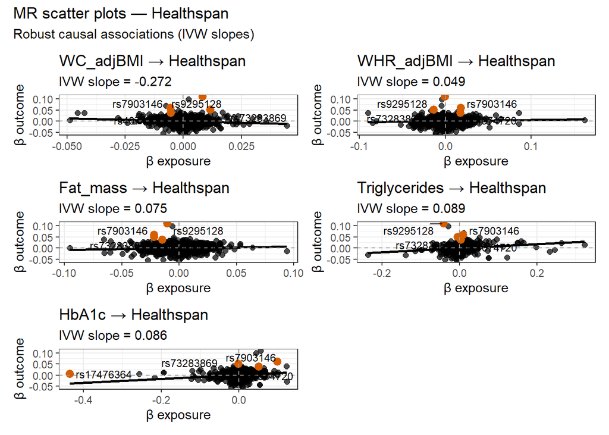

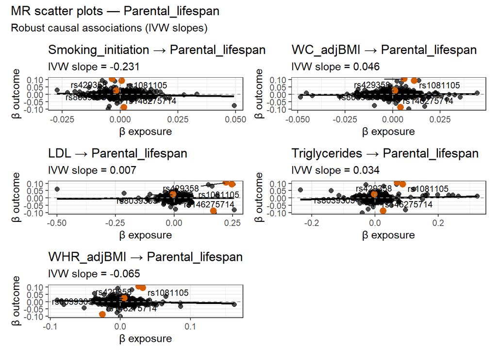

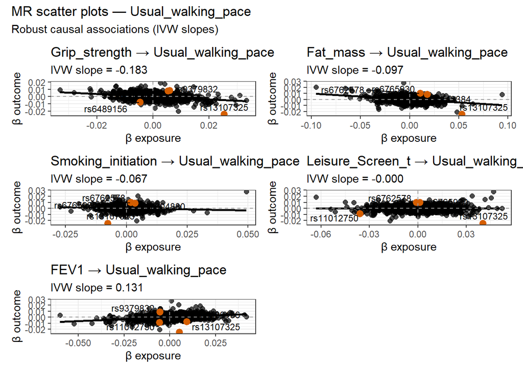

```r
dt <- bind_rows(dt_list)

#-------------------------------------------------
# IVW slope lookup (robust to naming)
#-------------------------------------------------

ivw_lookup <- mr_results %>%
  filter(grepl("IVW|variance weighted", method, ignore.case = TRUE)) %>%
  transmute(
    exposure,
    outcome,
    b_ivw = b
  )

min_snps <- 3
n_label  <- 4
use_repel <- requireNamespace("ggrepel", quietly = TRUE)

outcomes <- unique(top_pairs$outcome)

for (out in outcomes) {

  pairs_out <- top_pairs %>% filter(outcome == out)
  plot_list <- list()

  for (i in seq_len(nrow(pairs_out))) {

    exp <- pairs_out$exposure[i]

    df_exp <- dt %>% filter(trait == exp)
    df_out <- dt %>% filter(trait == out)

    scatter_df <- inner_join(
      df_exp, df_out,
      by = "SNP",
      suffix = c("_exp","_out")
    )

    if (nrow(scatter_df) < min_snps) next

    #---------------------------------------------
    # IVW slope (fallback to lm if missing)
    #---------------------------------------------

    b_ivw <- ivw_lookup %>%
      filter(exposure == exp, outcome == out) %>%
      pull(b_ivw)

    if (length(b_ivw) == 0 || is.na(b_ivw)) {
      b_ivw <- coef(lm(BETA_out ~ BETA_exp - 1, scatter_df))[1]
    }

    #---------------------------------------------
    # Influence diagnostics
    #---------------------------------------------

    scatter_df <- scatter_df %>%
      mutate(
        pred = b_ivw * BETA_exp,
        resid = BETA_out - pred,
        stud_resid = abs(resid / SE_out)
      ) %>%
      arrange(desc(stud_resid)) %>%
      mutate(label_me = row_number() <= n_label)

    x_rng <- range(scatter_df$BETA_exp, na.rm = TRUE)
    line_df <- data.frame(x = x_rng, y = b_ivw * x_rng)

    #---------------------------------------------
    # Build plot
    #---------------------------------------------

    p <- ggplot(scatter_df, aes(BETA_exp, BETA_out)) +

      geom_point(alpha = 0.7, size = 2) +

      geom_point(
        data = scatter_df %>% filter(label_me),
        color = "#D55E00",
        size = 2.8
      ) +

      geom_line(
        data = line_df,
        aes(x, y),
        linewidth = 1
      ) +

      geom_hline(yintercept = 0, linetype = "dashed", color = "grey60") +
      geom_vline(xintercept = 0, linetype = "dashed", color = "grey60") +

      labs(
        title = paste(exp, "→", out),
        subtitle = paste0("IVW slope = ", sprintf("%.3f", b_ivw)),
        x = "β exposure",
        y = "β outcome"
      ) +
      theme_bw(base_size = 11)

    if (n_label > 0) {

      lab_df <- scatter_df %>% filter(label_me)

      if (use_repel) {
        p <- p + ggrepel::geom_text_repel(
          data = lab_df,
          aes(label = SNP),
          size = 3
        )
      } else {
        p <- p + geom_text(
          data = lab_df,
          aes(label = SNP),
          size = 3,
          vjust = -0.6
        )
      }
    }

    plot_list[[length(plot_list) + 1]] <- p
  }

  #-------------------------------------------------
  # Save grid
  #-------------------------------------------------

  if (length(plot_list) == 0) next

  grid_plot <- wrap_plots(plot_list, ncol = 2) +
    plot_annotation(
      title = paste("MR scatter plots —", out),
      subtitle = "Robust causal associations (IVW slopes)"
    )

  print(grid_plot)

  ggsave(
    file.path(out_dir, paste0("Section_15.7_MR_Scatter_", out, ".png")),
    grid_plot,
    width = 10,
    height = 8,
    dpi = 300
  )
}
```

## 15.8 Detailed heterogeneity table

Cochran’s Q statistics are reported for each exposure–outcome pair to formally assess instrument heterogeneity and guide fixed- versus random-effects IVW modeling.

```r
#######################################################
# SECTION 15.8 — Detailed heterogeneity diagnostics
#######################################################

library(data.table)
library(dplyr)
library(knitr)
library(kableExtra)
library(ggplot2)



setDT(mr_results)

#----------------------------------------------------
# 1) Clean duplicated heterogeneity rows
#----------------------------------------------------

mr_het_clean <- unique(as.data.table(mr_het))

#----------------------------------------------------
# 2) Quantitative heterogeneity prevalence summary
#----------------------------------------------------

het_summary <- mr_het_clean[
  , .(
    total_pairs = .N,
    high_heterogeneity = sum(Q_pval < 0.05),
    percent_high = round(100 * mean(Q_pval < 0.05), 1)
  )
]

kbl(
  het_summary,
  caption = "Summary of heterogeneity prevalence across MR pairs"
) %>%
  kable_styling(full_width = FALSE)
```

Summary of heterogeneity prevalence across MR pairs

| total_pairs | high_heterogeneity | percent_high |
| --- | --- | --- |
| 146 | 114 | 78.1 |

```r
#----------------------------------------------------
# 3) Add heterogeneity flags + IVW model guidance
#----------------------------------------------------

mr_het_table <- mr_het_clean[
  , `:=`(
    heterogeneity_flag = ifelse(Q_pval < 0.05,
                                "⚠ High heterogeneity",
                                "Low heterogeneity"),
    ivw_model_recommended = ifelse(Q_pval < 0.05,
                                   "Random-effects IVW",
                                   "Fixed-effects IVW")
  )
][order(outcome, Q_pval)]

#----------------------------------------------------
# 4) Publication-ready Cochran’s Q table
#----------------------------------------------------

kbl(
  mr_het_table,
  digits = 4,
  caption = "Table S4. Cochran’s Q heterogeneity statistics with model guidance"
) %>%
  kable_styling(
    full_width = FALSE,
    bootstrap_options = c("striped", "hover", "condensed")
  ) %>%
  row_spec(
    which(mr_het_table$Q_pval < 0.05),
    background = "#FADBD8"
  ) %>%
  scroll_box(height = "450px", width = "100%")
```

Table S4. Cochran’s Q heterogeneity statistics with model guidance

| exposure | outcome | method | Q | Q_df | Q_pval | heterogeneity_flag | ivw_model_recommended |
| --- | --- | --- | --- | --- | --- | --- | --- |
| Fat_free_mass | Healthspan | MR Egger | 532.8065 | 326 | 0.0000 | ⚠ High heterogeneity | Random-effects IVW |
| Fat_free_mass | Healthspan | Inverse variance weighted | 532.8082 | 327 | 0.0000 | ⚠ High heterogeneity | Random-effects IVW |
| Triglycerides | Healthspan | Inverse variance weighted | 389.3829 | 221 | 0.0000 | ⚠ High heterogeneity | Random-effects IVW |
| Triglycerides | Healthspan | MR Egger | 381.6959 | 220 | 0.0000 | ⚠ High heterogeneity | Random-effects IVW |
| WHR_adjBMI | Healthspan | Inverse variance weighted | 478.2515 | 306 | 0.0000 | ⚠ High heterogeneity | Random-effects IVW |
| WC_adjBMI | Healthspan | Inverse variance weighted | 381.1364 | 230 | 0.0000 | ⚠ High heterogeneity | Random-effects IVW |
| WC_adjBMI | Healthspan | MR Egger | 379.7102 | 229 | 0.0000 | ⚠ High heterogeneity | Random-effects IVW |
| WHR_adjBMI | Healthspan | MR Egger | 474.5258 | 305 | 0.0000 | ⚠ High heterogeneity | Random-effects IVW |
| WBC | Healthspan | MR Egger | 425.5312 | 274 | 0.0000 | ⚠ High heterogeneity | Random-effects IVW |
| WBC | Healthspan | Inverse variance weighted | 426.5336 | 275 | 0.0000 | ⚠ High heterogeneity | Random-effects IVW |
| FEV1 | Healthspan | MR Egger | 345.8638 | 225 | 0.0000 | ⚠ High heterogeneity | Random-effects IVW |
| FEV1 | Healthspan | Inverse variance weighted | 345.8719 | 226 | 0.0000 | ⚠ High heterogeneity | Random-effects IVW |
| Fat_mass | Healthspan | MR Egger | 185.7554 | 113 | 0.0000 | ⚠ High heterogeneity | Random-effects IVW |
| Leisure_Screen_t | Healthspan | MR Egger | 104.4684 | 52 | 0.0000 | ⚠ High heterogeneity | Random-effects IVW |
| Fat_mass | Healthspan | Inverse variance weighted | 185.9748 | 114 | 0.0000 | ⚠ High heterogeneity | Random-effects IVW |
| Leisure_Screen_t | Healthspan | Inverse variance weighted | 104.7314 | 53 | 0.0000 | ⚠ High heterogeneity | Random-effects IVW |
| BMD | Healthspan | Inverse variance weighted | 451.6708 | 338 | 0.0000 | ⚠ High heterogeneity | Random-effects IVW |
| BMD | Healthspan | MR Egger | 447.3803 | 337 | 0.0001 | ⚠ High heterogeneity | Random-effects IVW |
| HDL | Healthspan | Inverse variance weighted | 384.4580 | 284 | 0.0001 | ⚠ High heterogeneity | Random-effects IVW |
| HDL | Healthspan | MR Egger | 379.8086 | 283 | 0.0001 | ⚠ High heterogeneity | Random-effects IVW |
| LDL | Healthspan | Inverse variance weighted | 325.1318 | 238 | 0.0001 | ⚠ High heterogeneity | Random-effects IVW |
| HbA1c | Healthspan | Inverse variance weighted | 346.5876 | 258 | 0.0002 | ⚠ High heterogeneity | Random-effects IVW |
| LDL | Healthspan | MR Egger | 320.2630 | 237 | 0.0003 | ⚠ High heterogeneity | Random-effects IVW |
| CRP | Healthspan | Inverse variance weighted | 183.9420 | 124 | 0.0004 | ⚠ High heterogeneity | Random-effects IVW |
| HbA1c | Healthspan | MR Egger | 327.8647 | 257 | 0.0018 | ⚠ High heterogeneity | Random-effects IVW |
| CRP | Healthspan | MR Egger | 173.2823 | 123 | 0.0019 | ⚠ High heterogeneity | Random-effects IVW |
| Sugar_intake | Healthspan | MR Egger | 34.7106 | 16 | 0.0044 | ⚠ High heterogeneity | Random-effects IVW |
| Sugar_intake | Healthspan | Inverse variance weighted | 34.7112 | 17 | 0.0068 | ⚠ High heterogeneity | Random-effects IVW |
| Chronotype | Healthspan | MR Egger | 150.9850 | 115 | 0.0137 | ⚠ High heterogeneity | Random-effects IVW |
| Chronotype | Healthspan | Inverse variance weighted | 151.2277 | 116 | 0.0155 | ⚠ High heterogeneity | Random-effects IVW |

[output cut: 116 more lines]

[figure not shown]

```r
#----------------------------------------------------
# 5) Heterogeneity vs causal effect size diagnostic plot
#----------------------------------------------------

ivw_eff <- mr_results[
  method == "Inverse variance weighted (multiplicative random effects)",
  .(exposure, outcome, b)
]

het_plot_df <- merge(
  mr_het_table,
  ivw_eff,
  by = c("exposure", "outcome"),
  all.x = TRUE
)

ggplot(
  het_plot_df,
  aes(x = abs(b), y = -log10(Q_pval))
) +
  geom_point(alpha = 0.7) +
  geom_hline(yintercept = -log10(0.05),
             linetype = "dashed",
             color = "red") +
  labs(
    x = "|IVW causal effect|",
    y = expression(-log[10](Q[p])),
    title = "Instrument heterogeneity versus causal effect magnitude",
    subtitle = "Dashed line indicates Cochran’s Q p = 0.05"
  ) +
  theme_bw(base_size = 12)
```

```r
#----------------------------------------------------
# 6) Auto-generated manuscript wording
#----------------------------------------------------

cat(
  "\nSuggested Results wording:\n",
  paste0(
    "Significant heterogeneity was observed across ",
    het_summary$percent_high,
    "% of exposure–outcome pairs (Cochran’s Q p < 0.05), ",
    "consistent with the polygenic architecture of the analyzed traits. ",
    "Accordingly, random-effects IVW models were applied as the primary causal estimates.\n"
  )
)
```

Suggested Results wording: Significant heterogeneity was observed across 78.1% of exposure–outcome pairs (Cochran’s Q p < 0.05), consistent with the polygenic architecture of the analyzed traits. Accordingly, random-effects IVW models were applied as the primary causal estimates.

```r
library(openxlsx)

out_dir <- "C:/Users/75118/Desktop/UEA/Proyecto 1/MainMRresults"
dir.create(out_dir, showWarnings = FALSE, recursive = TRUE)

het_excel <- file.path(
  out_dir,
  "Section_15.8_Heterogeneity_Table.xlsx"
)

wb <- createWorkbook()

# ==============================
# Sheet 1 — Full heterogeneity table
# ==============================

addWorksheet(wb, "Heterogeneity_Table")

writeData(
  wb,
  "Heterogeneity_Table",
  mr_het_table,
  withFilter = TRUE
)

setColWidths(
  wb,
  "Heterogeneity_Table",
  cols = 1:ncol(mr_het_table),
  widths = "auto"
)

# Highlight high heterogeneity

warn_style <- createStyle(fgFill = "#FADBD8")

rows_warn <- which(mr_het_table$Q_pval < 0.05) + 1

if (length(rows_warn) > 0) {
  addStyle(
    wb,
    "Heterogeneity_Table",
    warn_style,
    rows = rows_warn,
    cols = 1:ncol(mr_het_table),
    gridExpand = TRUE,
    stack = TRUE
  )
}

# ==============================
# Sheet 2 — Summary
# ==============================

addWorksheet(wb, "Summary")

writeData(
  wb,
  "Summary",
  het_summary
)

setColWidths(
  wb,
  "Summary",
  cols = 1:ncol(het_summary),
  widths = "auto"
)

# ==============================
# Save ONCE at the end
# ==============================

saveWorkbook(wb, het_excel, overwrite = TRUE)

cat("📊 Excel file saved with both sheets:\n", het_excel, "\n")
```

📊 Excel file saved with both sheets: C:/Users/75118/Desktop/UEA/Proyecto 1/MainMRresults/Section_15.8_Heterogeneity_Table.xlsx

## 15.9 MR-PRESSO outlier detail table

MR-PRESSO global tests, outlier counts, and distortion metrics are presented to identify influential variants and evaluate the robustness of causal estimates after outlier correction.

```r
#############################
# SECTION 15.9 — MR-PRESSO diagnostics
#############################

library(dplyr)
library(knitr)
library(kableExtra)
library(openxlsx)

out_dir <- "C:/Users/75118/Desktop/UEA/Proyecto 1/MainMRresults"
dir.create(out_dir, showWarnings = FALSE, recursive = TRUE)

#--------------------------------------------------
# Clean + interpret MR-PRESSO output
#--------------------------------------------------

mr_presso_clean <- mr_presso %>%
  distinct() %>%
  mutate(
    pleiotropy_flag = ifelse(
      presso_global_p < 0.05,
      "⚠ Pleiotropy detected",
      "OK"
    ),
    distortion_flag = ifelse(
      presso_distortion_p < 0.05,
      "⚠ Effect changed",
      "No distortion"
    )
  ) %>%
  arrange(presso_global_p)

#--------------------------------------------------
# Display in report (paper-ready)
#--------------------------------------------------

kbl(
  mr_presso_clean,
  digits = 4,
  caption = "Table S5. MR-PRESSO global pleiotropy and distortion tests with interpretation"
) %>%
  kable_styling(
    full_width = FALSE,
    bootstrap_options = c("striped", "hover", "condensed")
  ) %>%
  row_spec(
    which(mr_presso_clean$presso_global_p < 0.05),
    background = "#FADBD8"
  ) %>%
  scroll_box(height = "450px", width = "100%")
```

Table S5. MR-PRESSO global pleiotropy and distortion tests with interpretation

| exposure | outcome | presso_ran | presso_global_p | presso_n_outliers | presso_distortion_p | pleiotropy_flag | distortion_flag |
| --- | --- | --- | --- | --- | --- | --- | --- |
| BMD | Parental_lifespan | TRUE | 0.001 | 340 | NA | ⚠ Pleiotropy detected | NA |
| Sugar_intake | Parental_lifespan | TRUE | 0.001 | 18 | 0.604 | ⚠ Pleiotropy detected | No distortion |
| Chronotype | Parental_lifespan | TRUE | 0.003 | 112 | 0.861 | ⚠ Pleiotropy detected | No distortion |
| Acc_total_log | Usual_walking_pace | TRUE | 0.004 | 5 | 1.000 | ⚠ Pleiotropy detected | No distortion |
| Self_MVPA | Usual_walking_pace | TRUE | 0.005 | 12 | 0.546 | ⚠ Pleiotropy detected | No distortion |
| Fat_mass | Parental_lifespan | TRUE | 0.006 | 111 | 0.699 | ⚠ Pleiotropy detected | No distortion |
| Sugar_intake | Healthspan | TRUE | 0.007 | 18 | NA | ⚠ Pleiotropy detected | NA |
| Chronotype | Healthspan | TRUE | 0.011 | 117 | 0.829 | ⚠ Pleiotropy detected | No distortion |
| Walking_days | Parental_lifespan | TRUE | 0.012 | 11 | 0.746 | ⚠ Pleiotropy detected | No distortion |
| Acc_relative_amplitude | Usual_walking_pace | FALSE | NA | NA | NA | NA | NA |
| Acc_relative_amplitude | Parental_lifespan | FALSE | NA | NA | NA | NA | NA |
| Acc_relative_amplitude | Healthspan | FALSE | NA | NA | NA | NA | NA |
| Acc_total_log | Parental_lifespan | FALSE | NA | NA | NA | NA | NA |
| Acc_total_log | Healthspan | FALSE | NA | NA | NA | NA | NA |
| BMD | Usual_walking_pace | TRUE | NA | 345 | 0.788 | NA | No distortion |
| BMD | Healthspan | TRUE | NA | 339 | 0.945 | NA | No distortion |
| Chronotype | Usual_walking_pace | TRUE | NA | 117 | 0.449 | NA | No distortion |
| CRF_slope | Usual_walking_pace | FALSE | NA | NA | NA | NA | NA |
| CRF_slope | Parental_lifespan | FALSE | NA | NA | NA | NA | NA |
| CRF_slope | Healthspan | FALSE | NA | NA | NA | NA | NA |
| CRP | Usual_walking_pace | TRUE | NA | 125 | 0.123 | NA | No distortion |
| CRP | Parental_lifespan | TRUE | NA | 123 | 0.953 | NA | No distortion |
| CRP | Healthspan | TRUE | NA | 125 | 0.872 | NA | No distortion |
| Fat_free_mass | Usual_walking_pace | TRUE | NA | 369 | 0.038 | NA | ⚠ Effect changed |
| Fat_free_mass | Parental_lifespan | TRUE | NA | 324 | 0.933 | NA | No distortion |
| Fat_free_mass | Healthspan | TRUE | NA | 328 | 0.875 | NA | No distortion |
| Fat_mass | Usual_walking_pace | TRUE | NA | 134 | 0.253 | NA | No distortion |
| Fat_mass | Healthspan | TRUE | NA | 115 | 0.857 | NA | No distortion |
| FEV1 | Usual_walking_pace | TRUE | NA | 252 | 0.805 | NA | No distortion |
| FEV1 | Parental_lifespan | TRUE | NA | 222 | 0.644 | NA | No distortion |
| FEV1 | Healthspan | TRUE | NA | 227 | 0.739 | NA | No distortion |
| Grip_strength | Usual_walking_pace | TRUE | NA | 144 | 0.699 | NA | No distortion |
| Grip_strength | Parental_lifespan | TRUE | NA | 127 | 0.856 | NA | No distortion |
| HbA1c | Usual_walking_pace | TRUE | NA | 299 | 0.907 | NA | No distortion |
| HbA1c | Parental_lifespan | TRUE | NA | 255 | 0.757 | NA | No distortion |
| HbA1c | Healthspan | TRUE | NA | 259 | 0.929 | NA | No distortion |
| HDL | Usual_walking_pace | TRUE | NA | 299 | 0.242 | NA | No distortion |
| HDL | Parental_lifespan | TRUE | NA | 280 | 0.965 | NA | No distortion |
| HDL | Healthspan | TRUE | NA | 285 | 0.935 | NA | No distortion |
| LDL | Usual_walking_pace | TRUE | NA | 248 | 0.865 | NA | No distortion |
| LDL | Parental_lifespan | TRUE | NA | 231 | 0.754 | NA | No distortion |
| LDL | Healthspan | TRUE | NA | 239 | 0.824 | NA | No distortion |
| Leisure_Screen_t | Usual_walking_pace | TRUE | NA | 60 | 0.700 | NA | No distortion |
| Leisure_Screen_t | Parental_lifespan | TRUE | NA | 54 | NA | NA | NA |
| Leisure_Screen_t | Healthspan | TRUE | NA | 54 | 0.650 | NA | No distortion |
| Resting_heart_rate | Usual_walking_pace | TRUE | NA | 19 | 0.527 | NA | No distortion |
| Self_MVPA | Parental_lifespan | TRUE | NA | 11 | 0.493 | NA | No distortion |
| Smoking_initiation | Usual_walking_pace | TRUE | NA | 42 | 0.637 | NA | No distortion |
| Smoking_initiation | Parental_lifespan | TRUE | NA | 44 | NA | NA | NA |
| Sugar_intake | Usual_walking_pace | TRUE | NA | 19 | 0.527 | NA | No distortion |
| Triglycerides | Usual_walking_pace | TRUE | NA | 230 | 0.687 | NA | No distortion |
| Triglycerides | Parental_lifespan | TRUE | NA | 220 | 0.986 | NA | No distortion |
| Triglycerides | Healthspan | TRUE | NA | 222 | 0.670 | NA | No distortion |
| Walking_time | Usual_walking_pace | FALSE | NA | NA | NA | NA | NA |
| WBC | Usual_walking_pace | TRUE | NA | 308 | 0.585 | NA | No distortion |
| WBC | Parental_lifespan | TRUE | NA | 272 | 0.826 | NA | No distortion |
| WBC | Healthspan | TRUE | NA | 276 | 0.782 | NA | No distortion |
| WC_adjBMI | Usual_walking_pace | TRUE | NA | 250 | 0.606 | NA | No distortion |
| WC_adjBMI | Parental_lifespan | TRUE | NA | 230 | 0.847 | NA | No distortion |
| WC_adjBMI | Healthspan | TRUE | NA | 231 | 0.826 | NA | No distortion |
| WHR_adjBMI | Usual_walking_pace | TRUE | NA | 303 | 0.806 | NA | No distortion |
| WHR_adjBMI | Parental_lifespan | TRUE | NA | 304 | 0.865 | NA | No distortion |
| WHR_adjBMI | Healthspan | TRUE | NA | 307 | 0.845 | NA | No distortion |

```r
#--------------------------------------------------
# Quantitative summary
#--------------------------------------------------

presso_summary <- mr_presso_clean %>%
  summarise(
    total_pairs = n(),
    pleiotropy_detected = sum(presso_global_p < 0.05),
    distortion_cases = sum(presso_distortion_p < 0.05),
    percent_pleiotropy = round(100 * mean(presso_global_p < 0.05), 1),
    total_outliers = sum(presso_n_outliers, na.rm = TRUE)
  )

kbl(
  presso_summary,
  caption = "Summary of MR-PRESSO pleiotropy prevalence and outlier burden"
) %>%
  kable_styling(full_width = FALSE)
```

Summary of MR-PRESSO pleiotropy prevalence and outlier burden

| total_pairs | pleiotropy_detected | distortion_cases | percent_pleiotropy | total_outliers |
| --- | --- | --- | --- | --- |
| 63 | NA | NA | NA | 10011 |

```r
#--------------------------------------------------
# Excel export (supplement-ready)
#--------------------------------------------------

presso_excel <- file.path(
  out_dir,
  "Section_15.9_MR_PRESSO_Diagnostics.xlsx"
)

wb <- createWorkbook()

# ---- Sheet 1: Full diagnostics ----
addWorksheet(wb, "PRESSO_Table")

writeData(
  wb,
  "PRESSO_Table",
  mr_presso_clean,
  withFilter = TRUE
)

setColWidths(
  wb,
  "PRESSO_Table",
  cols = 1:ncol(mr_presso_clean),
  widths = "auto"
)

# Highlight pleiotropy rows
warn_style <- createStyle(fgFill = "#FADBD8")

rows_warn <- which(mr_presso_clean$presso_global_p < 0.05) + 1

if (length(rows_warn) > 0) {
  addStyle(
    wb,
    "PRESSO_Table",
    warn_style,
    rows = rows_warn,
    cols = 1:ncol(mr_presso_clean),
    gridExpand = TRUE,
    stack = TRUE
  )
}

# ---- Sheet 2: Summary ----
addWorksheet(wb, "Summary")

writeData(
  wb,
  "Summary",
  presso_summary
)

setColWidths(
  wb,
  "Summary",
  cols = 1:ncol(presso_summary),
  widths = "auto"
)

# ---- Save once ----
saveWorkbook(wb, presso_excel, overwrite = TRUE)

cat("📊 MR-PRESSO Excel diagnostics saved at:\n", presso_excel, "\n")
```

📊 MR-PRESSO Excel diagnostics saved at: C:/Users/75118/Desktop/UEA/Proyecto 1/MainMRresults/Section_15.9_MR_PRESSO_Diagnostics.xlsx

```r
#--------------------------------------------------
# Auto manuscript wording
#--------------------------------------------------

cat(
  "\nSuggested Results wording:\n",
  paste0(
    "MR-PRESSO identified horizontal pleiotropy in ",
    presso_summary$percent_pleiotropy,
    "% of exposure–outcome associations, with a total of ",
    presso_summary$total_outliers,
    " outlier variants detected. Distortion of causal estimates following outlier correction occurred in ",
    presso_summary$distortion_cases,
    " associations.\n"
  )
)
```

[output not shown]

```r
#--------------------------------------------------
# Compact MR-PRESSO summary by outcome
#--------------------------------------------------

presso_summary_outcome <- mr_presso_clean %>%
  group_by(outcome) %>%
  summarise(
    total_pairs = n(),
    pleiotropy_cases = sum(presso_global_p < 0.05, na.rm = TRUE),
    percent = round(100 * pleiotropy_cases / total_pairs, 1),
    distortion_cases = sum(presso_distortion_p < 0.05, na.rm = TRUE)
  ) %>%
  arrange(desc(percent))

kbl(
  presso_summary_outcome,
  caption = "Summary of MR-PRESSO pleiotropy and distortion by outcome"
) %>%
  kable_styling(full_width = FALSE)
```

Summary of MR-PRESSO pleiotropy and distortion by outcome

| outcome | total_pairs | pleiotropy_cases | percent | distortion_cases |
| --- | --- | --- | --- | --- |
| Parental_lifespan | 22 | 5 | 22.7 | 0 |
| Healthspan | 18 | 2 | 11.1 | 0 |
| Usual_walking_pace | 23 | 2 | 8.7 | 1 |

```r
rm(gwas_mr, dt)
gc(TRUE)
```

```
        used   (Mb) gc trigger   (Mb)   max used    (Mb)
```

Ncells 58736472 3136.9 163420670 8727.7 122412576 6537.6 Vcells 482580141 3681.8 1063414618 8113.3 2816754386 21490.2

## 15.10 Mode-based Mendelian Randomization robustness analyses - Weighted mode MR and Simple mode MR forest plots

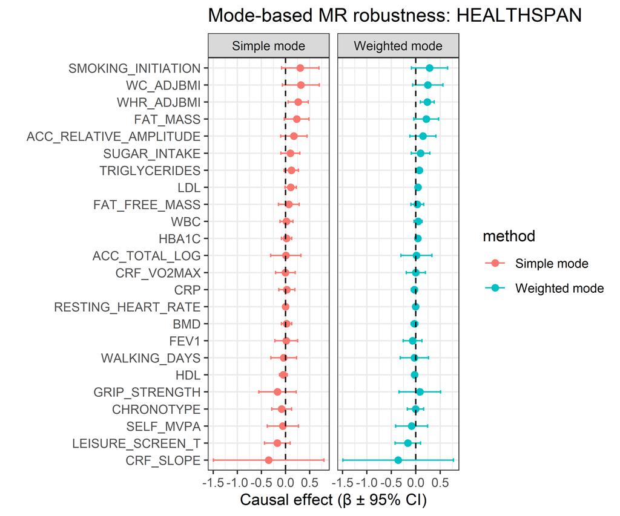

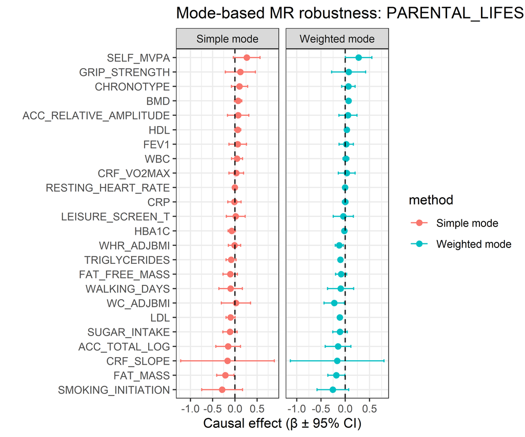

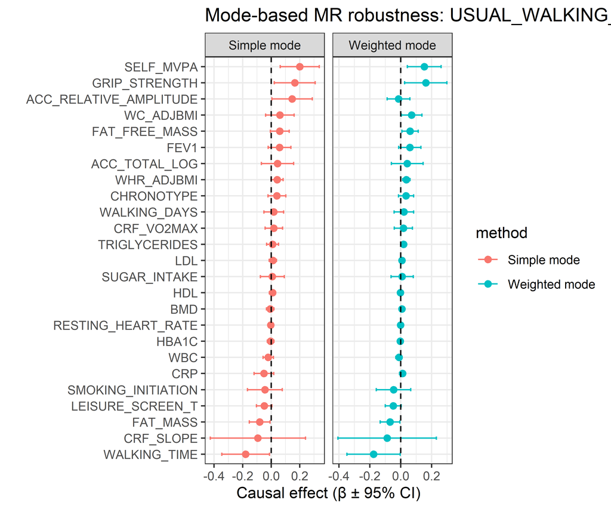

```r
library(dplyr)
library(ggplot2)

#------------------------------------------------------------
# Extract mode-based MR results
#------------------------------------------------------------

mode_mr <- mr_results %>%
  filter(method %in% c("Weighted mode", "Simple mode")) %>%
  mutate(
    ci_low  = b - 1.96 * se,
    ci_high = b + 1.96 * se
  )

#------------------------------------------------------------
# Plot function per outcome
#------------------------------------------------------------

plot_mode_forest <- function(out) {

  df <- mode_mr %>% filter(outcome == out)

  if (nrow(df) < 3) return(NULL)

  ggplot(df,
         aes(
           x = b,
           y = reorder(exposure, b),
           color = method
         )) +
    geom_point(position = position_dodge(width = 0.5), size = 2) +
    geom_errorbarh(
      aes(xmin = ci_low, xmax = ci_high),
      height = 0.2,
      position = position_dodge(width = 0.5)
    ) +
    geom_vline(xintercept = 0, linetype = "dashed") +
    facet_wrap(~ method, scales = "free_x") +
    labs(
      x = "Causal effect (β ± 95% CI)",
      y = "",
      title = paste("Mode-based MR robustness:", out)
    ) +
    theme_bw()
}

#------------------------------------------------------------
# Render plots for all outcomes
#------------------------------------------------------------

outcomes <- unique(mode_mr$outcome)

for (out in outcomes) {
  p <- plot_mode_forest(out)
  if (!is.null(p)) print(p)
}
```

## 15.11 Cross-estimator robustness and concordance across Mendelian Randomization methods

To evaluate consistency of causal inference across complementary MR estimators, effect sizes derived from IVW, weighted median, weighted mode, and simple mode methods were jointly compared. Integrated visualizations assess agreement in magnitude, directionality, and statistical stability across exposure–outcome relationships, providing a comprehensive robustness framework against pleiotropy and instrument invalidity.

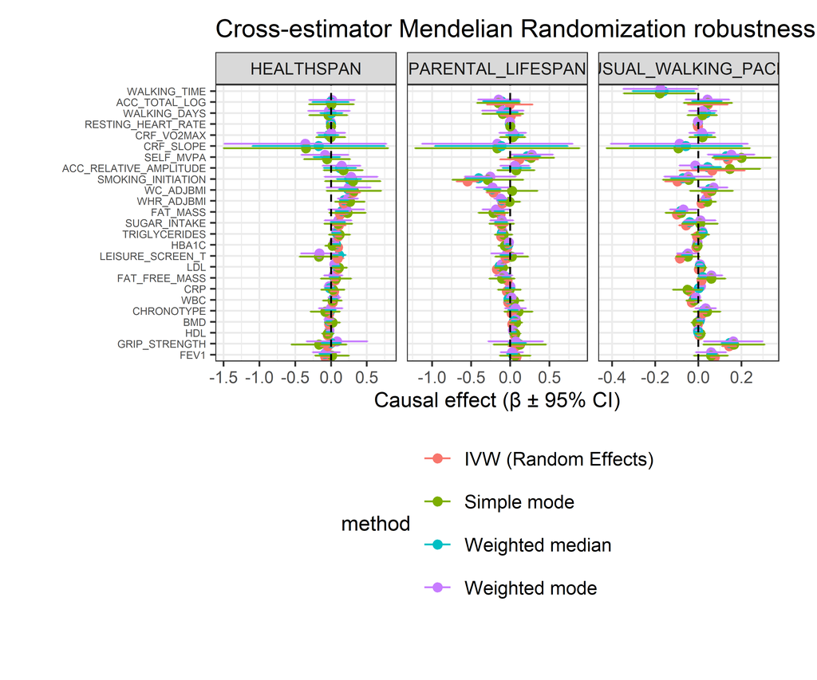

```r
############################################################
# SECTION 15.11 — Cross-estimator robustness (FIXED)
############################################################

library(dplyr)
library(ggplot2)
library(stringr)

#------------------------------------------------------------
# Prepare combined MR estimates (robust methods only)
#------------------------------------------------------------
robust_mr <- mr_results %>%
  filter(method %in% c(
    "Inverse variance weighted (multiplicative random effects)",
    "Weighted median",
    "Weighted mode",
    "Simple mode"
  )) %>%
  mutate(
    ci_low  = b - 1.96 * se,
    ci_high = b + 1.96 * se,
    method = recode(method,
      "Inverse variance weighted (multiplicative random effects)" = "IVW (Random Effects)",
      "Weighted median" = "Weighted median",
      "Weighted mode"   = "Weighted mode",
      "Simple mode"     = "Simple mode"
    ),
    outcome = recode(outcome,
      "Parental_lifespan"  = "Parental lifespan",
      "Usual_walking_pace" = "Usual walking pace"
    )
  )

#------------------------------------------------------------
# Robust IVW-based ordering per outcome (NO NA POSSIBLE)
#------------------------------------------------------------
robust_mr2 <- robust_mr %>%
  group_by(outcome) %>%
  mutate(
    ivw_effect = b[method == "IVW (Random Effects)"][
      match(exposure,
            exposure[method == "IVW (Random Effects)"])
    ]
  ) %>%
  arrange(outcome, ivw_effect) %>%
  mutate(
    exposure_plot = factor(exposure, levels = unique(exposure))
  ) %>%
  ungroup()

#------------------------------------------------------------
# Combined cross-estimator forest plot
#------------------------------------------------------------
ggplot(robust_mr2,
       aes(x = b,
           y = exposure_plot,
           color = method)) +
  geom_point(position = position_dodge(0.6), size = 2) +
  geom_errorbarh(
    aes(xmin = ci_low, xmax = ci_high),
    height = 0.2,
    position = position_dodge(0.6)
  ) +
  geom_vline(xintercept = 0, linetype = "dashed") +
  facet_wrap(~ outcome, scales = "free_x") +
  labs(
    x = "Causal effect (β ± 95% CI)",
    y = "",
    title = "Cross-estimator Mendelian Randomization robustness"
  ) +
  scale_color_discrete(labels = \(x) str_wrap(x, 35)) +
  theme_bw() +
  theme(
    legend.position = "bottom",
    legend.box = "vertical",
    legend.text = element_text(size = 10),
    axis.text.y = element_text(size = 5.5),
    plot.margin = margin(10, 20, 35, 20)
  ) +
  guides(color = guide_legend(ncol = 1, byrow = TRUE))
```

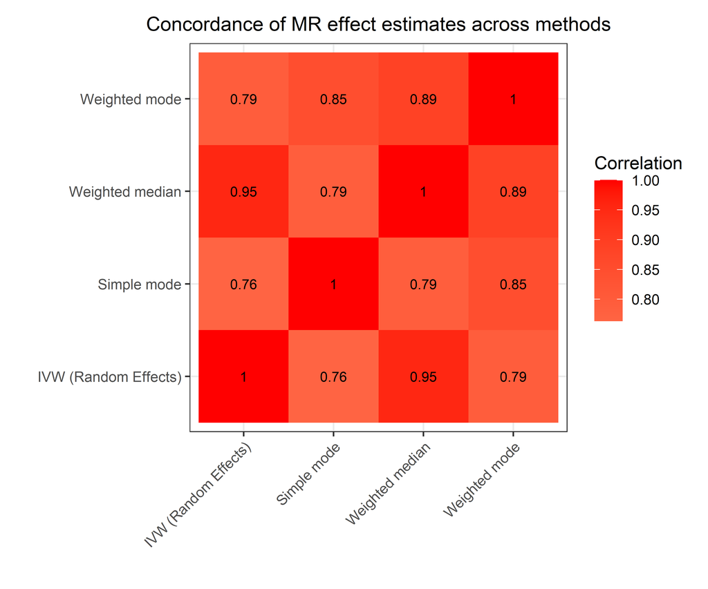

```r
#============================================================
# 15.11.2 Concordance heatmap (method correlation)
#============================================================
mr_wide <- dcast(
  as.data.table(robust_mr),
  exposure + outcome ~ method,
  value.var = "b"
)

mr_corr <- mr_wide[, !c("exposure", "outcome")] |> na.omit()
corr_mat <- cor(mr_corr)

corr_df <- as.data.frame(as.table(corr_mat))
names(corr_df) <- c("Method1", "Method2", "Correlation")

ggplot(corr_df, aes(Method1, Method2, fill = Correlation)) +
  geom_tile() +
  geom_text(aes(label = round(Correlation, 2)), color = "black", size = 3) +
  scale_fill_gradient2(low = "blue", mid = "white", high = "red", midpoint = 0) +
  theme_bw() +
  labs(
    title = "Concordance of MR effect estimates across methods",
    x = "",
    y = ""
  ) +
  theme(
    axis.text.x = element_text(angle = 45, hjust = 1),
    plot.title  = element_text(size = 12, hjust = 0.5),
    plot.margin = margin(10, 10, 10, 10)
  )
```

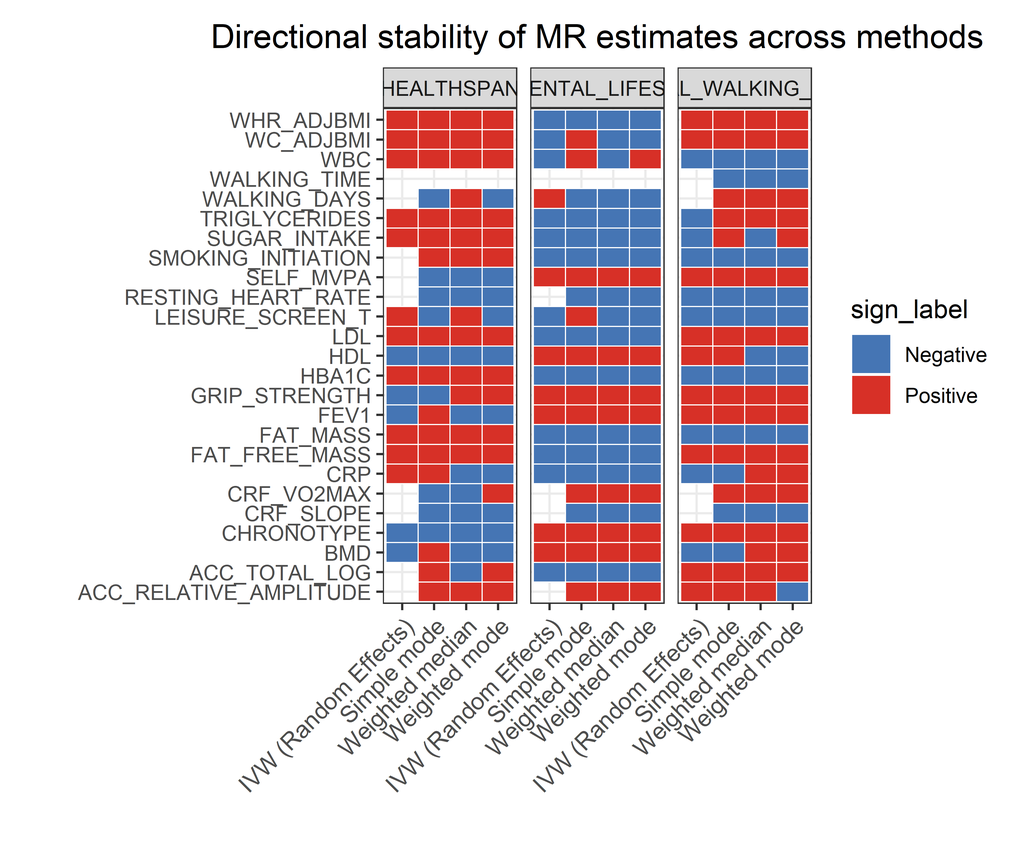

```r
#============================================================
# 15.11.3 Directional stability heatmap (sign agreement)
#============================================================
sign_long <- robust_mr %>%
  mutate(sign_label = ifelse(b > 0, "Positive", "Negative")) %>%
  dplyr::select(exposure, outcome, method, sign_label)


ggplot(sign_long, aes(method, exposure, fill = sign_label)) +
  geom_tile(color = "white", linewidth = 0.25) +
  facet_wrap(~ outcome, nrow = 1) +
  scale_fill_manual(values = c("Positive" = "#D73027", "Negative" = "#4575B4")) +
  labs(
    title = "Directional stability of MR estimates across methods",
    x = "",
    y = ""
  ) +
  theme_bw() +
  theme(
    axis.text.x = element_text(angle = 45, hjust = 1, size = 10),
    axis.text.y = element_text(size = 9),
    plot.title  = element_text(size = 14, hjust = 0.5),
    plot.margin = margin(t = 10, r = 10, b = 10, l = 20)
  )
```

## 15.12 Colocalization analysis of shared causal variants between exposures and aging outcomes

Colocalization analyses were conducted to distinguish true shared causal variants from linkage disequilibrium–driven associations by evaluating regional SNP signals for exposures and outcomes using Bayesian posterior probabilities.

```r
############################################################
# 15.12 COLOCALIZATION OF EXPOSURE–OUTCOME LOCI
############################################################

library(coloc)
library(dplyr)
library(data.table)
library(knitr)
library(kableExtra)
library(DT)

#------------------------------------------------------------
# Sample sizes per trait (USED BY COLOC) — UPDATED
#------------------------------------------------------------

sample_sizes <- c(

  #==========================================================
  # Primary PA
  #==========================================================
  Self_MVPA = 608595,

  #==========================================================
  # Cardiorespiratory / Metabolic Predictors
  #==========================================================
  CRF_slope = 70783,
  CRF_VO2max = 70783,
  Chronotype = 449734,
  CRP = 575531,
  HbA1c = 400825,
  Grip_strength = 404112,
  HDL = 1320016,
  LDL = 1320016,
  Triglycerides = 1320016,
  WBC = 416522,
  VAT = 32860,
  Fat_mass = 412524,
  Fat_free_mass = 413158,
  BMD = 426824,

  #==========================================================
  # Newly Added Traits
  #==========================================================
  Resting_heart_rate = 458969,
  FEV1 = 383471,
  WHR_adjBMI = 694649,
  WC_adjBMI = 365499,
  Smoking_initiation = 1232091,
  Sugar_intake = 454499,

  #==========================================================
  # Device-Based Accelerometry
  #==========================================================
  Acc_total_log = 88411,
  Acc_LIPA = 88411,
  Acc_MVPA = 88411,
  Acc_L5_inactivity = 88411,
  Acc_relative_amplitude = 88411,

  #==========================================================
  # Self-Reported PA / Walking
  #==========================================================
  Leisure_Screen_t = 526725,
  Walking_time = 394642,
  Walking_days = 413244,

  #==========================================================
  # Aging Outcomes
  #==========================================================
  Healthspan = 300447,
  Parental_lifespan = 500193,
  Usual_walking_pace = 417933
)

#------------------------------------------------------------
# Significant MR pairs
#------------------------------------------------------------

sig_pairs <- mr_results %>%
  dplyr::filter(
    method == "Inverse variance weighted (multiplicative random effects)",
    p < 0.05
  ) %>%
  dplyr::select(exposure, outcome) %>%
  dplyr::distinct()

#------------------------------------------------------------
# SNP → position lookup
#------------------------------------------------------------

pa_ref_file <- files_accel[1]

pa_lookup <- fread(
  pa_ref_file,
  select = c("variant_id","chromosome","base_pair_location"),
  showProgress = FALSE
) %>%
  rename(
    SNP = variant_id,
    chr = chromosome,
    pos = base_pair_location
  ) %>%
  distinct()

#------------------------------------------------------------
# Helper
#------------------------------------------------------------

to_maf <- function(eaf) pmin(eaf, 1 - eaf)

#------------------------------------------------------------
# Coloc per pair
#------------------------------------------------------------

run_coloc_pair <- function(exp_trait, out_trait, window_bp = 500000) {

  if (is.null(sample_sizes[[exp_trait]]) ||
      is.null(sample_sizes[[out_trait]])) return(NULL)

  # 🔥 Load exposure and outcome separately (no gwas_mr)

  mapped_dir <- "C:/Users/75118/Desktop/UEA/Proyecto 1/mapped_full_traits"

  exp_df <- readRDS(file.path(mapped_dir, paste0("mapped_full_", exp_trait, ".rds")))
  out_df <- readRDS(file.path(mapped_dir, paste0("mapped_full_", out_trait, ".rds")))

  exp_df$trait <- exp_trait
  out_df$trait <- out_trait

  merged <- inner_join(
    exp_df, out_df,
    by = "SNP",
    suffix = c("_exp","_out")
  ) %>%
    inner_join(pa_lookup, by = "SNP") %>%
    filter(!is.na(EAF_exp), !is.na(EAF_out))

  if (nrow(merged) < 200) return(NULL)

  merged <- merged %>%
    mutate(p_exp = 2 * pnorm(-abs(BETA_exp / SE_exp)))

  lead_snps <- merged %>%
    arrange(p_exp) %>%
    slice_head(n = 5) %>%
    pull(SNP)

  out <- list()

  for (lead in lead_snps) {

    center <- merged %>% filter(SNP == lead)
    if (nrow(center) == 0) next

    chr0 <- center$chr[1]
    pos0 <- center$pos[1]

    region <- merged %>%
      filter(chr == chr0, abs(pos - pos0) <= window_bp)

    if (nrow(region) < 100) next

    dataset1 <- list(
      snp     = region$SNP,
      beta    = region$BETA_exp,
      varbeta = region$SE_exp^2,
      MAF     = to_maf(region$EAF_exp),
      N       = sample_sizes[[exp_trait]],
      type    = "quant"
    )

    dataset2 <- list(
      snp     = region$SNP,
      beta    = region$BETA_out,
      varbeta = region$SE_out^2,
      MAF     = to_maf(region$EAF_out),
      N       = sample_sizes[[out_trait]],
      type    = "quant"
    )

    coloc_res <- suppressMessages(
      suppressWarnings(
        tryCatch(
          coloc.abf(dataset1, dataset2),
          error = function(e) NULL
        )
      )
    )

    if (is.null(coloc_res)) next

    out[[lead]] <- data.frame(
      exposure = exp_trait,
      outcome  = out_trait,
      lead_snp = lead,
      chr = chr0,
      center_pos = pos0,
      nsnps_region = nrow(region),
      PP.H0 = coloc_res$summary["PP.H0.abf"],
      PP.H1 = coloc_res$summary["PP.H1.abf"],
      PP.H2 = coloc_res$summary["PP.H2.abf"],
      PP.H3 = coloc_res$summary["PP.H3.abf"],
      PP.H4 = coloc_res$summary["PP.H4.abf"],
      stringsAsFactors = FALSE
    )
  }

  rm(exp_df, out_df, merged)
  gc(FALSE)

  bind_rows(out)
}

#------------------------------------------------------------
# Run across all MR-significant pairs
#------------------------------------------------------------

coloc_results <- bind_rows(
  lapply(seq_len(nrow(sig_pairs)), function(i) {
    run_coloc_pair(
      sig_pairs$exposure[i],
      sig_pairs$outcome[i]
    )
  })
)

coloc_results <- coloc_results %>%
  mutate(PP.H4_percent = round(100 * PP.H4, 2))


#------------------------------------------------------------
# Save results
#------------------------------------------------------------

saveRDS(coloc_results, "coloc_results_paperstyle.rds")
```

```r
coloc_results <- readRDS(
  "C:/Users/75118/Desktop/UEA/Proyecto 1/coloc_results_paperstyle.rds"
)


#------------------------------------------------------------
# 🔥 SCROLLABLE INTERACTIVE TABLE
#------------------------------------------------------------

library(DT)

datatable(
  coloc_results,
  extensions = c("Scroller"),
  options = list(
    deferRender = TRUE,
    scrollY = 400,
    scrollX = TRUE,
    scroller = TRUE,
    pageLength = 25
  ),
  rownames = FALSE
)
```

| exposure | outcome | lead_snp | chr | center_pos | nsnps_region | PP.H0 | PP.H1 | PP.H2 | PP.H3 | PP.H4 | PP.H4_percent |
| --- | --- | --- | --- | --- | --- | --- | --- | --- | --- | --- | --- |
| LDL | Healthspan | rs12747477 | 1 | 55448248 | 4885 | 0 | 0.6632050290616794 | 0 | 0.05849957721997033 | 0.2782953937183198 | 27.83 |
| LDL | Healthspan | rs12117661 | 1 | 55487346 | 4885 | 0 | 0.6619564363673028 | 0 | 0.0601859667636941 | 0.2778575968690044 | 27.79 |
| LDL | Healthspan | rs34232196 | 1 | 55489542 | 4897 | 0 | 0.6619725979384553 | 0 | 0.06016112471812985 | 0.2778662773434563 | 27.79 |
| LDL | Healthspan | rs11591147 | 1 | 55505647 | 4927 | 0 | 0.6622737755359847 | 0 | 0.05971812865046394 | 0.2780080958134549 | 27.8 |
| LDL | Healthspan | rs693668 | 1 | 55521109 | 4915 | 0 | 0.6620574105403358 | 0 | 0.05999349900570666 | 0.2779490904539157 | 27.79 |
| Fat_mass | Healthspan | rs11642015 | 16 | 53802494 | 3907 | 6.640957301052224e-239 | 0.9096043633886802 | 5.918159651371854e-240 | 0.08105101457144352 | 0.009344622039822054 | 0.93 |
| Fat_mass | Healthspan | rs62048402 | 16 | 53803223 | 3907 | 6.640987009139817e-239 | 0.9096080908374002 | 5.91788748547122e-240 | 0.08104725627165105 | 0.009344652890976798 | 0.93 |
| Fat_mass | Healthspan | rs1558902 | 16 | 53803574 | 3909 | 6.640851193729291e-239 | 0.9095894360200794 | 5.91926395583785e-240 | 0.08106610515113417 | 0.00934445882874676 | 0.93 |
| Fat_mass | Healthspan | rs56094641 | 16 | 53806453 | 3903 | 6.639314262212436e-239 | 0.9093747214284302 | 5.935127816912617e-240 | 0.08128301703925687 | 0.009342261532350973 | 0.93 |
| Fat_mass | Healthspan | rs55872725 | 16 | 53809123 | 3902 | 6.639121586333002e-239 | 0.9093472559532663 | 5.937160171996253e-240 | 0.08131075797524664 | 0.009341986071474021 | 0.93 |

[output cut: 89 more lines]

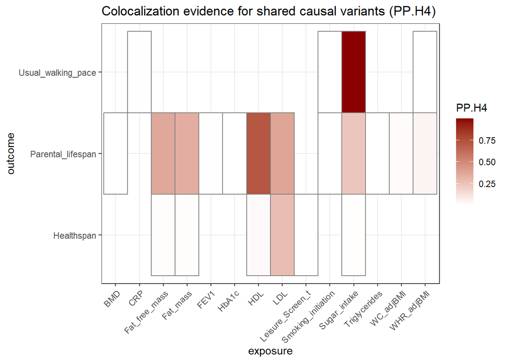

```r
############################################################
# 15.12.X Colocalization visualization & interpretation
############################################################

library(dplyr)
library(tidyr)
library(ggplot2)

coloc_clean <- coloc_results %>%
  mutate(
    strong_coloc = PP.H4 >= 0.7,
    very_strong_coloc = PP.H4 >= 0.9
  )

#============================================================
# FIGURE A — PP.H4 heatmap (strongest locus per pair)
#============================================================

pp4_matrix <- coloc_clean %>%
  group_by(exposure, outcome) %>%
  summarise(
    max_PP4 = max(PP.H4, na.rm = TRUE),
    .groups = "drop"
  )

ggplot(pp4_matrix,
       aes(exposure, outcome, fill = max_PP4)) +
  geom_tile(color = "grey50", linewidth = 0.5) +
  scale_fill_gradient(low = "white", high = "darkred") +
  labs(
    title = "Colocalization evidence for shared causal variants (PP.H4)",
    fill = "PP.H4"
  ) +
  theme_bw() +
  theme(axis.text.x = element_text(angle = 45, hjust = 1))
```

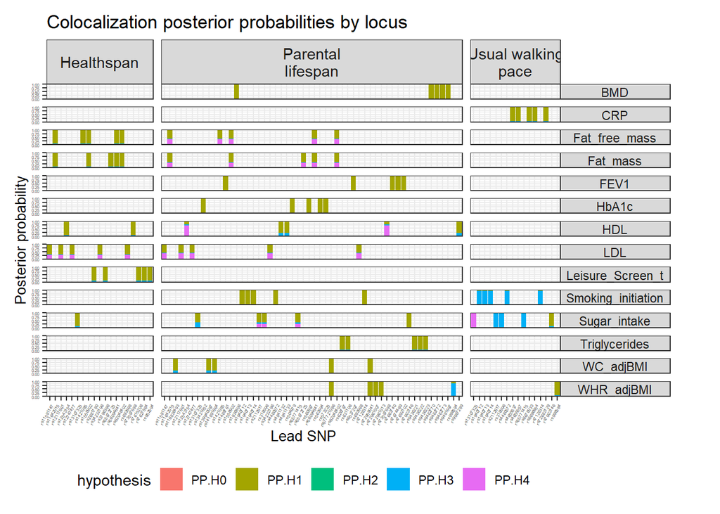

```r
#============================================================
# FIGURE B — Full posterior probabilities per locus (clean, no flip)
#============================================================

pp_long <- coloc_clean %>%
  dplyr::select(
    exposure, outcome, lead_snp,
    PP.H0, PP.H1, PP.H2, PP.H3, PP.H4
  ) %>%
  dplyr::mutate(
    outcome = dplyr::recode(
      outcome,
      "Parental_lifespan"  = "Parental lifespan",
      "Usual_walking_pace" = "Usual walking pace"
    )
  ) %>%
  pivot_longer(
    starts_with("PP."),
    names_to = "hypothesis",
    values_to = "posterior"
  )

ggplot(pp_long,
       aes(lead_snp, posterior, fill = hypothesis)) +
  geom_col(width = 0.9) +

  facet_grid(
    exposure ~ outcome,
    scales = "free_x",
    space = "free_x",
    labeller = labeller(
      outcome = label_wrap_gen(width = 15)   # <-- wraps long facet labels
    )
  ) +

  theme_bw(base_size = 11) +

  labs(
    title = "Colocalization posterior probabilities by locus",
    x = "Lead SNP",
    y = "Posterior probability"
  ) +

  scale_y_continuous(
    expand = expansion(mult = c(0, 0.02))
  ) +

  theme(
    axis.text.x = element_text(
      angle = 60,
      hjust = 1,
      size = 3
    ),
    axis.text.y = element_text(
      size = 3
    ),
    axis.title.x = element_text(
      size = 10
    ),
    axis.title.y = element_text(
      size = 10
    ),
    strip.text.y = element_text(angle = 0),
    strip.text.x = element_text(size = 11),
    plot.margin = margin(10, 35, 10, 10),
    legend.position = "bottom"
  )
```

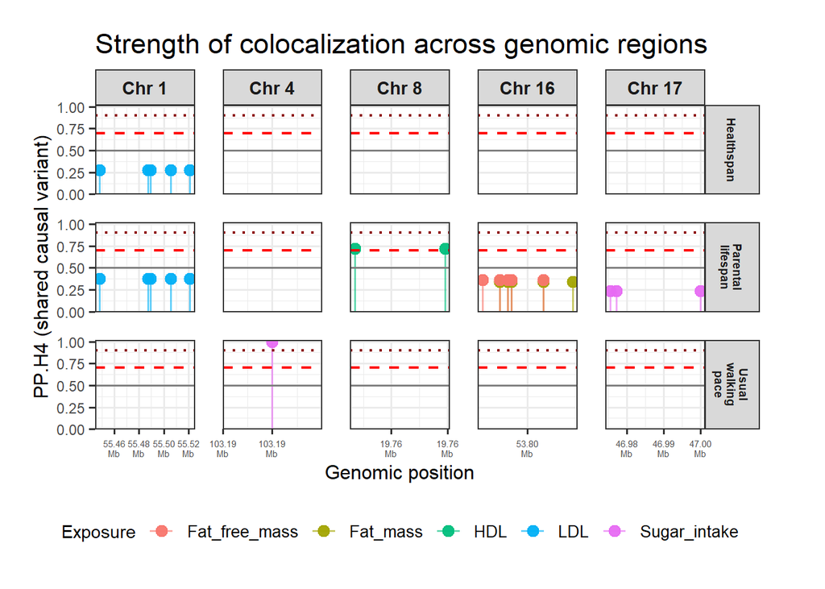

```r
#============================================================
# FIGURE C — Genomic distribution of strong PP.H4 signals
# (colored by exposure, publication-ready)
#============================================================

library(dplyr)
library(ggplot2)
library(scales)

#-------------------------------------------------------------
# Keep meaningful colocalization signals with SOFT 0.05 filter
#-------------------------------------------------------------

coloc_strong <- coloc_clean %>%
  filter(PP.H4 > 0.05)

# Clean chromosome labels
coloc_strong$chr <- paste0("Chr ", coloc_strong$chr)

# Order chromosomes numerically
coloc_strong$chr <- factor(
  coloc_strong$chr,
  levels = paste0("Chr ", sort(unique(as.numeric(gsub("Chr ", "", coloc_strong$chr)))))
)

# Clean outcome labels (remove "_" and stack words)
coloc_strong$outcome <- gsub("_", "\n", coloc_strong$outcome)

#------------------------------------------------------------
# Plot
#------------------------------------------------------------

ggplot(coloc_strong,
       aes(center_pos, PP.H4, color = exposure)) +

  geom_segment(aes(xend = center_pos,
                   y = 0,
                   yend = PP.H4),
               linewidth = 0.6,
               alpha = 0.6) +

  geom_point(size = 3, alpha = 0.95) +

  geom_hline(yintercept = 0.5,
             color = "grey50",
             linewidth = 0.6) +

  geom_hline(yintercept = 0.7,
             linetype = "dashed",
             color = "red",
             linewidth = 0.8) +

  geom_hline(yintercept = 0.9,
             linetype = "dotted",
             color = "darkred",
             linewidth = 0.8) +

  # 2-decimal Mb with Mb below number
  scale_x_continuous(
    labels = function(x) {
      paste0(sprintf("%.2f", x / 1e6), "\nMb")
    },
    breaks = scales::breaks_pretty(n = 3)
  ) +

  scale_y_continuous(
    limits = c(0, 1),
    expand = expansion(mult = c(0, 0.02))
  ) +

  facet_grid(outcome ~ chr,
             scales = "free_x") +

  theme_bw(base_size = 14) +

  labs(
    x = "Genomic position",
    y = "PP.H4 (shared causal variant)",
    title = "Strength of colocalization across genomic regions",
    color = "Exposure"
  ) +

  theme(
    axis.text.x  = element_text(size = 5.5),
    axis.text.y  = element_text(size = 9),
    axis.title.x = element_text(size = 12),
    axis.title.y = element_text(size = 12),

    strip.text.x = element_text(size = 11, face = "bold"),
    strip.text.y = element_text(size = 7, face = "bold"),

    panel.spacing = unit(1.2, "lines"),
    plot.margin = margin(20, 40, 20, 20),

    legend.position = "bottom",
    legend.text = element_text(size = 10),
    legend.title = element_text(size = 11)
  )
```

```r
# Which exposures truly colocalize

library(knitr)
library(kableExtra)

coloc_clean %>%
  group_by(exposure, outcome) %>%
  summarise(
    max_PP4 = max(PP.H4, na.rm = TRUE),
    n_over_05 = sum(PP.H4 > 0.5),
    n_over_07 = sum(PP.H4 > 0.7),
    .groups = "drop"
  ) %>%
  arrange(desc(max_PP4)) %>%
  kable(digits = 3, caption = "Which exposures truly colocalize?") %>%
  kable_styling(full_width = FALSE, bootstrap_options = c("striped", "condensed"))
```

Which exposures truly colocalize?

| exposure | outcome | max_PP4 | n_over_05 | n_over_07 |
| --- | --- | --- | --- | --- |
| Sugar_intake | Usual_walking_pace | 0.999 | 1 | 1 |
| HDL | Parental_lifespan | 0.720 | 2 | 2 |
| LDL | Parental_lifespan | 0.380 | 0 | 0 |
| Fat_free_mass | Parental_lifespan | 0.366 | 0 | 0 |
| Fat_mass | Parental_lifespan | 0.339 | 0 | 0 |
| LDL | Healthspan | 0.278 | 0 | 0 |
| Sugar_intake | Parental_lifespan | 0.239 | 0 | 0 |
| WHR_adjBMI | Parental_lifespan | 0.045 | 0 | 0 |
| HDL | Healthspan | 0.025 | 0 | 0 |
| WC_adjBMI | Parental_lifespan | 0.018 | 0 | 0 |
| Fat_free_mass | Healthspan | 0.010 | 0 | 0 |
| Fat_mass | Healthspan | 0.009 | 0 | 0 |
| Sugar_intake | Healthspan | 0.006 | 0 | 0 |
| CRP | Usual_walking_pace | 0.003 | 0 | 0 |
| FEV1 | Parental_lifespan | 0.002 | 0 | 0 |
| BMD | Parental_lifespan | 0.002 | 0 | 0 |
| Leisure_Screen_t | Healthspan | 0.002 | 0 | 0 |
| HbA1c | Parental_lifespan | 0.001 | 0 | 0 |
| Smoking_initiation | Parental_lifespan | 0.001 | 0 | 0 |
| Triglycerides | Parental_lifespan | 0.001 | 0 | 0 |
| WHR_adjBMI | Usual_walking_pace | 0.001 | 0 | 0 |
| Smoking_initiation | Usual_walking_pace | 0.000 | 0 | 0 |

```r
#============================================================
# FIGURE C — Genomic distribution of PP.H4 signals
# (Collapsible by exposure, highlight PP.H4 > 0.5)
#============================================================


library(dplyr)
library(ggplot2)

exposures <- unique(coloc_clean$exposure)

for (exp in exposures) {

  # Open collapsible block
  cat("\n<details>\n")
  cat(paste0(
    "<summary><b>", exp,
    " — Genomic distribution of PP.H4 signals</b></summary>\n\n"
  ))

  df_exp <- coloc_clean %>%
    filter(exposure == exp)

  p <- ggplot(df_exp,
              aes(center_pos, PP.H4)) +

    # Highlight loci with PP.H4 > 0.5
    geom_point(aes(color = PP.H4 > 0.5),
               size = 2.3,
               alpha = 0.9) +

    scale_color_manual(
      values = c("TRUE" = "#D73027",
                 "FALSE" = "grey60"),
      labels = c("FALSE" = "PP.H4 ≤ 0.5",
                 "TRUE" = "PP.H4 > 0.5"),
      name = NULL
    ) +

    # Facet by outcome
    facet_wrap(~ outcome,
               ncol = 1,
               scales = "free_x") +

    # Threshold lines
    geom_hline(yintercept = 0.7,
               linetype = "dashed",
               color = "red",
               linewidth = 0.8) +

    geom_hline(yintercept = 0.9,
               linetype = "dotted",
               color = "darkred",
               linewidth = 0.8) +

    theme_bw(base_size = 12) +

    labs(
      x = "Genomic position (bp)",
      y = "PP.H4 (shared causal variant)",
      title = paste(
        "Strength of colocalization across genomic regions —",
        exp
      )
    ) +

    theme(
      strip.text = element_text(size = 11),
      panel.spacing = unit(0.8, "lines"),
      plot.margin = margin(15, 40, 15, 15),
      legend.position = "bottom",
      legend.box = "vertical"
    )

  print(p)

  cat("\n</details>\n")
}
```

**LDL — Genomic distribution of PP.H4 signals**

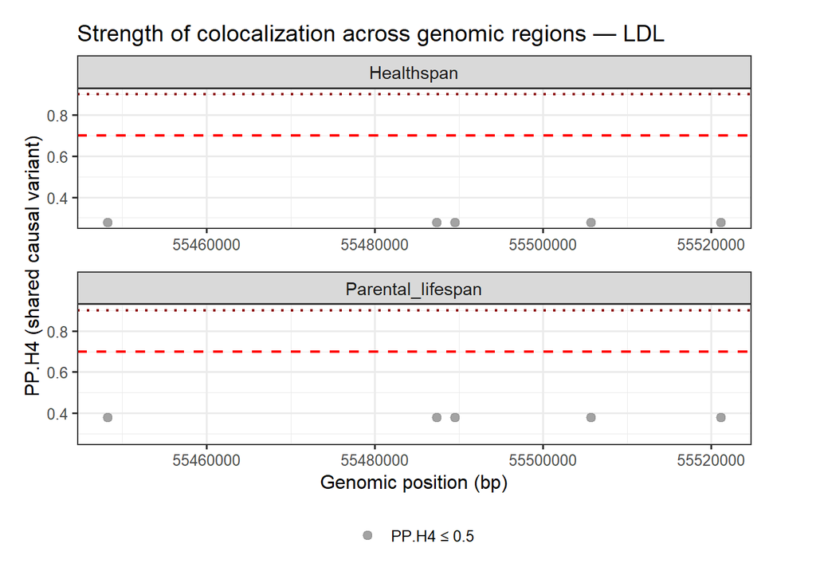

**Fat_mass — Genomic distribution of PP.H4 signals**

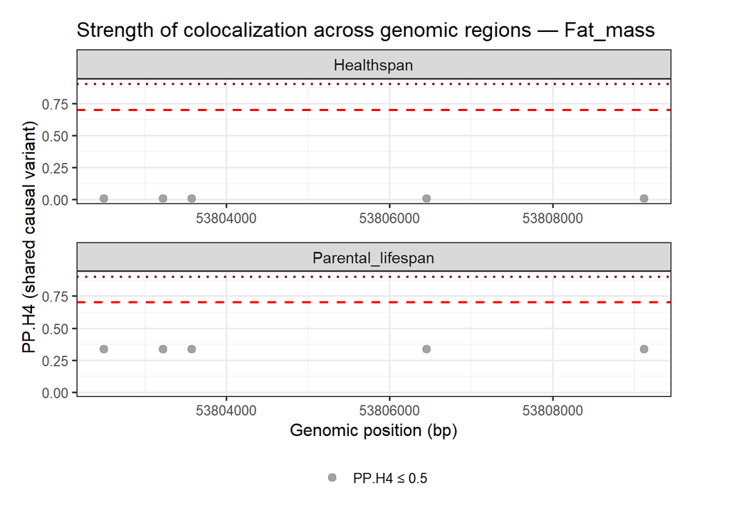

**HDL — Genomic distribution of PP.H4 signals**

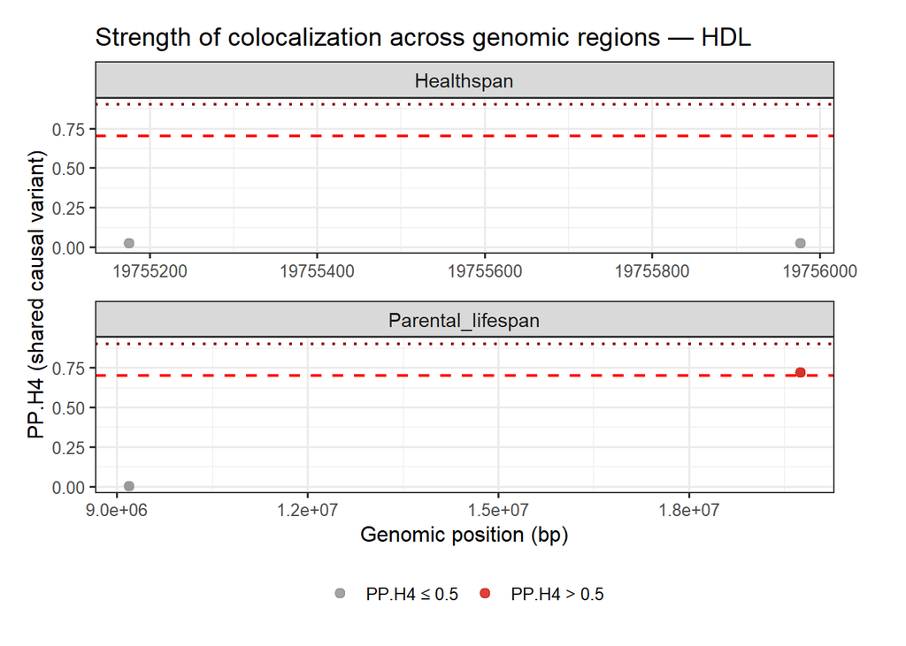

**Fat_free_mass — Genomic distribution of PP.H4 signals**

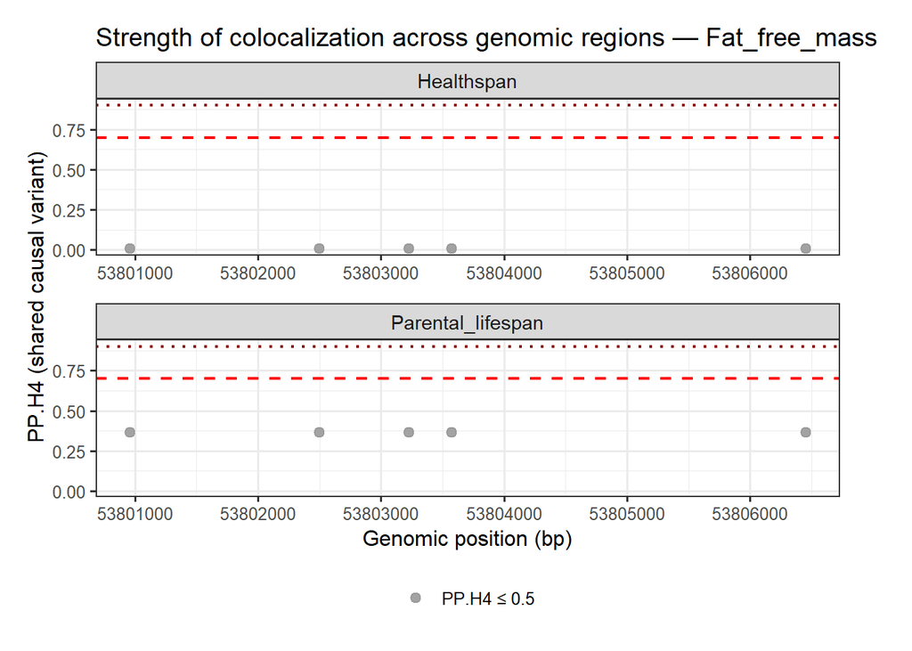

**Leisure_Screen_t — Genomic distribution of PP.H4 signals**

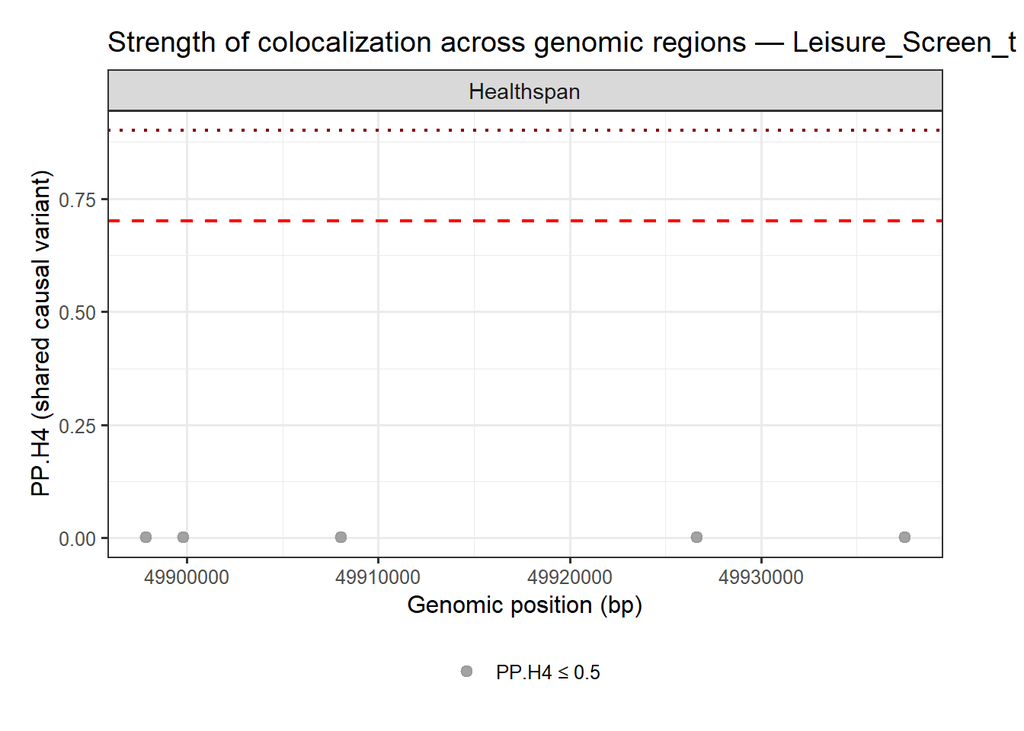

**Sugar_intake — Genomic distribution of PP.H4 signals**

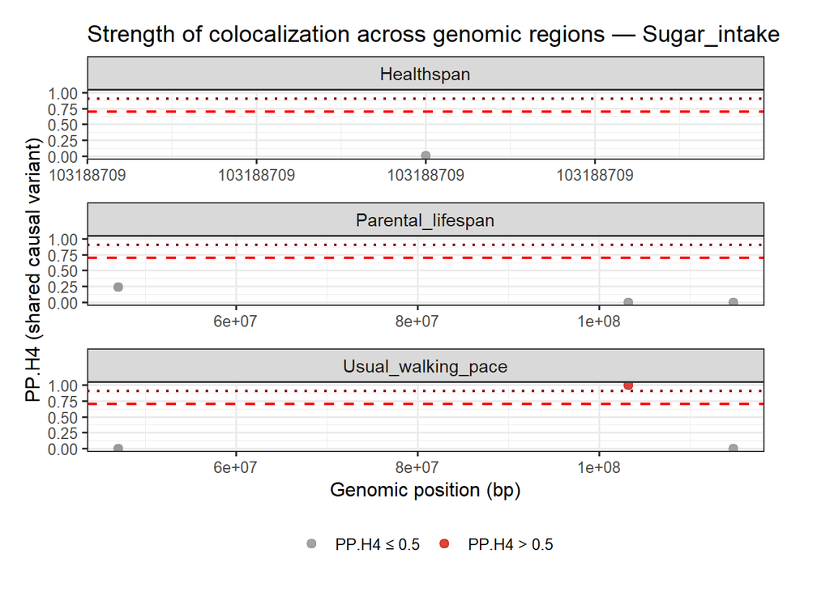

**Smoking_initiation — Genomic distribution of PP.H4 signals**

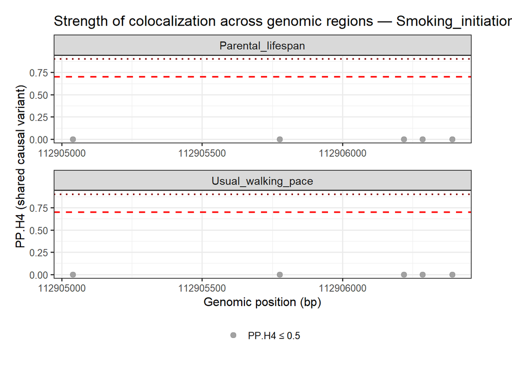

**Triglycerides — Genomic distribution of PP.H4 signals**

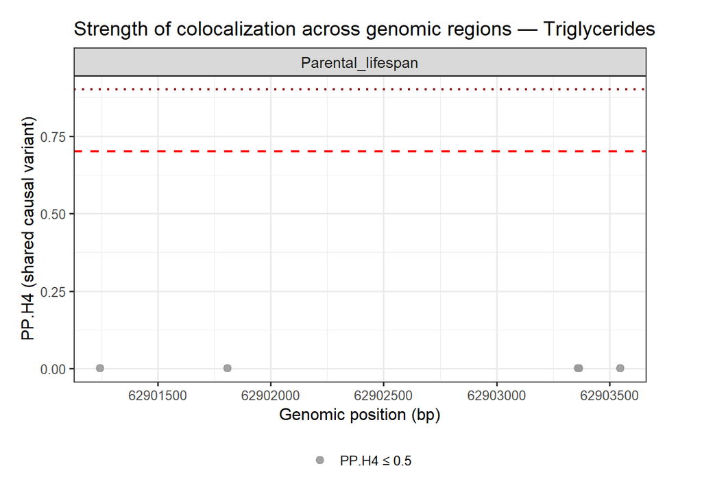

**WHR_adjBMI — Genomic distribution of PP.H4 signals**

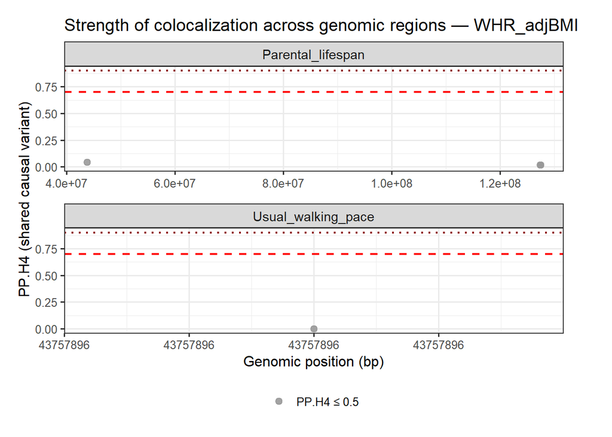

**WC_adjBMI — Genomic distribution of PP.H4 signals**

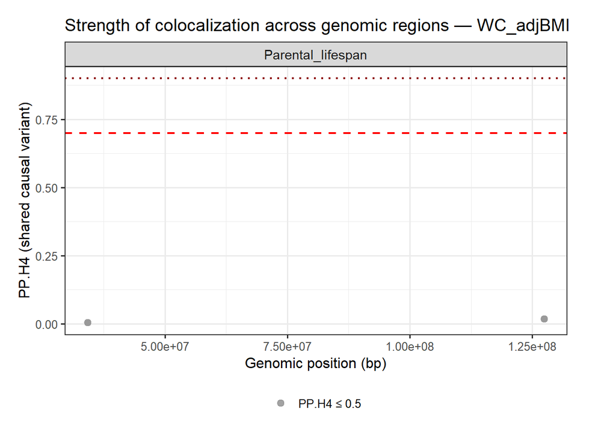

**HbA1c — Genomic distribution of PP.H4 signals**

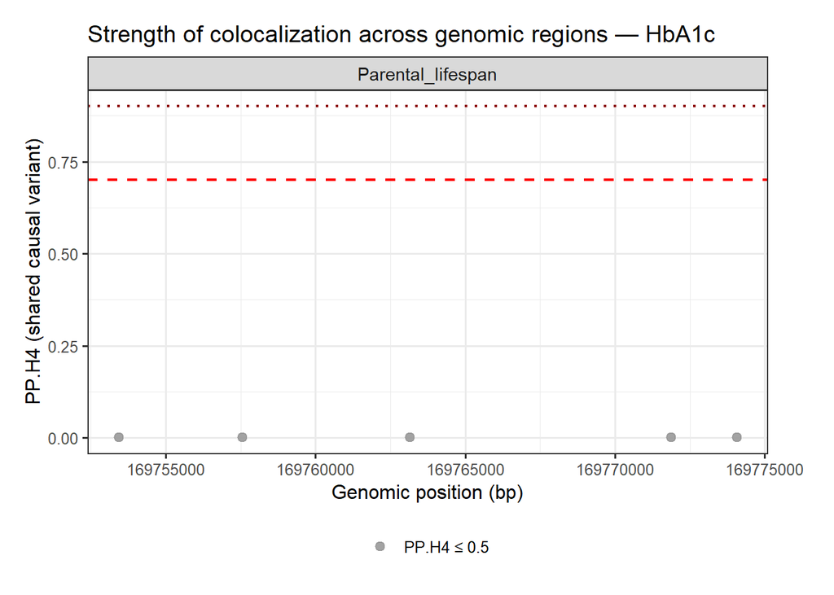

**FEV1 — Genomic distribution of PP.H4 signals**

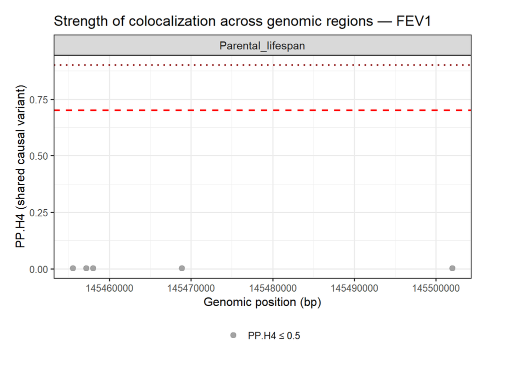

**BMD — Genomic distribution of PP.H4 signals**

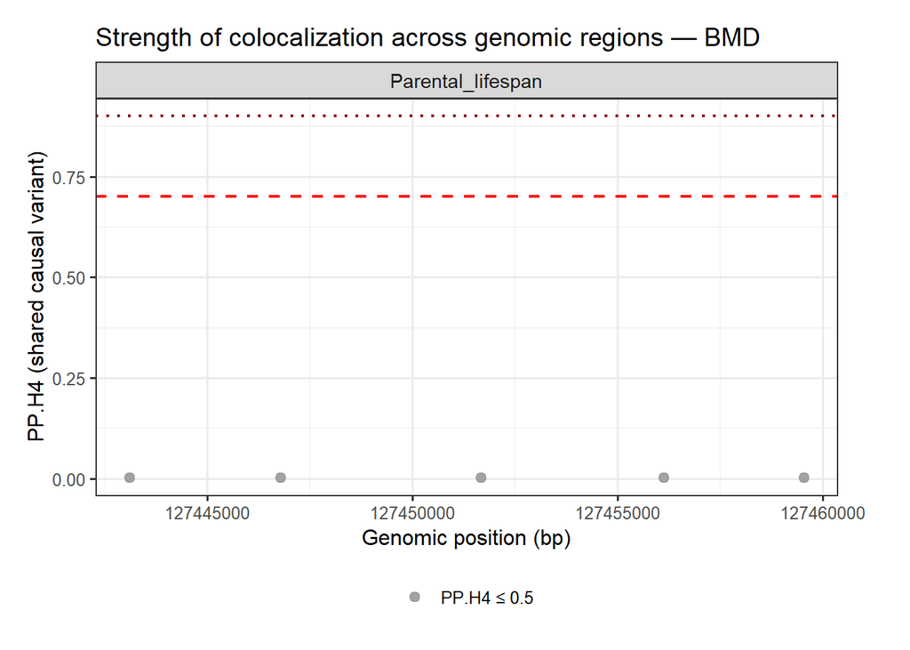

**CRP — Genomic distribution of PP.H4 signals**

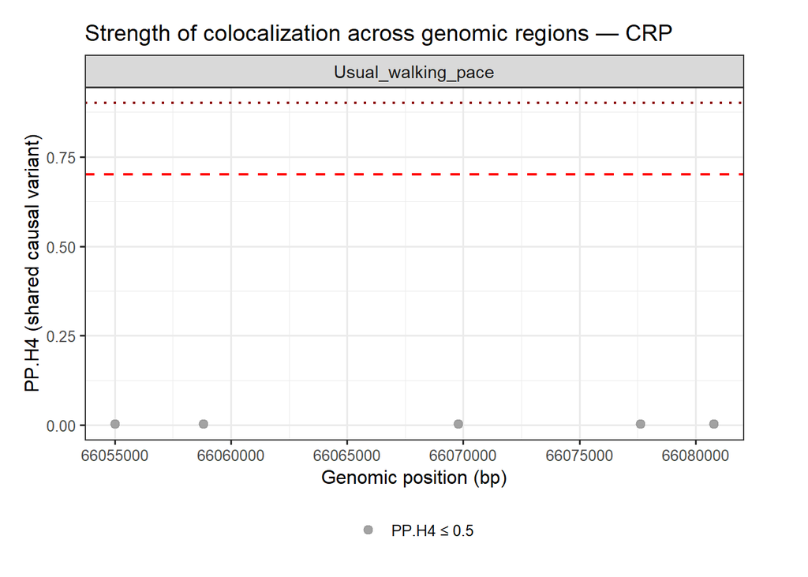

```r
# Note on HDL → Parental_lifespan colocalization:
# Although n_over_05 = 2, both SNPs (rs73597688 and rs12543154)
# are ~800 bp apart and represent the same genomic locus.
# Therefore, this corresponds to one independent
# colocalized region (PP.H4 ≈ 0.72), not two separate signals.

coloc_clean %>%
  dplyr::filter(exposure == "HDL",
         outcome == "Parental_lifespan",
         PP.H4 > 0.5) %>%
  dplyr::select(lead_snp, center_pos, PP.H4) %>%
  kable(
    digits = 3,
    caption = "HDL loci colocalizing with Parental Lifespan (PP4 > 0.5)"
  ) %>%
  kable_styling(
    full_width = FALSE,
    bootstrap_options = c("striped", "condensed")
  )
```

HDL loci colocalizing with Parental Lifespan (PP4 > 0.5)

| lead_snp | center_pos | PP.H4 |
| --- | --- | --- |
| rs73597688 | 19755175 | 0.72 |
| rs12543154 | 19755977 | 0.72 |

```r
#============================================================
# OPTIONAL — list strong colocalization hits (for Results text)
#============================================================

library(DT)

strong_hits <- coloc_clean %>%
  mutate(
    coloc_strength = dplyr::case_when(
      PP.H4 >= 0.9 ~ "Very strong",
      PP.H4 >= 0.7 ~ "Strong",
      PP.H4 >= 0.3 ~ "Suggestive",
      TRUE ~ "None"
    )
  ) %>%
  filter(PP.H4 >= 0.3) %>%     # <-- include suggestive tier
  arrange(desc(PP.H4))

datatable(
  strong_hits,
  extensions = c("Scroller"),
  options = list(
    scrollY = 400,
    scrollX = TRUE,
    scroller = TRUE,
    pageLength = 25
  ),
  rownames = FALSE
)
```

| exposure | outcome | lead_snp | chr | center_pos | nsnps_region | PP.H0 | PP.H1 | PP.H2 | PP.H3 | PP.H4 | PP.H4_percent | strong_coloc | very_strong_coloc | coloc_strength |
| --- | --- | --- | --- | --- | --- | --- | --- | --- | --- | --- | --- | --- | --- | --- |
| Sugar_intake | Usual_walking_pace | rs13107325 | 4 | 103188709 | 4097 | 1.273446036288038e-23 | 1.309306085800392e-19 | 1.526739772539331e-07 | 0.0005703029913651091 | 0.9994295443346579 | 99.94 | True | True | Very strong |
| HDL | Parental_lifespan | rs12543154 | 8 | 19755977 | 2161 | 0 | 0.2017080685894795 | 0 | 0.07865835725906628 | 0.7196335741513665 | 71.96 | True | False | Strong |
| HDL | Parental_lifespan | rs73597688 | 8 | 19755175 | 2161 | 0 | 0.2017109954019033 | 0 | 0.07865777703923058 | 0.7196312275586634 | 71.96 | True | False | Strong |
| LDL | Parental_lifespan | rs12747477 | 1 | 55448248 | 3784 | 0 | 0.5789611961636911 | 0 | 0.04116109613417447 | 0.3798777077019256 | 37.99 | False | False | Suggestive |
| LDL | Parental_lifespan | rs693668 | 1 | 55521109 | 3809 | 0 | 0.5775267064746777 | 0 | 0.04302763299262839 | 0.3794456605328178 | 37.94 | False | False | Suggestive |
| LDL | Parental_lifespan | rs34232196 | 1 | 55489542 | 3788 | 0 | 0.577412884654115 | 0 | 0.04343550804237164 | 0.3791516073033464 | 37.92 | False | False | Suggestive |
| LDL | Parental_lifespan | rs12117661 | 1 | 55487346 | 3778 | 0 | 0.5774426112484423 | 0 | 0.04341211112822431 | 0.3791452776234223 | 37.91 | False | False | Suggestive |
| LDL | Parental_lifespan | rs11591147 | 1 | 55505647 | 3818 | 0 | 0.5771021434240858 | 0 | 0.04386928104718867 | 0.3790285755288902 | 37.9 | False | False | Suggestive |
| Fat_free_mass | Parental_lifespan | rs1421085 | 16 | 53800954 | 3164 | 2.167949662204486e-218 | 0.5959491890101003 | 1.403932515293037e-219 | 0.03822697462663723 | 0.3658238363632498 | 36.58 | False | False | Suggestive |
| Fat_free_mass | Parental_lifespan | rs56094641 | 16 | 53806453 | 3164 | 2.167916639877011e-218 | 0.5959347119877103 | 1.404953682183072e-219 | 0.03825470888861041 | 0.3658105791236719 | 36.58 | False | False | Suggestive |

[output cut: 8 more lines]

```r
# 1) Map nearby genes (Ensembl biomaRt; GRCh37 friendly)

#============================================================
# COLOC → nearby gene mapping (± window bp)
#============================================================

#============================================================
# FAST nearby gene mapping for all coloc loci (batched)
#============================================================

suppressPackageStartupMessages({
  library(dplyr)
  library(tibble)
  library(biomaRt)
})

#------------------------------------------------------------
# Parameters
#------------------------------------------------------------

window_bp <- 500000     # ±500 kb (change if needed)
top_genes <- 8         # number of closest genes to keep per locus

#------------------------------------------------------------
# Collapse coloc to 1 locus per exposure–outcome (highest PP.H4)
#------------------------------------------------------------

coloc_locus <- coloc_clean %>%
  group_by(exposure, outcome, chr) %>%
  slice_max(order_by = PP.H4, n = 1, with_ties = FALSE) %>%
  ungroup() %>%
  mutate(
    chr = as.character(chr),
    center_pos = as.integer(center_pos)
  )

#------------------------------------------------------------
# Build genomic windows for all loci
#------------------------------------------------------------

regions <- coloc_locus %>%
  transmute(
    exposure,
    outcome,
    lead_snp,
    chr,
    start = pmax(1L, center_pos - window_bp),
    end   = center_pos + window_bp,
    center_pos,
    PP.H4
  )

#------------------------------------------------------------
# Connect ONCE to Ensembl (GRCh37)
#------------------------------------------------------------

gene_cache_file <- file.path(out_dir, "coloc_gene_annotation_cache.rds")

if (file.exists(gene_cache_file)) {

  message("⚡ Loading cached gene annotation")
  gene_raw <- readRDS(gene_cache_file)

} else {

  message("🌐 Querying Ensembl (first run only)")

  mart <- useEnsembl(
    biomart = "genes",
    dataset = "hsapiens_gene_ensembl",
    GRCh = 37
  )

#------------------------------------------------------------
# Pull ALL genes across ALL regions in one query
#------------------------------------------------------------

  gene_raw <- getBM(
    attributes = c(
      "hgnc_symbol",
      "ensembl_gene_id",
      "chromosome_name",
      "start_position",
      "end_position",
      "gene_biotype"
    ),
    filters = c("chromosome_name","start","end"),
    values  = list(regions$chr, regions$start, regions$end),
    mart    = mart
  ) %>%
    as_tibble() %>%
    filter(hgnc_symbol != "") %>%
    mutate(chromosome_name = as.character(chromosome_name))

  saveRDS(gene_raw, gene_cache_file)
  message("💾 Gene annotation cached")
}


#------------------------------------------------------------
# Match genes back to each locus window + distance to lead SNP
#------------------------------------------------------------

gene_map_fast <- regions %>%
  left_join(
    gene_raw,
    by = c("chr" = "chromosome_name")
  ) %>%
  filter(
    start_position >= start,
    end_position   <= end
  ) %>%
  mutate(
    dist_to_center = pmin(
      abs(start_position - center_pos),
      abs(end_position   - center_pos)
    )
  ) %>%
  arrange(exposure, outcome, dist_to_center)


#------------------------------------------------------------
# OPTIONAL — collapse to closest genes per locus (clean table)
#------------------------------------------------------------

gene_annot_fast <- gene_map_fast %>%
  group_by(exposure, outcome, lead_snp, chr, center_pos, PP.H4) %>%
  summarise(
    nearby_genes = paste(
      head(unique(hgnc_symbol), top_genes),
      collapse = ", "
    ),
    .groups = "drop"
  )

#------------------------------------------------------------
# Merge gene annotation back to coloc loci
#------------------------------------------------------------

coloc_locus_annot <- coloc_locus %>%
  left_join(
    gene_annot_fast,
    by = c("exposure","outcome","lead_snp","chr","center_pos","PP.H4")
  )



# 2) Merge coloc tier into your causal robustness score
# A) Build a clean coloc tier + numeric score


#============================================================
# COLOC tier + score
#============================================================

coloc_locus_scored <- coloc_locus_annot %>%
  mutate(
    coloc_strength = case_when(
      PP.H4 >= 0.9 ~ "Very strong",
      PP.H4 >= 0.7 ~ "Strong",
      PP.H4 >= 0.3 ~ "Suggestive",
      TRUE ~ "None"
    ),
    coloc_score = case_when(
      PP.H4 >= 0.9 ~ 3L,
      PP.H4 >= 0.7 ~ 2L,
      PP.H4 >= 0.3 ~ 1L,
      TRUE ~ 0L
    )
  ) %>%
  dplyr::select(     # ← this is the fix
    exposure, outcome, PP.H4, coloc_strength, coloc_score,
    lead_snp, chr, center_pos, nearby_genes
  )


datatable(
  coloc_locus_scored,
  extensions = c("Scroller"),
  options = list(
    scrollY = 400,
    scrollX = TRUE,
    scroller = TRUE,
    pageLength = 25
  ),
  rownames = FALSE
)
```

| exposure | outcome | PP.H4 | coloc_strength | coloc_score | lead_snp | chr | center_pos | nearby_genes |
| --- | --- | --- | --- | --- | --- | --- | --- | --- |
| BMD | Parental_lifespan | 0.001976818904834752 | None | 0 | rs9482770 | 6 | 127443092 | RSPO3, RNF146, ECHDC1, RNA5SP217, YWHAZP4, RPL5P18, SOGA3, KIAA0408 |
| CRP | Usual_walking_pace | 0.002815921842597154 | None | 0 | rs4655557 | 1 | 66080787 | LEPR, RN7SL854P, LEPROT, RNU2-15P, DNAJC6, COX6CP13, AK4, RNU4-88P |
| FEV1 | Parental_lifespan | 0.002486161387399132 | None | 0 | rs6537297 | 4 | 145502029 | KRT18P51, HHIP-AS1, HHIP, HSPD1P5, GYPA, RN7SKP235 |
| Fat_free_mass | Healthspan | 0.009579636478303507 | None | 0 | rs62048402 | 16 | 53803223 | FTO, RPGRIP1L, AKTIP, FTO-IT1, RBL2, RNU6-1153P, RNA5SP427 |
| Fat_free_mass | Parental_lifespan | 0.3658238363632498 | Suggestive | 1 | rs1421085 | 16 | 53800954 | FTO, RPGRIP1L, AKTIP, FTO-IT1, RBL2, RNU6-1153P, RNA5SP427 |
| Fat_mass | Healthspan | 0.009344652890976798 | None | 0 | rs62048402 | 16 | 53803223 | FTO, RPGRIP1L, AKTIP, FTO-IT1, RBL2, RNU6-1153P, RNA5SP427 |
| Fat_mass | Parental_lifespan | 0.339214637274749 | Suggestive | 1 | rs55872725 | 16 | 53809123 | FTO, RPGRIP1L, FTO-IT1, AKTIP, RBL2, RNU6-1153P, RNA5SP427 |
| HDL | Healthspan | 0.02536528385985075 | None | 0 | rs12543154 | 8 | 19755977 | LPL, INTS10, CSGALNACT1, RPL30P9, SLC18A1, ATP6V1B2, RNU6-892P, LZTS1 |
| HDL | Parental_lifespan | 0.7196335741513665 | Strong | 2 | rs12543154 | 8 | 19755977 | LPL, INTS10, CSGALNACT1, RPL30P9, SLC18A1, ATP6V1B2, RNU6-892P, LZTS1 |
| HbA1c | Parental_lifespan | 0.001476998391769973 | None | 0 | rs13431652 | 2 | 169753415 | G6PC2, SPC25, ABCB11, NOSTRIN, CERS6-AS1, CERS6, DHRS9, UBE2V1P6 |

[output cut: 16 more lines]

```r
# B) Merge into your existing “robustness” table

#============================================================
# Merge COLOC into sensitivity robustness table (sens_tab_simple)
#============================================================

robust_with_coloc <- sens_tab_simple %>%
  transmute(
    exposure = Exposure,
    outcome  = Outcome,
    q = `FDR q`,          # ← THIS is the real column
    Robustness,
    Stars,
    b_ivw = NA_real_     # you don’t have b_ivw in this table — keep NA
  ) %>%
  left_join(coloc_locus_scored, by = c("exposure","outcome")) %>%
  mutate(
    robustness_score = case_when(
      Robustness %in% c("Very high","Very robust") ~ 3L,
      Robustness %in% c("High","Robust")          ~ 2L,
      Robustness %in% c("Moderate")               ~ 1L,
      TRUE                                        ~ 0L
    ),
    evidence_score = robustness_score + coloc_score,
    evidence_tier = case_when(
      evidence_score >= 5 ~ "Top-tier causal + shared locus",
      evidence_score >= 3 ~ "Robust causal / partial locus support",
      evidence_score >= 1 ~ "Suggestive",
      TRUE                ~ "Weak"
    )
  )


datatable(
  robust_with_coloc,
  extensions = c("Scroller"),
  options = list(
    scrollY = 400,
    scrollX = TRUE,
    scroller = TRUE,
    pageLength = 25
  ),
  rownames = FALSE
)
```

| exposure | outcome | q | Robustness | Stars | b_ivw | PP.H4 | coloc_strength | coloc_score | lead_snp | chr | center_pos | nearby_genes | robustness_score | evidence_score | evidence_tier |
| --- | --- | --- | --- | --- | --- | --- | --- | --- | --- | --- | --- | --- | --- | --- | --- |
| WC_adjBMI | Healthspan | &lt;0.001 | Strong | ★ |  |  |  |  |  |  |  |  | 0 |  | Weak |
| WHR_adjBMI | Healthspan | 8.0e-16 | Strong | ★ |  |  |  |  |  |  |  |  | 0 |  | Weak |
| Fat_mass | Healthspan | 0.001 | Strong | ★ |  | 0.009344652890976798 | None | 0 | rs62048402 | 16 | 53803223 | FTO, RPGRIP1L, AKTIP, FTO-IT1, RBL2, RNU6-1153P, RNA5SP427 | 0 | 0 | Weak |
| Triglycerides | Healthspan | &lt;0.001 | Strong | ★ |  |  |  |  |  |  |  |  | 0 |  | Weak |
| HbA1c | Healthspan | 6.1e-13 | Strong | ★ |  |  |  |  |  |  |  |  | 0 |  | Weak |
| Leisure_Screen_t | Healthspan | 0.044 | Strong | ★ |  | 0.001776286834695701 | None | 0 | rs952594 | 3 | 49908023 | CAMKV, ACTBP13, RN7SL217P, TRAIP, MST1R, MON1A, UBA7, MIR5193 | 0 | 0 | Weak |
| LDL | Healthspan | &lt;0.001 | Strong | ★ |  | 0.2782953937183198 | None | 0 | rs12747477 | 1 | 55448248 | TMEM61, BSND, PCSK9, USP24, DHCR24, C1orf177, TTC22, PARS2 | 0 | 0 | Weak |
| FEV1 | Healthspan | 0.023 | Strong | ★ |  |  |  |  |  |  |  |  | 0 |  | Weak |
| Fat_free_mass | Healthspan | 0.044 | Strong | ★ |  | 0.009579636478303507 | None | 0 | rs62048402 | 16 | 53803223 | FTO, RPGRIP1L, AKTIP, FTO-IT1, RBL2, RNU6-1153P, RNA5SP427 | 0 | 0 | Weak |
| HDL | Healthspan | 0.004 | Strong | ★ |  | 0.02536528385985075 | None | 0 | rs12543154 | 8 | 19755977 | LPL, INTS10, CSGALNACT1, RPL30P9, SLC18A1, ATP6V1B2, RNU6-892P, LZTS1 | 0 | 0 | Weak |

[output cut: 27 more lines]

[figure not shown]

```r
# 3) Clean combined summary figure (MR + coloc together)

#============================================================
# FIGURE — Combined MR + COLOC evidence (paper-style)
#============================================================

suppressPackageStartupMessages({
  library(ggplot2)
  library(ggrepel)
})

plot_df_collapsed <- mr_results %>%
  dplyr::filter(
    method == "Inverse variance weighted (multiplicative random effects)"
  ) %>%
  dplyr::select(
    exposure,
    outcome,
    b_ivw = b
  ) %>%
  left_join(
    coloc_locus_scored,
    by = c("exposure","outcome")
  ) %>%
  left_join(
    sens_tab_simple %>%
      transmute(
        exposure = Exposure,
        outcome  = Outcome,
        q = `FDR q`
      ),
    by = c("exposure","outcome")
  ) %>%
  mutate(
    q_num = as.numeric(gsub("<","", q)),
    neglog10q = -log10(pmax(q_num, 1e-300)),
    coloc_strength = factor(
      coloc_strength,
      levels = c("None","Suggestive","Strong","Very strong")
    )
  )


ggplot(plot_df_collapsed, aes(x = b_ivw, y = exposure)) +
  geom_vline(xintercept = 0, linetype = "dashed", alpha = 0.4) +
  geom_point(
    aes(size = neglog10q, color = coloc_strength, alpha = coloc_score > 0),
    show.legend = TRUE
  ) +
  scale_alpha_manual(values = c(`TRUE` = 1, `FALSE` = 0.15), guide = "none") +
  facet_grid(outcome ~ ., scales = "free_y", space = "free_y") +
  theme_bw(base_size = 12) +
  labs(
    title = "MR effects with colocalization evidence highlighted",
    x = "IVW effect (β)",
    y = NULL
  ) +
  theme(
    axis.text.y = element_text(size = 5)  # 👈 smaller y-axis labels
  )
```

```r
############################################################
# SAVE ALL FIGURES & TABLES — Section 15.12
############################################################

library(htmlwidgets)
library(webshot2)

out_dir <- "C:/Users/75118/Desktop/UEA/Proyecto 1/MainMRresults"
dir.create(out_dir, showWarnings = FALSE, recursive = TRUE)

#------------------------------------------------------------
# Recreate plots as objects (for saving)
#------------------------------------------------------------

fig_A <- ggplot(pp4_matrix,
       aes(exposure, outcome, fill = max_PP4)) +
  geom_tile(color = "white") +
  scale_fill_gradient(low = "white", high = "darkred") +
  labs(
    title = "Colocalization evidence for shared causal variants (PP.H4)",
    fill = "PP.H4"
  ) +
  theme_bw() +
  theme(axis.text.x = element_text(angle = 45, hjust = 1))

fig_B <- ggplot(pp_long, aes(lead_snp, posterior, fill = hypothesis)) +
  geom_col(width = 0.9) +
  facet_grid(
    exposure ~ outcome,
    scales = "free_x",
    space  = "free_x",
    labeller = labeller(
      outcome  = label_wrap_gen(width = 15),
      exposure = label_wrap_gen(width = 12)
    )
  ) +
  theme_bw(base_size = 11) +
  labs(
    title = "Colocalization posterior probabilities by locus",
    x = "Lead SNP",
    y = "Posterior probability"
  ) +
  scale_y_continuous(expand = expansion(mult = c(0, 0.02))) +
  theme(
    axis.text.x = element_text(angle = 60, hjust = 1, size = 7),
    axis.text.y = element_text(size = 6),
    strip.text.y = element_text(angle = 0),  # keep readable
    legend.position = "bottom"
  )


fig_C <- ggplot(coloc_clean,
       aes(center_pos, PP.H4)) +
  geom_point(size = 2, alpha = 0.8) +
  facet_grid(exposure ~ outcome) +
  geom_hline(yintercept = 0.7, linetype = "dashed", color = "red") +
  geom_hline(yintercept = 0.9, linetype = "dotted", color = "darkred") +
  theme_bw(base_size = 12) +
  labs(
    x = "Genomic position (bp)",
    y = "PP.H4",
    title = "Strength of colocalization across genomic regions"
  )

fig_combined <- ggplot(plot_df_collapsed, aes(x = b_ivw, y = exposure)) +
  geom_vline(xintercept = 0, linetype = "dashed", alpha = 0.4) +
  geom_point(
    aes(size = neglog10q, color = coloc_strength, alpha = coloc_score > 0)
  ) +
  scale_alpha_manual(values = c(`TRUE` = 1, `FALSE` = 0.15), guide = "none") +
  facet_grid(outcome ~ ., scales = "free_y", space = "free_y") +
  theme_bw(base_size = 12) +
  labs(
    title = "MR effects with colocalization evidence highlighted",
    x = "IVW effect (β)",
    y = NULL
  )

#------------------------------------------------------------
# Save PNG figures (high-resolution paper quality)
#------------------------------------------------------------

ggsave(
  file.path(out_dir, "Section_15.12_PP4_heatmap.png"),
  fig_A, width = 7, height = 5, dpi = 300
)

ggsave(
  file.path(out_dir, "Section_15.12_Posterior_bars.png"),
  fig_B, width = 11, height = 7, dpi = 300
)

ggsave(
  file.path(out_dir, "Section_15.12_PP4_genomic_scatter.png"),
  fig_C, width = 10, height = 7, dpi = 300
)

ggsave(
  file.path(out_dir, "Section_15.12_MR_COLOC_combined.png"),
  fig_combined, width = 8, height = 6, dpi = 300
)



############################################################
# SAVE COLOC + ROBUSTNESS TABLES AS EXCEL (recommended)
############################################################

library(openxlsx)

out_dir <- "C:/Users/75118/Desktop/UEA/Proyecto 1/MainMRresults"

#------------------------------------------------------------
# 1) Strong coloc hits
#------------------------------------------------------------

write.xlsx(
  strong_hits,
  file = file.path(out_dir, "Section_15.12_Strong_coloc_hits.xlsx"),
  overwrite = TRUE
)

#------------------------------------------------------------
# 2) Coloc loci scored + gene annotation
#------------------------------------------------------------

write.xlsx(
  coloc_locus_scored,
  file = file.path(out_dir, "Section_15.12_Coloc_loci_scored.xlsx"),
  overwrite = TRUE
)

#------------------------------------------------------------
# 3) MR + COLOC combined evidence table
#------------------------------------------------------------

write.xlsx(
  robust_with_coloc,
  file = file.path(out_dir, "Section_15.12_MR_COLOC_evidence_table.xlsx"),
  overwrite = TRUE
)

cat("✅ Excel tables saved to:", out_dir, "\n")
```

✅ Excel tables saved to: C:/Users/75118/Desktop/UEA/Proyecto 1/MainMRresults

# 16. MVMR

## 16.1 Reduced MVMR

```r
#------------------------------------------------------------
# OUTPUT PATH
#------------------------------------------------------------
out_dir <- "C:/Users/75118/Desktop/UEA/Proyecto 1/MVMR"

if (!dir.exists(out_dir)) {
  dir.create(out_dir, recursive = TRUE)
}


############################################################
# 🔷 MULTIVARIABLE MENDELIAN RANDOMIZATION (MVMR)
# REDUCED MODEL — CLUMPED + FAST + ROBUST
############################################################

library(data.table)
library(dplyr)
library(MendelianRandomization)
library(MVMR)
library(tibble)

set.seed(123)

#------------------------------------------------------------
# PATHS
#------------------------------------------------------------
mapped_dir <- "C:/Users/75118/Desktop/UEA/Proyecto 1/mapped_full_traits"
clump_dir  <- "clumped_instruments"

#------------------------------------------------------------
# 🔷 REDUCED MVMR SETS (WEAK INSTRUMENTS REMOVED)
#------------------------------------------------------------

mvmr_sets_reduced <- list(

  Healthspan = c(
    "Fat_mass",
    "WHR_adjBMI",
    "LDL",
    "HbA1c",
    "FEV1"
  ),

  Parental_lifespan = c(
    "Fat_mass",
    "WHR_adjBMI",
    "LDL",
    "HbA1c",
    "FEV1"
  ),

  Usual_walking_pace = c(
    "Grip_strength",
    "Fat_mass",
    "FEV1",
    "Smoking_initiation",
    "HbA1c"
  )
)

#------------------------------------------------------------
# HELPERS
#------------------------------------------------------------
load_trait <- function(trait) {

  df <- readRDS(file.path(mapped_dir, paste0("mapped_full_", trait, ".rds")))

  required <- c("SNP", "BETA", "SE")
  missing_cols <- setdiff(required, colnames(df))

  if (length(missing_cols) > 0) {
    stop(paste("Missing columns in", trait, ":", paste(missing_cols, collapse=", ")))
  }

  df
}

compute_p <- function(df) {
  df$P <- 2 * pnorm(-abs(df$BETA / df$SE))
  df
}

load_clumped_snps <- function(trait) {

  file <- file.path(clump_dir, paste0("clumped_", trait, ".rds"))

  if (!file.exists(file)) {
    stop(paste("Missing clumped file for:", trait))
  }

  df <- readRDS(file)

  if (!"SNP" %in% colnames(df)) {
    stop(paste("Clumped file missing SNP column:", trait))
  }

  unique(df$SNP)
}

#------------------------------------------------------------
# RESET STORAGE
#------------------------------------------------------------
rm(list = c("mvmr_results", "mvmr_fstats", "mvmr_pleio"))

mvmr_results <- list()
mvmr_fstats  <- list()
mvmr_pleio   <- list()

# 🔥 NEW STORAGE
mvmr_snp_info         <- list()
mvmr_snp_contribution <- list()

k <- 1

#============================================================
# 🔁 MAIN LOOP (REDUCED MODEL)
#============================================================
for (out in names(mvmr_sets_reduced)) {

  cat("\n==============================\n")
  cat("Running REDUCED MVMR for outcome:", out, "\n")

  exposures <- mvmr_sets_reduced[[out]]
  cat("Exposures:", paste(exposures, collapse = ", "), "\n")

  #----------------------------------------------------------
  # LOAD CLUMPED SNPs + GWS FILTER
  #----------------------------------------------------------
  snp_list <- lapply(exposures, function(tr) {

    snps <- load_clumped_snps(tr)
    df   <- load_trait(tr)

    df <- df[df$SNP %in% snps, ]
    df <- compute_p(df)
    df <- df[df$P < 5e-8, ]

    df$SNP
  })

  names(snp_list) <- exposures

  #----------------------------------------------------------
  # COMBINE SNPs
  #----------------------------------------------------------
  common_snps <- unique(unlist(snp_list))

  # 🔥 SAVE TOTAL
  total_snps <- length(common_snps)

  cat("Total LD-independent SNPs:", length(common_snps), "\n")

  if (length(common_snps) < 30) {
    cat("⚠ Skipping", out, "- too few instruments\n")
    next
  }

  #----------------------------------------------------------
  # SNP CONTRIBUTION
  #----------------------------------------------------------
  cat("SNP contribution per exposure:\n")

  contrib_vec <- sapply(exposures, function(tr) {
    sum(common_snps %in% snp_list[[tr]])
  })

  for (tr in exposures) {
    cat(tr, ":", contrib_vec[tr], "\n")
  }

  #----------------------------------------------------------
  # BUILD MATRICES
  #----------------------------------------------------------
  BXG <- sapply(exposures, function(tr) {

    df <- load_trait(tr)
    df <- df[df$SNP %in% common_snps, ]

    df$BETA[match(common_snps, df$SNP)]
  })

  BXG_se <- sapply(exposures, function(tr) {

    df <- load_trait(tr)
    df <- df[df$SNP %in% common_snps, ]

    df$SE[match(common_snps, df$SNP)]
  })

  #----------------------------------------------------------
  # LOAD OUTCOME
  #----------------------------------------------------------
  out_df <- load_trait(out)
  out_df <- out_df[out_df$SNP %in% common_snps, ]

  BYG    <- out_df$BETA[match(common_snps, out_df$SNP)]
  BYG_se <- out_df$SE[match(common_snps, out_df$SNP)]

  #----------------------------------------------------------
  # CLEAN
  #----------------------------------------------------------
  keep <- complete.cases(BXG, BXG_se, BYG, BYG_se)

  BXG_clean    <- BXG[keep, , drop = FALSE]
  BXG_se_clean <- BXG_se[keep, , drop = FALSE]
  BYG_clean    <- BYG[keep]
  BYG_se_clean <- BYG_se[keep]

  cat("SNPs after cleaning:", length(BYG_clean), "\n")

  # 🔥 SAVE SNP INFO
  mvmr_snp_info[[k]] <- data.frame(
    outcome = out,
    total_snps = total_snps,
    snps_after_cleaning = length(BYG_clean)
  )

  mvmr_snp_contribution[[k]] <- data.frame(
    exposure = exposures,
    snp_count = contrib_vec,
    outcome = out
  )

  if (length(BYG_clean) < 30) {
    cat("⚠ Skipping", out, "- too few SNPs after cleaning\n")
    next
  }

  #----------------------------------------------------------
  # FORMAT
  #----------------------------------------------------------
  mvmr_formatted <- MVMR::format_mvmr(
    BXGs   = BXG_clean,
    BYG    = BYG_clean,
    seBXGs = BXG_se_clean,
    seBYG  = BYG_se_clean
  )

  #----------------------------------------------------------
  # F-STATS
  #----------------------------------------------------------
  strength <- MVMR::strength_mvmr(mvmr_formatted)

  tmp <- capture.output(strength)
  f_line <- tmp[grep("F-statistic", tmp)]

  F_vals <- tryCatch({
    vals <- as.numeric(unlist(regmatches(
      f_line,
      gregexpr("[0-9]+\\.?[0-9]*", f_line)
    )))
    if (length(vals) >= length(exposures)) vals <- vals[1:length(exposures)]
    else vals <- rep(NA, length(exposures))
    vals
  }, error = function(e) rep(NA, length(exposures)))

  names(F_vals) <- exposures

  cat("\nConditional F-statistics:\n")
  print(F_vals)

  mvmr_fstats[[k]] <- data.frame(
    exposure = exposures,
    F_stat   = F_vals,
    outcome  = out
  )

  #----------------------------------------------------------
  # PLEIOTROPY
  #----------------------------------------------------------
  pleio <- tryCatch({
    MVMR::pleiotropy_mvmr(mvmr_formatted)
  }, error = function(e) NULL)

  mvmr_pleio[[k]] <- data.frame(
    outcome = out,
    pleiotropy_stat = ifelse(is.null(pleio), NA, pleio$Qstat),
    pleiotropy_p    = ifelse(is.null(pleio), NA, pleio$Qpval)
  )

  #----------------------------------------------------------
  # MODEL
  #----------------------------------------------------------
  mvmr_input <- MendelianRandomization::mr_mvinput(
    bx = BXG_clean,
    bxse = BXG_se_clean,
    by = BYG_clean,
    byse = BYG_se_clean
  )

  res <- MendelianRandomization::mr_mvivw(mvmr_input)

  mvmr_results[[k]] <- data.frame(
    exposure = exposures,
    beta = as.numeric(res@Estimate),
    se   = as.numeric(res@StdError),
    p    = 2 * pnorm(-abs(as.numeric(res@Estimate) / as.numeric(res@StdError))),
    outcome = out
  ) %>%
    distinct()

  k <- k + 1
  gc(FALSE)
}

#============================================================
# FINAL OUTPUTS
#============================================================
mvmr_results <- bind_rows(mvmr_results)
mvmr_fstats  <- bind_rows(mvmr_fstats)
mvmr_pleio   <- bind_rows(mvmr_pleio)

# 🔥 NEW
mvmr_snp_info         <- bind_rows(mvmr_snp_info)
mvmr_snp_contribution <- bind_rows(mvmr_snp_contribution)

mvmr_results <- mvmr_results %>%
  arrange(outcome, p)

print(mvmr_results)

cat("\n--- Conditional F-statistics ---\n")
print(mvmr_fstats)

cat("\n--- MVMR pleiotropy ---\n")
print(mvmr_pleio)

# 🔥 NEW
cat("\n--- SNP INFO ---\n")
print(mvmr_snp_info)

cat("\n--- SNP CONTRIBUTION ---\n")
print(mvmr_snp_contribution)

#------------------------------------------------------------
# SAVE
#------------------------------------------------------------
saveRDS(mvmr_results, file.path(out_dir, "mvmr_results_reduced.rds"))
saveRDS(mvmr_fstats,  file.path(out_dir, "mvmr_fstats_reduced.rds"))
saveRDS(mvmr_pleio,   file.path(out_dir, "mvmr_pleiotropy_reduced.rds"))

# 🔥 NEW FILES
saveRDS(mvmr_snp_info,         file.path(out_dir, "mvmr_snp_info_reduced.rds"))
saveRDS(mvmr_snp_contribution, file.path(out_dir, "mvmr_snp_contribution_reduced.rds"))

cat("\n📁 Files saved to:", out_dir, "\n")
cat("\n✅ REDUCED MVMR COMPLETED (FINAL)\n")
```

## 16.2 Simple MVMR

```r
#------------------------------------------------------------
# OUTPUT PATH
#------------------------------------------------------------
out_dir <- "C:/Users/75118/Desktop/UEA/Proyecto 1/MVMR"

# Create folder if it doesn't exist
if (!dir.exists(out_dir)) {
  dir.create(out_dir, recursive = TRUE)
}

############################################################
# 🔷 MULTIVARIABLE MENDELIAN RANDOMIZATION (MVMR)
# FINAL PIPELINE — CLUMPED + FAST + ROBUST
############################################################

library(data.table)
library(dplyr)
library(MendelianRandomization)
library(MVMR)
library(tibble)

set.seed(123)

#------------------------------------------------------------
# PATHS
#------------------------------------------------------------
mapped_dir <- "C:/Users/75118/Desktop/UEA/Proyecto 1/mapped_full_traits"
clump_dir  <- "clumped_instruments"

#------------------------------------------------------------
# DEFINE MVMR EXPOSURE SETS
#------------------------------------------------------------
mvmr_sets <- list(

  #----------------------------------------------------------
  # HEALTHSPAN — MAIN
  #----------------------------------------------------------
  Healthspan = c(
    "Fat_mass",
    "WHR_adjBMI",
    "LDL",
    "HDL",
    "HbA1c",
    "FEV1",
    "Triglycerides",
    "CRP"
  ),

  #----------------------------------------------------------
  # PARENTAL LIFESPAN — MAIN
  #----------------------------------------------------------
  Parental_lifespan = c(
    "Fat_mass",
    "WHR_adjBMI",
    "LDL",
    "HDL",
    "HbA1c",
    "FEV1",
    "Triglycerides",
    "Smoking_initiation"
  ),

  #----------------------------------------------------------
  # WALKING PACE — MAIN
  #----------------------------------------------------------
  Usual_walking_pace = c(
    "Grip_strength",
    "Fat_mass",
    "FEV1",
    "Smoking_initiation",
    "HbA1c",
    "WHR_adjBMI",
    "CRP"
  )
)


#------------------------------------------------------------
# HELPERS
#------------------------------------------------------------
load_trait <- function(trait) {

  df <- readRDS(file.path(mapped_dir, paste0("mapped_full_", trait, ".rds")))

  required <- c("SNP", "BETA", "SE")
  missing_cols <- setdiff(required, colnames(df))

  if (length(missing_cols) > 0) {
    stop(paste("Missing columns in", trait, ":", paste(missing_cols, collapse=", ")))
  }

  df
}

compute_p <- function(df) {
  df$P <- 2 * pnorm(-abs(df$BETA / df$SE))
  df
}

load_clumped_snps <- function(trait) {

  file <- file.path(clump_dir, paste0("clumped_", trait, ".rds"))

  if (!file.exists(file)) {
    stop(paste("Missing clumped file for:", trait))
  }

  df <- readRDS(file)

  if (!"SNP" %in% colnames(df)) {
    stop(paste("Clumped file missing SNP column:", trait))
  }

  unique(df$SNP)
}

#------------------------------------------------------------
# RESET STORAGE
#------------------------------------------------------------
rm(list = c("mvmr_results", "mvmr_fstats", "mvmr_pleio"))

mvmr_results <- list()
mvmr_fstats  <- list()
mvmr_pleio   <- list()

# 🔥 NEW STORAGE
mvmr_snp_info         <- list()
mvmr_snp_contribution <- list()

k <- 1


#============================================================
# 🔁 MAIN LOOP (FINAL — DEBUG + ROBUST + FAST)
#============================================================
for (out in names(mvmr_sets)) {

  cat("\n==============================\n")
  cat("Running MVMR for outcome:", out, "\n")

  exposures <- mvmr_sets[[out]]
  cat("Exposures:", paste(exposures, collapse = ", "), "\n")

  #----------------------------------------------------------
  # LOAD CLUMPED SNPs + FILTER GWS
  #----------------------------------------------------------
  snp_list <- lapply(exposures, function(tr) {

    snps <- load_clumped_snps(tr)

    df <- load_trait(tr)

    # 🔥 subset first (speed)
    df <- df[df$SNP %in% snps, ]

    df <- compute_p(df)
    df <- df[df$P < 5e-8, ]

    df$SNP
  })

  names(snp_list) <- exposures

  #----------------------------------------------------------
  # COMBINE SNPs
  #----------------------------------------------------------
  common_snps <- unique(unlist(snp_list))

  # 🔥 SAVE TOTAL SNPs
  total_snps <- length(common_snps)

  cat("Total LD-independent SNPs:", length(common_snps), "\n")

  if (length(common_snps) < 30) {
    cat("⚠ Skipping", out, "- too few instruments\n")
    next
  }

  # DEBUG: SNP contribution
  cat("SNP contribution per exposure:\n")

  # 🔥 NEW VECTOR STORAGE
  contrib_vec <- sapply(exposures, function(tr) {
    sum(common_snps %in% snp_list[[tr]])
  })

  for (tr in exposures) {
    cat(tr, ":", contrib_vec[tr], "\n")
  }

  #----------------------------------------------------------
  # BUILD EXPOSURE MATRICES
  #----------------------------------------------------------
  BXG <- sapply(exposures, function(tr) {

    df <- load_trait(tr)
    df <- df[df$SNP %in% common_snps, ]

    df$BETA[match(common_snps, df$SNP)]
  })

  BXG_se <- sapply(exposures, function(tr) {

    df <- load_trait(tr)
    df <- df[df$SNP %in% common_snps, ]

    df$SE[match(common_snps, df$SNP)]
  })

  #----------------------------------------------------------
  # LOAD OUTCOME
  #----------------------------------------------------------
  out_df <- load_trait(out)
  out_df <- out_df[out_df$SNP %in% common_snps, ]

  BYG    <- out_df$BETA[match(common_snps, out_df$SNP)]
  BYG_se <- out_df$SE[match(common_snps, out_df$SNP)]

  #----------------------------------------------------------
  # CLEAN
  #----------------------------------------------------------
  keep <- complete.cases(BXG, BXG_se, BYG, BYG_se)

  BXG_clean    <- BXG[keep, , drop = FALSE]
  BXG_se_clean <- BXG_se[keep, , drop = FALSE]
  BYG_clean    <- BYG[keep]
  BYG_se_clean <- BYG_se[keep]

  cat("SNPs after cleaning:", length(BYG_clean), "\n")

  # 🔥 SAVE SNP QC INFO
  mvmr_snp_info[[k]] <- data.frame(
    outcome = out,
    total_snps = total_snps,
    snps_after_cleaning = length(BYG_clean)
  )

  mvmr_snp_contribution[[k]] <- data.frame(
    exposure = exposures,
    snp_count = contrib_vec,
    outcome = out
  )

  if (length(BYG_clean) < 30) {
    cat("⚠ Skipping", out, "- too few SNPs after cleaning\n")
    next
  }

  if (nrow(BXG_clean) != length(BYG_clean)) {
    stop("❌ Alignment error after cleaning")
  }

  #----------------------------------------------------------
  # FORMAT FOR MVMR
  #----------------------------------------------------------
  mvmr_formatted <- MVMR::format_mvmr(
    BXGs   = BXG_clean,
    BYG    = BYG_clean,
    seBXGs = BXG_se_clean,
    seBYG  = BYG_se_clean
  )

  #----------------------------------------------------------
  # 🔴 CONDITIONAL F-STATISTICS (FINAL FIX)
  #----------------------------------------------------------
  strength <- MVMR::strength_mvmr(mvmr_formatted)

  tmp <- capture.output(strength)
  f_line <- tmp[grep("F-statistic", tmp)]

  F_vals <- tryCatch({

    vals <- as.numeric(unlist(regmatches(
      f_line,
      gregexpr("[0-9]+\\.?[0-9]*", f_line)
    )))

    if (length(vals) >= length(exposures)) {
      vals <- vals[1:length(exposures)]
    } else {
      vals <- rep(NA, length(exposures))
    }

    vals

  }, error = function(e) rep(NA, length(exposures)))

  names(F_vals) <- exposures

  cat("\nConditional F-statistics:\n")
  print(F_vals)

  if (any(F_vals < 5, na.rm = TRUE)) {
    cat("⚠ WARNING: Weak instruments detected in", out, "\n")
  }

  mvmr_fstats[[k]] <- data.frame(
    exposure = exposures,
    F_stat   = F_vals,
    outcome  = out
  )

  #----------------------------------------------------------
  # PLEIOTROPY
  #----------------------------------------------------------
  pleio <- tryCatch({
    MVMR::pleiotropy_mvmr(mvmr_formatted)
  }, error = function(e) NULL)

  mvmr_pleio[[k]] <- data.frame(
    outcome = out,
    pleiotropy_stat = ifelse(is.null(pleio), NA, pleio$Qstat),
    pleiotropy_p    = ifelse(is.null(pleio), NA, pleio$Qpval)
  )

  #----------------------------------------------------------
  # MVMR MODEL
  #----------------------------------------------------------
  mvmr_input <- MendelianRandomization::mr_mvinput(
    bx = BXG_clean,
    bxse = BXG_se_clean,
    by = BYG_clean,
    byse = BYG_se_clean
  )

  res <- MendelianRandomization::mr_mvivw(mvmr_input)

  mvmr_results[[k]] <- data.frame(
    exposure = exposures,
    beta = as.numeric(res@Estimate),
    se   = as.numeric(res@StdError),
    p    = 2 * pnorm(-abs(as.numeric(res@Estimate) / as.numeric(res@StdError))),
    outcome = out
  ) %>%
    distinct()

  k <- k + 1

  gc(FALSE)
}


#============================================================
# FINAL OUTPUTS
#============================================================
mvmr_results <- bind_rows(mvmr_results)
mvmr_fstats  <- bind_rows(mvmr_fstats)
mvmr_pleio   <- bind_rows(mvmr_pleio)

# 🔥 NEW
mvmr_snp_info         <- bind_rows(mvmr_snp_info)
mvmr_snp_contribution <- bind_rows(mvmr_snp_contribution)

if (nrow(mvmr_results) == 0) {
  stop("❌ No MVMR results generated")
}

mvmr_results <- mvmr_results %>%
  arrange(outcome, p)

print(mvmr_results)

cat("\n--- Conditional F-statistics ---\n")
print(mvmr_fstats)

cat("\n--- MVMR pleiotropy ---\n")
print(mvmr_pleio)

# 🔥 NEW OUTPUTS
cat("\n--- SNP INFO ---\n")
print(mvmr_snp_info)

cat("\n--- SNP CONTRIBUTION ---\n")
print(mvmr_snp_contribution)


#------------------------------------------------------------
# SAVE
#------------------------------------------------------------
saveRDS(mvmr_results, file.path(out_dir, "mvmr_results_final.rds"))
saveRDS(mvmr_fstats,  file.path(out_dir, "mvmr_fstats_final.rds"))
saveRDS(mvmr_pleio,   file.path(out_dir, "mvmr_pleiotropy_final.rds"))

# 🔥 NEW FILES
saveRDS(mvmr_snp_info,         file.path(out_dir, "mvmr_snp_info.rds"))
saveRDS(mvmr_snp_contribution, file.path(out_dir, "mvmr_snp_contribution.rds"))

cat("\n📁 Files saved to:", out_dir, "\n")
cat("\n✅ FINAL MVMR COMPLETED (FAST + ROBUST)\n")
```

## 16.3 Extended MVMR

```r
#------------------------------------------------------------
# OUTPUT PATH
#------------------------------------------------------------
out_dir <- "C:/Users/75118/Desktop/UEA/Proyecto 1/MVMR"

if (!dir.exists(out_dir)) {
  dir.create(out_dir, recursive = TRUE)
}


############################################################
# 🔷 MULTIVARIABLE MENDELIAN RANDOMIZATION (MVMR)
# EXTENDED MODEL — CLUMPED + FAST + ROBUST
############################################################

library(data.table)
library(dplyr)
library(MendelianRandomization)
library(MVMR)
library(tibble)

set.seed(123)

#------------------------------------------------------------
# PATHS
#------------------------------------------------------------
mapped_dir <- "C:/Users/75118/Desktop/UEA/Proyecto 1/mapped_full_traits"
clump_dir  <- "clumped_instruments"

#------------------------------------------------------------
# DEFINE EXTENDED MVMR SETS (CORRECTED ANNOTATIONS)
#------------------------------------------------------------
mvmr_sets_extended <- list(

  #----------------------------------------------------------
  # HEALTHSPAN — EXTENDED
  # (Main + lifestyle + additional cardio)
  #----------------------------------------------------------
  Healthspan = c(
    "Fat_mass",
    "WHR_adjBMI",
    "LDL",
    "HDL",
    "HbA1c",
    "FEV1",
    "Triglycerides",
    "CRP",
    "Leisure_screen_t",
    "Resting_heart_rate"
  ),

  #----------------------------------------------------------
  # PARENTAL LIFESPAN — EXTENDED
  # (Main + skeletal system)
  #----------------------------------------------------------
  Parental_lifespan = c(
    "Fat_mass",
    "WHR_adjBMI",
    "LDL",
    "HDL",
    "HbA1c",
    "FEV1",
    "Triglycerides",
    "Smoking_initiation",
    "BMD"
  ),

  #----------------------------------------------------------
  # WALKING PACE — EXTENDED
  # (Main + behavior + inflammation expansion)
  #----------------------------------------------------------
  Usual_walking_pace = c(
    "Grip_strength",
    "Fat_mass",
    "FEV1",
    "Smoking_initiation",
    "HbA1c",
    "WHR_adjBMI",
    "CRP",
    "Leisure_screen_t",
    "WBC"
  )
)

#------------------------------------------------------------
# HELPERS
#------------------------------------------------------------
load_trait <- function(trait) {

  df <- readRDS(file.path(mapped_dir, paste0("mapped_full_", trait, ".rds")))

  required <- c("SNP", "BETA", "SE")
  missing_cols <- setdiff(required, colnames(df))

  if (length(missing_cols) > 0) {
    stop(paste("Missing columns in", trait, ":", paste(missing_cols, collapse=", ")))
  }

  df
}

compute_p <- function(df) {
  df$P <- 2 * pnorm(-abs(df$BETA / df$SE))
  df
}

load_clumped_snps <- function(trait) {

  file <- file.path(clump_dir, paste0("clumped_", trait, ".rds"))

  if (!file.exists(file)) {
    stop(paste("Missing clumped file for:", trait))
  }

  df <- readRDS(file)

  if (!"SNP" %in% colnames(df)) {
    stop(paste("Clumped file missing SNP column:", trait))
  }

  unique(df$SNP)
}

#------------------------------------------------------------
# RESET STORAGE
#------------------------------------------------------------
rm(list = c("mvmr_results", "mvmr_fstats", "mvmr_pleio"))

mvmr_results <- list()
mvmr_fstats  <- list()
mvmr_pleio   <- list()

# 🔥 NEW STORAGE
mvmr_snp_info         <- list()
mvmr_snp_contribution <- list()

k <- 1

#============================================================
# 🔁 MAIN LOOP (EXTENDED MODEL)
#============================================================
for (out in names(mvmr_sets_extended)) {

  cat("\n==============================\n")
  cat("Running EXTENDED MVMR for outcome:", out, "\n")

  exposures <- mvmr_sets_extended[[out]]
  cat("Exposures:", paste(exposures, collapse = ", "), "\n")

  #----------------------------------------------------------
  # LOAD CLUMPED SNPs + GWS FILTER
  #----------------------------------------------------------
  snp_list <- lapply(exposures, function(tr) {

    snps <- load_clumped_snps(tr)
    df   <- load_trait(tr)

    df <- df[df$SNP %in% snps, ]
    df <- compute_p(df)
    df <- df[df$P < 5e-8, ]

    df$SNP
  })

  names(snp_list) <- exposures

  #----------------------------------------------------------
  # COMBINE SNPs
  #----------------------------------------------------------
  common_snps <- unique(unlist(snp_list))

  # 🔥 SAVE TOTAL SNPs
  total_snps <- length(common_snps)

  cat("Total LD-independent SNPs:", length(common_snps), "\n")

  if (length(common_snps) < 30) {
    cat("⚠ Skipping", out, "- too few instruments\n")
    next
  }

  # SNP contribution debug
  cat("SNP contribution per exposure:\n")

  # 🔥 SAVE CONTRIBUTION
  contrib_vec <- sapply(exposures, function(tr) {
    sum(common_snps %in% snp_list[[tr]])
  })

  for (tr in exposures) {
    cat(tr, ":", contrib_vec[tr], "\n")
  }

  #----------------------------------------------------------
  # BUILD EXPOSURE MATRICES
  #----------------------------------------------------------
  BXG <- sapply(exposures, function(tr) {

    df <- load_trait(tr)
    df <- df[df$SNP %in% common_snps, ]

    df$BETA[match(common_snps, df$SNP)]
  })

  BXG_se <- sapply(exposures, function(tr) {

    df <- load_trait(tr)
    df <- df[df$SNP %in% common_snps, ]

    df$SE[match(common_snps, df$SNP)]
  })

  #----------------------------------------------------------
  # LOAD OUTCOME
  #----------------------------------------------------------
  out_df <- load_trait(out)
  out_df <- out_df[out_df$SNP %in% common_snps, ]

  BYG    <- out_df$BETA[match(common_snps, out_df$SNP)]
  BYG_se <- out_df$SE[match(common_snps, out_df$SNP)]

  #----------------------------------------------------------
  # CLEAN
  #----------------------------------------------------------
  keep <- complete.cases(BXG, BXG_se, BYG, BYG_se)

  BXG_clean    <- BXG[keep, , drop = FALSE]
  BXG_se_clean <- BXG_se[keep, , drop = FALSE]
  BYG_clean    <- BYG[keep]
  BYG_se_clean <- BYG_se[keep]

  cat("SNPs after cleaning:", length(BYG_clean), "\n")

  # 🔥 SAVE SNP INFO
  mvmr_snp_info[[k]] <- data.frame(
    outcome = out,
    total_snps = total_snps,
    snps_after_cleaning = length(BYG_clean)
  )

  mvmr_snp_contribution[[k]] <- data.frame(
    exposure = exposures,
    snp_count = contrib_vec,
    outcome = out
  )

  if (length(BYG_clean) < 30) {
    cat("⚠ Skipping", out, "- too few SNPs after cleaning\n")
    next
  }

  #----------------------------------------------------------
  # FORMAT FOR MVMR
  #----------------------------------------------------------
  mvmr_formatted <- MVMR::format_mvmr(
    BXGs   = BXG_clean,
    BYG    = BYG_clean,
    seBXGs = BXG_se_clean,
    seBYG  = BYG_se_clean
  )

  #----------------------------------------------------------
  # 🔴 CONDITIONAL F-STATISTICS
  #----------------------------------------------------------
  strength <- MVMR::strength_mvmr(mvmr_formatted)

  tmp <- capture.output(strength)
  f_line <- tmp[grep("F-statistic", tmp)]

  F_vals <- tryCatch({
    vals <- as.numeric(unlist(regmatches(
      f_line,
      gregexpr("[0-9]+\\.?[0-9]*", f_line)
    )))
    if (length(vals) >= length(exposures)) vals <- vals[1:length(exposures)]
    else vals <- rep(NA, length(exposures))
    vals
  }, error = function(e) rep(NA, length(exposures)))

  names(F_vals) <- exposures

  cat("\nConditional F-statistics:\n")
  print(F_vals)

  mvmr_fstats[[k]] <- data.frame(
    exposure = exposures,
    F_stat   = F_vals,
    outcome  = out
  )

  #----------------------------------------------------------
  # PLEIOTROPY
  #----------------------------------------------------------
  pleio <- tryCatch({
    MVMR::pleiotropy_mvmr(mvmr_formatted)
  }, error = function(e) NULL)

  mvmr_pleio[[k]] <- data.frame(
    outcome = out,
    pleiotropy_stat = ifelse(is.null(pleio), NA, pleio$Qstat),
    pleiotropy_p    = ifelse(is.null(pleio), NA, pleio$Qpval)
  )

  #----------------------------------------------------------
  # MVMR MODEL
  #----------------------------------------------------------
  mvmr_input <- MendelianRandomization::mr_mvinput(
    bx = BXG_clean,
    bxse = BXG_se_clean,
    by = BYG_clean,
    byse = BYG_se_clean
  )

  res <- MendelianRandomization::mr_mvivw(mvmr_input)

  mvmr_results[[k]] <- data.frame(
    exposure = exposures,
    beta = as.numeric(res@Estimate),
    se   = as.numeric(res@StdError),
    p    = 2 * pnorm(-abs(as.numeric(res@Estimate) / as.numeric(res@StdError))),
    outcome = out
  ) %>%
    distinct()

  k <- k + 1
  gc(FALSE)
}

#============================================================
# FINAL OUTPUTS
#============================================================
mvmr_results <- bind_rows(mvmr_results)
mvmr_fstats  <- bind_rows(mvmr_fstats)
mvmr_pleio   <- bind_rows(mvmr_pleio)

# 🔥 NEW
mvmr_snp_info         <- bind_rows(mvmr_snp_info)
mvmr_snp_contribution <- bind_rows(mvmr_snp_contribution)

mvmr_results <- mvmr_results %>%
  arrange(outcome, p)

print(mvmr_results)

cat("\n--- Conditional F-statistics ---\n")
print(mvmr_fstats)

cat("\n--- MVMR pleiotropy ---\n")
print(mvmr_pleio)

# 🔥 NEW
cat("\n--- SNP INFO ---\n")
print(mvmr_snp_info)

cat("\n--- SNP CONTRIBUTION ---\n")
print(mvmr_snp_contribution)


#------------------------------------------------------------
# SAVE
#------------------------------------------------------------
saveRDS(mvmr_results, file.path(out_dir, "mvmr_results_extended.rds"))
saveRDS(mvmr_fstats,  file.path(out_dir, "mvmr_fstats_extended.rds"))
saveRDS(mvmr_pleio,   file.path(out_dir, "mvmr_pleiotropy_extended.rds"))

# 🔥 NEW FILES
saveRDS(mvmr_snp_info,         file.path(out_dir, "mvmr_snp_info_extended.rds"))
saveRDS(mvmr_snp_contribution, file.path(out_dir, "mvmr_snp_contribution_extended.rds"))

cat("\n📁 Files saved to:", out_dir, "\n")
cat("\n✅ EXTENDED MVMR COMPLETED (FINAL)\n")
```

## 16.4 Visualization of MVMR Results

```r
#------------------------------------------------------------
# OUTPUT DIRECTORY (SAME FOR INPUT + OUTPUT)
#------------------------------------------------------------
out_dir <- "C:/Users/75118/Desktop/UEA/Proyecto 1/MVMR"

if (!dir.exists(out_dir)) {
  dir.create(out_dir, recursive = TRUE)
}

############################################################
# 🔷 MVMR COMPARISON + FINAL FIGURES + QC (FINAL CLEAN)
############################################################

library(dplyr)
library(tidyr)
library(ggplot2)
library(knitr)
library(kableExtra)
library(scales)

#------------------------------------------------------------
# LOAD RESULTS
#------------------------------------------------------------
main <- readRDS(file.path(out_dir, "mvmr_results_final.rds"))
ext  <- readRDS(file.path(out_dir, "mvmr_results_extended.rds"))
red  <- readRDS(file.path(out_dir, "mvmr_results_reduced.rds"))

#------------------------------------------------------------
# RENAME
#------------------------------------------------------------
main2 <- main %>% rename(beta_main = beta, se_main = se, p_main = p)
ext2  <- ext  %>% rename(beta_ext  = beta, se_ext  = se, p_ext  = p)
red2  <- red  %>% rename(beta_red  = beta, se_red  = se, p_red  = p)

#------------------------------------------------------------
# MERGE
#------------------------------------------------------------
comparison <- main2 %>%
  full_join(ext2, by = c("exposure", "outcome")) %>%
  full_join(red2, by = c("exposure", "outcome")) %>%
  arrange(outcome, p_main)

############################################################
# 🔷 CLEAN TABLE
############################################################
comparison_clean <- comparison %>%
  mutate(
    across(starts_with("beta"), ~ round(.x, 3)),
    across(starts_with("se"),   ~ round(.x, 3)),
    across(starts_with("p"),    ~ signif(.x, 3)),
    p_best = pmin(p_main, p_ext, p_red, na.rm = TRUE)
  ) %>%
  arrange(outcome, p_best) %>%
  dplyr::select(
    exposure, outcome,
    beta_red, se_red, p_red,
    beta_main, se_main, p_main,
    beta_ext, se_ext, p_ext
  )

############################################################
# 🔷 CONSISTENCY TABLE
############################################################
comparison_consistency <- comparison %>%
  mutate(
    consistency = ifelse(
      is.na(beta_main) | is.na(beta_ext) | is.na(beta_red),
      "",
      ifelse(
        sign(beta_main) == sign(beta_ext) &
        sign(beta_main) == sign(beta_red),
        "✔", "✖"
      )
    )
  ) %>%
  mutate(
    across(starts_with("beta"), ~ round(.x, 3)),
    across(starts_with("se"),   ~ round(.x, 3)),
    across(starts_with("p"),    ~ signif(.x, 3)),
    p_best = pmin(p_main, p_ext, p_red, na.rm = TRUE)
  ) %>%
  arrange(outcome, p_best) %>%
  dplyr::select(
    exposure, outcome,
    beta_red, se_red, p_red,
    beta_main, se_main, p_main,
    beta_ext, se_ext, p_ext,
    consistency
  )

# DISPLAY
comparison_consistency %>%
  mutate(
    p_red  = ifelse(p_red  < 0.05, paste0("<b>", p_red, "</b>"), p_red),
    p_main = ifelse(p_main < 0.05, paste0("<b>", p_main, "</b>"), p_main),
    p_ext  = ifelse(p_ext  < 0.05, paste0("<b>", p_ext, "</b>"), p_ext)
  ) %>%
  kable(format = "html", escape = FALSE,
        caption = "MVMR Results with Direction Consistency Across Models") %>%
  kable_styling(full_width = FALSE)
```

MVMR Results with Direction Consistency Across Models

| exposure | outcome | beta_red | se_red | p_red | beta_main | se_main | p_main | beta_ext | se_ext | p_ext | consistency |
| --- | --- | --- | --- | --- | --- | --- | --- | --- | --- | --- | --- |
| HbA1c | Healthspan | 0.154 | 0.010 | **9.92e-54** | 0.136 | 0.012 | **3.17e-28** | 0.125 | 0.015 | **6.12e-17** | ✔ |
| Fat_mass | Healthspan | 0.112 | 0.014 | **7.29e-16** | 0.127 | 0.017 | **3.83e-14** | 0.107 | 0.020 | **1.67e-07** | ✔ |
| FEV1 | Healthspan | -0.111 | 0.025 | **7.72e-06** | -0.146 | 0.033 | **6.96e-06** | -0.156 | 0.040 | **8.5e-05** | ✔ |
| LDL | Healthspan | 0.049 | 0.014 | **0.000447** | 0.022 | 0.015 | 0.142 | 0.039 | 0.013 | **0.00265** | ✔ |
| WHR_adjBMI | Healthspan | 0.043 | 0.019 | **0.0206** | 0.041 | 0.024 | 0.078 | 0.037 | 0.030 | 0.21 | ✔ |
| CRP | Healthspan | NA | NA | NA | 0.040 | 0.018 | **0.0236** | 0.023 | 0.019 | 0.216 |  |
| Triglycerides | Healthspan | NA | NA | NA | 0.019 | 0.016 | 0.245 | 0.027 | 0.020 | 0.168 |  |
| Resting_heart_rate | Healthspan | NA | NA | NA | NA | NA | NA | -0.003 | 0.003 | 0.186 |  |
| Leisure_screen_t | Healthspan | NA | NA | NA | NA | NA | NA | 0.028 | 0.031 | 0.365 |  |
| HDL | Healthspan | NA | NA | NA | 0.002 | 0.004 | 0.644 | -0.003 | 0.006 | 0.646 |  |
| WHR_adjBMI | Parental_lifespan | -0.128 | 0.018 | **2.52e-12** | -0.119 | 0.021 | **1.16e-08** | -0.117 | 0.020 | **3.67e-09** | ✔ |
| LDL | Parental_lifespan | 0.059 | 0.014 | **2.21e-05** | 0.067 | 0.015 | **5.8e-06** | 0.066 | 0.014 | **5.27e-06** | ✔ |
| Fat_mass | Parental_lifespan | -0.024 | 0.014 | 0.0744 | -0.027 | 0.017 | 0.106 | -0.034 | 0.016 | **0.0359** | ✔ |
| FEV1 | Parental_lifespan | 0.022 | 0.024 | 0.366 | 0.038 | 0.030 | 0.208 | 0.014 | 0.028 | 0.627 | ✔ |
| Smoking_initiation | Parental_lifespan | NA | NA | NA | -0.016 | 0.057 | 0.776 | -0.041 | 0.054 | 0.443 |  |
| BMD | Parental_lifespan | NA | NA | NA | NA | NA | NA | -0.010 | 0.015 | 0.477 |  |
| HbA1c | Parental_lifespan | -0.002 | 0.010 | 0.841 | -0.007 | 0.012 | 0.54 | -0.007 | 0.011 | 0.531 | ✔ |
| Triglycerides | Parental_lifespan | NA | NA | NA | 0.009 | 0.015 | 0.547 | 0.007 | 0.014 | 0.629 |  |
| HDL | Parental_lifespan | NA | NA | NA | 0.001 | 0.005 | 0.751 | 0.000 | 0.004 | 0.982 |  |
| Fat_mass | Usual_walking_pace | -0.140 | 0.004 | **3.32e-237** | -0.139 | 0.004 | **6.08e-256** | -0.141 | 0.004 | **5.96e-288** | ✔ |
| FEV1 | Usual_walking_pace | 0.096 | 0.009 | **9.16e-29** | 0.104 | 0.008 | **4.59e-35** | 0.102 | 0.008 | **6.49e-38** | ✔ |
| Grip_strength | Usual_walking_pace | -0.152 | 0.013 | **2.4e-30** | -0.147 | 0.013 | **8.98e-31** | -0.148 | 0.012 | **2.32e-36** | ✔ |
| WBC | Usual_walking_pace | NA | NA | NA | NA | NA | NA | -0.029 | 0.005 | **3.67e-10** |  |
| Smoking_initiation | Usual_walking_pace | -0.057 | 0.016 | **0.000341** | -0.071 | 0.015 | **2.83e-06** | -0.057 | 0.014 | **4.59e-05** | ✔ |
| HbA1c | Usual_walking_pace | -0.007 | 0.003 | **0.0392** | -0.008 | 0.003 | **0.0263** | -0.006 | 0.003 | **0.0459** | ✔ |
| WHR_adjBMI | Usual_walking_pace | NA | NA | NA | 0.007 | 0.006 | 0.208 | 0.007 | 0.005 | 0.178 |  |
| CRP | Usual_walking_pace | NA | NA | NA | -0.002 | 0.004 | 0.661 | -0.002 | 0.004 | 0.652 |  |
| Leisure_screen_t | Usual_walking_pace | NA | NA | NA | NA | NA | NA | -0.001 | 0.005 | 0.82 |  |

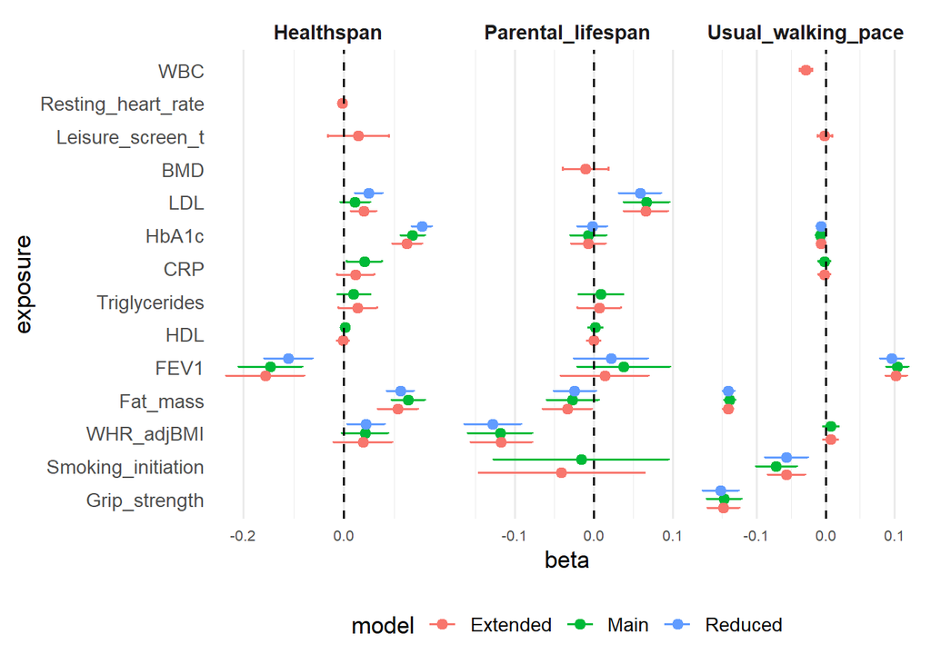

```r
############################################################
# 🔷 FOREST PLOT
############################################################
plot_df <- comparison %>%
  dplyr::select(
    exposure, outcome,
    beta_main, se_main,
    beta_ext, se_ext,
    beta_red, se_red
  ) %>%
  pivot_longer(cols = starts_with("beta"),
               names_to = "model", values_to = "beta") %>%
  mutate(
    se = case_when(
      model == "beta_main" ~ se_main,
      model == "beta_ext"  ~ se_ext,
      TRUE ~ se_red
    ),
    model = recode(model,
                   beta_main = "Main",
                   beta_ext  = "Extended",
                   beta_red  = "Reduced")
  ) %>%
  filter(!is.na(beta)) %>%
  group_by(exposure) %>%
  mutate(order_val = mean(beta[model == "Main"], na.rm = TRUE)) %>%
  ungroup() %>%
  mutate(exposure = reorder(exposure, order_val))

ggplot(plot_df, aes(x = beta, y = exposure, color = model)) +
  geom_point(position = position_dodge(0.8), size = 2.3) +
  geom_errorbar(
    aes(xmin = beta - 1.96*se, xmax = beta + 1.96*se),
    position = position_dodge(0.8),
    width = 0.12
  ) +
  facet_wrap(~ outcome, scales = "free_x", nrow = 1,
             labeller = label_wrap_gen(12)) +
  geom_vline(xintercept = 0, linetype = "dashed") +
  scale_x_continuous(breaks = pretty_breaks(3)) +
  theme_minimal(base_size = 13) +
  theme(
    strip.text = element_text(size = 11, face = "bold"),
    axis.text.x = element_text(size = 8),
    panel.grid.major.y = element_blank(),
    legend.position = "bottom"
  )
```

```r
############################################################
# 🔷 F-STATS TABLE
############################################################
f_main <- readRDS(file.path(out_dir, "mvmr_fstats_final.rds")) %>% rename(F_main = F_stat)
f_ext  <- readRDS(file.path(out_dir, "mvmr_fstats_extended.rds")) %>% rename(F_ext = F_stat)
f_red  <- readRDS(file.path(out_dir, "mvmr_fstats_reduced.rds")) %>% rename(F_red = F_stat)

f_comparison <- f_main %>%
  left_join(f_ext, by = c("exposure","outcome")) %>%
  left_join(f_red, by = c("exposure","outcome"))

f_comparison %>%
  mutate(
    n_weak = rowSums(across(starts_with("F_"), ~ .x < 10), na.rm = TRUE),
    weak_flag = ifelse(n_weak > 0, "⚠", "✔"),
    across(starts_with("F_"), ~ round(.x, 2))
  ) %>%
  kable(format = "html", escape = FALSE) %>%
  kable_styling(full_width = FALSE)
```

| exposure | F_main | outcome | F_ext | F_red | n_weak | weak_flag |
| --- | --- | --- | --- | --- | --- | --- |
| Fat_mass | 17.01 | Healthspan | 14.91 | 21.58 | 0 | ✔ |
| WHR_adjBMI | 16.25 | Healthspan | 12.66 | 22.31 | 0 | ✔ |
| LDL | 60.78 | Healthspan | 70.78 | 56.26 | 0 | ✔ |
| HDL | 57.96 | Healthspan | 49.86 | NA | 0 | ✔ |
| HbA1c | 29.02 | Healthspan | 26.34 | 37.92 | 0 | ✔ |
| FEV1 | 10.34 | Healthspan | 9.13 | 15.49 | 1 | ⚠ |
| Triglycerides | 50.36 | Healthspan | 41.68 | NA | 0 | ✔ |
| CRP | 22.48 | Healthspan | 15.35 | NA | 0 | ✔ |
| Fat_mass | 11.42 | Parental_lifespan | 10.66 | 21.09 | 0 | ✔ |
| WHR_adjBMI | 17.01 | Parental_lifespan | 15.75 | 22.13 | 0 | ✔ |
| LDL | 46.97 | Parental_lifespan | 41.89 | 56.80 | 0 | ✔ |
| HDL | 57.86 | Parental_lifespan | 49.51 | NA | 0 | ✔ |
| HbA1c | 28.20 | Parental_lifespan | 25.79 | 38.53 | 0 | ✔ |
| FEV1 | 9.93 | Parental_lifespan | 9.29 | 15.58 | 2 | ⚠ |
| Triglycerides | 52.25 | Parental_lifespan | 46.76 | NA | 0 | ✔ |
| Smoking_initiation | 2.46 | Parental_lifespan | 2.35 | NA | 2 | ⚠ |
| Grip_strength | 5.56 | Usual_walking_pace | 5.10 | 6.36 | 3 | ⚠ |
| Fat_mass | 11.57 | Usual_walking_pace | 11.05 | 14.51 | 0 | ✔ |
| FEV1 | 6.79 | Usual_walking_pace | 6.29 | 7.80 | 3 | ⚠ |
| Smoking_initiation | 2.96 | Usual_walking_pace | 2.77 | 3.41 | 3 | ⚠ |
| HbA1c | 29.46 | Usual_walking_pace | 25.73 | 37.41 | 0 | ✔ |
| WHR_adjBMI | 19.46 | Usual_walking_pace | 17.29 | NA | 0 | ✔ |
| CRP | 28.35 | Usual_walking_pace | 13.13 | NA | 0 | ✔ |

```r
############################################################
# 🔷 QC TABLES
############################################################
qc_main_info  <- readRDS(file.path(out_dir, "mvmr_snp_info.rds"))
qc_ext_info   <- readRDS(file.path(out_dir, "mvmr_snp_info_extended.rds"))
qc_red_info   <- readRDS(file.path(out_dir, "mvmr_snp_info_reduced.rds"))

qc_info <- qc_main_info %>%
  rename(total_main = total_snps, clean_main = snps_after_cleaning) %>%
  left_join(qc_ext_info %>% rename(total_ext = total_snps, clean_ext = snps_after_cleaning), by="outcome") %>%
  left_join(qc_red_info %>% rename(total_red = total_snps, clean_red = snps_after_cleaning), by="outcome")

qc_info %>%
  kable(caption = "Instrument selection and QC") %>%
  kable_styling(full_width = FALSE)
```

Instrument selection and QC

| outcome | total_main | clean_main | total_ext | clean_ext | total_red | clean_red |
| --- | --- | --- | --- | --- | --- | --- |
| Healthspan | 3066 | 1415 | 3452 | 1034 | 1885 | 1723 |
| Parental_lifespan | 2862 | 1497 | 3410 | 1705 | 1885 | 1691 |
| Usual_walking_pace | 2011 | 1575 | 2503 | 1948 | 1442 | 1262 |

```r
############################################################
# 🔷 QC CONTRIBUTION
############################################################
qc_main_contrib <- readRDS(file.path(out_dir, "mvmr_snp_contribution.rds"))
qc_ext_contrib  <- readRDS(file.path(out_dir, "mvmr_snp_contribution_extended.rds"))
qc_red_contrib  <- readRDS(file.path(out_dir, "mvmr_snp_contribution_reduced.rds"))

qc_contrib <- qc_main_contrib %>%
  rename(snp_main = snp_count) %>%
  full_join(qc_ext_contrib %>% rename(snp_ext = snp_count),
            by = c("exposure","outcome")) %>%
  full_join(qc_red_contrib %>% rename(snp_red = snp_count),
            by = c("exposure","outcome")) %>%
  dplyr::select(exposure, outcome, snp_red, snp_main, snp_ext)

qc_contrib %>%
  kable(caption = "SNP contribution") %>%
  kable_styling(full_width = FALSE)
```

SNP contribution

| exposure | outcome | snp_red | snp_main | snp_ext |
| --- | --- | --- | --- | --- |
| Fat_mass | Healthspan | 479 | 479 | 479 |
| WHR_adjBMI | Healthspan | 313 | 313 | 313 |
| LDL | Healthspan | 376 | 376 | 376 |
| HDL | Healthspan | NA | 532 | 532 |
| HbA1c | Healthspan | 414 | 414 | 414 |
| FEV1 | Healthspan | 323 | 323 | 323 |
| Triglycerides | Healthspan | NA | 447 | 447 |
| CRP | Healthspan | NA | 264 | 264 |
| Fat_mass | Parental_lifespan | 479 | 479 | 479 |
| WHR_adjBMI | Parental_lifespan | 313 | 313 | 313 |
| LDL | Parental_lifespan | 376 | 376 | 376 |
| HDL | Parental_lifespan | NA | 532 | 532 |
| HbA1c | Parental_lifespan | 414 | 414 | 414 |
| FEV1 | Parental_lifespan | 323 | 323 | 323 |
| Triglycerides | Parental_lifespan | NA | 447 | 447 |
| Smoking_initiation | Parental_lifespan | NA | 47 | 47 |
| Grip_strength | Usual_walking_pace | 193 | 193 | 193 |
| Fat_mass | Usual_walking_pace | 479 | 479 | 479 |
| FEV1 | Usual_walking_pace | 323 | 323 | 323 |
| Smoking_initiation | Usual_walking_pace | 47 | 47 | 47 |
| HbA1c | Usual_walking_pace | 414 | 414 | 414 |
| WHR_adjBMI | Usual_walking_pace | NA | 313 | 313 |
| CRP | Usual_walking_pace | NA | 264 | 264 |
| Leisure_screen_t | Healthspan | NA | NA | 114 |
| Resting_heart_rate | Healthspan | NA | NA | 276 |
| BMD | Parental_lifespan | NA | NA | 554 |
| Leisure_screen_t | Usual_walking_pace | NA | NA | 114 |
| WBC | Usual_walking_pace | NA | NA | 387 |

```r
############################################################
# 🔷 SAVE
############################################################
write.csv(qc_info, file.path(out_dir, "table_qc_info.csv"), row.names = FALSE)
write.csv(qc_contrib, file.path(out_dir, "table_qc_contribution.csv"), row.names = FALSE)
```

## 16.5 MVMR System Level

```r
############################################################
# 🔷 SYSTEM-LEVEL MULTIVARIABLE MENDELIAN RANDOMIZATION (MVMR)
# FULL PIPELINE — ROBUST & PAPER-READY
############################################################

library(data.table)
library(dplyr)
library(MendelianRandomization)
library(MVMR)
library(tibble)

set.seed(123)

#------------------------------------------------------------
# PATHS
#------------------------------------------------------------
base_dir   <- "C:/Users/75118/Desktop/UEA/Proyecto 1"
mapped_dir <- file.path(base_dir, "mapped_full_traits")
clump_dir  <- file.path(base_dir, "clumped_instruments")


#------------------------------------------------------------
# OUTPUT DIRECTORY (MVMR)
#------------------------------------------------------------
out_dir <- "C:/Users/75118/Desktop/UEA/Proyecto 1/MVMR"

if (!dir.exists(out_dir)) {
  dir.create(out_dir, recursive = TRUE)
}


#------------------------------------------------------------
# STEP 1 — DETECT EXPOSURES FROM FILES
#------------------------------------------------------------
mapped_files <- list.files(mapped_dir, pattern = "mapped_full_.*\\.rds")
exposures_all <- gsub("mapped_full_|\\.rds", "", mapped_files)

clump_files <- list.files(clump_dir, pattern = "clumped_.*\\.rds")
exposures_clumped <- gsub("clumped_|\\.rds", "", clump_files)

# Keep only exposures present in BOTH folders
exposures <- intersect(exposures_all, exposures_clumped)
exposures <- trimws(exposures)

#------------------------------------------------------------
# STEP 2 — SYSTEM MAP (MATCH EXACT FILE NAMES)
#------------------------------------------------------------
system_map <- tibble(
  exposure = exposures,
  system = case_when(

    # Metabolic
    exposure %in% c(
      "BMI","WHR_adjBMI","WC_adjBMI",
      "Fat_mass","Fat_free_mass","VAT",
      "Triglycerides","LDL","HDL","HbA1c"
    ) ~ "Metabolic",

    # Inflammatory
    exposure %in% c("CRP","WBC") ~ "Inflammatory",

    # Cardiorespiratory
    exposure %in% c(
      "CRF_VO2max","CRF_slope",
      "Resting_heart_rate","FEV1"
    ) ~ "Cardiorespiratory",

    # Physical function
    exposure %in% c("Grip_strength") ~ "Physical function",

    # Activity & lifestyle
    exposure %in% c(
      "Acc_total_log","Acc_LIPA","Acc_MVPA",
      "Acc_L5_inactivity","Acc_relative_amplitude",
      "Self_MVPA","Leisure_Screen_t",
      "Walking_time","Walking_days",
      "Chronotype","Smoking_initiation",
      "Sugar_intake"
    ) ~ "Activity & lifestyle",

    # Skeletal
    exposure %in% c("BMD") ~ "Skeletal",

    TRUE ~ NA_character_
  )
)

system_map <- system_map %>% filter(!is.na(system))

#------------------------------------------------------------
# STEP 3 — BUILD SYSTEM SETS
#------------------------------------------------------------
mvmr_sets_system <- split(system_map$exposure, system_map$system)

cat("\n🔎 Systems detected:\n")
print(mvmr_sets_system)

#------------------------------------------------------------
# HELPERS
#------------------------------------------------------------
load_trait <- function(trait) {
  readRDS(file.path(mapped_dir, paste0("mapped_full_", trait, ".rds")))
}

compute_p <- function(df) {
  df$P <- 2 * pnorm(-abs(df$BETA / df$SE))
  df
}

load_clumped_snps <- function(trait) {
  df <- readRDS(file.path(clump_dir, paste0("clumped_", trait, ".rds")))
  unique(df$SNP)
}

#------------------------------------------------------------
# STORAGE
#------------------------------------------------------------
mvmr_results <- list()
mvmr_fstats  <- list()
mvmr_pleio   <- list()
mvmr_snp_info <- list()
mvmr_snp_contribution <- list()

k <- 1

#------------------------------------------------------------
# OUTCOMES
#------------------------------------------------------------
outcomes <- c("Healthspan", "Parental_lifespan", "Usual_walking_pace")

#============================================================
# 🔁 MAIN LOOP — SYSTEM LEVEL
#============================================================
for (system in names(mvmr_sets_system)) {

  exposures <- mvmr_sets_system[[system]]

  if (length(exposures) < 2) {
    cat("Skipping", system, "- too few exposures\n")
    next
  }

  for (out in outcomes) {

    cat("\n==============================\n")
    cat("System:", system, "| Outcome:", out, "\n")

    #----------------------------------------------------------
    # SNP SELECTION
    #----------------------------------------------------------
    snp_list <- lapply(exposures, function(tr) {

      snps <- load_clumped_snps(tr)
      df   <- load_trait(tr)

      df <- df[df$SNP %in% snps, ]
      df <- compute_p(df)
      df <- df[df$P < 5e-8, ]

      df$SNP
    })

    names(snp_list) <- exposures

    # UNION of SNPs
    common_snps <- unique(unlist(snp_list))
    total_snps  <- length(common_snps)

    cat("Total SNPs:", total_snps, "\n")

    if (total_snps < 30) {
      cat("⚠ Skipping - too few SNPs\n")
      next
    }

    #----------------------------------------------------------
    # SNP CONTRIBUTION
    #----------------------------------------------------------
    contrib_vec <- sapply(exposures, function(tr) {
      sum(common_snps %in% snp_list[[tr]])
    })

    #----------------------------------------------------------
    # BUILD MATRICES
    #----------------------------------------------------------
    BXG <- sapply(exposures, function(tr) {
      df <- load_trait(tr)
      df <- df[df$SNP %in% common_snps, ]
      df$BETA[match(common_snps, df$SNP)]
    })

    BXG_se <- sapply(exposures, function(tr) {
      df <- load_trait(tr)
      df <- df[df$SNP %in% common_snps, ]
      df$SE[match(common_snps, df$SNP)]
    })

    out_df <- load_trait(out)
    out_df <- out_df[out_df$SNP %in% common_snps, ]

    BYG    <- out_df$BETA[match(common_snps, out_df$SNP)]
    BYG_se <- out_df$SE[match(common_snps, out_df$SNP)]

    #----------------------------------------------------------
    # CLEAN
    #----------------------------------------------------------
    keep <- complete.cases(BXG, BXG_se, BYG, BYG_se)

    BXG <- BXG[keep, , drop = FALSE]
    BXG_se <- BXG_se[keep, , drop = FALSE]
    BYG <- BYG[keep]
    BYG_se <- BYG_se[keep]

    if (length(BYG) < 30) next

    #----------------------------------------------------------
    # FORMAT
    #----------------------------------------------------------
    mvmr_formatted <- MVMR::format_mvmr(
      BXGs = BXG,
      BYG = BYG,
      seBXGs = BXG_se,
      seBYG = BYG_se
    )

    #----------------------------------------------------------
    # F-STATS (SAFE)
    #----------------------------------------------------------
    strength <- MVMR::strength_mvmr(mvmr_formatted)

    tmp <- capture.output(strength)
    f_line <- tmp[grep("F-statistic", tmp)]

    F_vals <- tryCatch({
      vals <- as.numeric(unlist(regmatches(
        f_line,
        gregexpr("[0-9]+\\.?[0-9]*", f_line)
      )))
      if (length(vals) >= length(exposures)) {
        vals[1:length(exposures)]
      } else {
        rep(NA, length(exposures))
      }
    }, error = function(e) rep(NA, length(exposures)))

    if (any(F_vals < 10, na.rm = TRUE)) {
      cat("⚠ Weak instruments detected\n")
    }

    #----------------------------------------------------------
    # PLEIOTROPY
    #----------------------------------------------------------
    pleio <- tryCatch(
      MVMR::pleiotropy_mvmr(mvmr_formatted),
      error = function(e) NULL
    )

    #----------------------------------------------------------
    # MODEL
    #----------------------------------------------------------
    mvmr_input <- MendelianRandomization::mr_mvinput(
      bx = BXG,
      bxse = BXG_se,
      by = BYG,
      byse = BYG_se
    )

    res <- MendelianRandomization::mr_mvivw(mvmr_input)

    #----------------------------------------------------------
    # SAVE
    #----------------------------------------------------------
    mvmr_results[[k]] <- data.frame(
      exposure = exposures,
      beta = as.numeric(res@Estimate),
      se   = as.numeric(res@StdError),
      p    = 2 * pnorm(-abs(as.numeric(res@Estimate) / as.numeric(res@StdError))),
      outcome = out,
      system = system
    )

    mvmr_fstats[[k]] <- data.frame(
      exposure = exposures,
      F_stat = F_vals,
      outcome = out,
      system = system
    )

    mvmr_pleio[[k]] <- data.frame(
      outcome = out,
      system = system,
      pleiotropy_stat = ifelse(is.null(pleio), NA, pleio$Qstat),
      pleiotropy_p = ifelse(is.null(pleio), NA, pleio$Qpval)
    )

    mvmr_snp_info[[k]] <- data.frame(
      outcome = out,
      system = system,
      total_snps = total_snps,
      snps_after_cleaning = length(BYG)
    )

    mvmr_snp_contribution[[k]] <- data.frame(
      exposure = exposures,
      snp_count = contrib_vec,
      outcome = out,
      system = system
    )

    k <- k + 1
    gc(FALSE)
  }
}

#------------------------------------------------------------
# FINAL OUTPUTS
#------------------------------------------------------------
mvmr_results <- bind_rows(mvmr_results) %>%
  arrange(system, outcome, p)

mvmr_fstats  <- bind_rows(mvmr_fstats)
mvmr_pleio   <- bind_rows(mvmr_pleio)
mvmr_snp_info <- bind_rows(mvmr_snp_info)
mvmr_snp_contribution <- bind_rows(mvmr_snp_contribution)

print(mvmr_results)

#------------------------------------------------------------
# SAVE
#------------------------------------------------------------
saveRDS(mvmr_results, file.path(out_dir, "mvmr_results_system.rds"))
saveRDS(mvmr_fstats,  file.path(out_dir, "mvmr_fstats_system.rds"))
saveRDS(mvmr_pleio,   file.path(out_dir, "mvmr_pleiotropy_system.rds"))
saveRDS(mvmr_snp_info, file.path(out_dir, "mvmr_snp_info_system.rds"))
saveRDS(mvmr_snp_contribution, file.path(out_dir, "mvmr_snp_contribution_system.rds"))

cat("\n📁 Files saved to:", out_dir, "\n")
cat("\n✅ SYSTEM-LEVEL MVMR COMPLETED (FINAL)\n")
```

## 16.6 Visualization of MVMR System Level Results

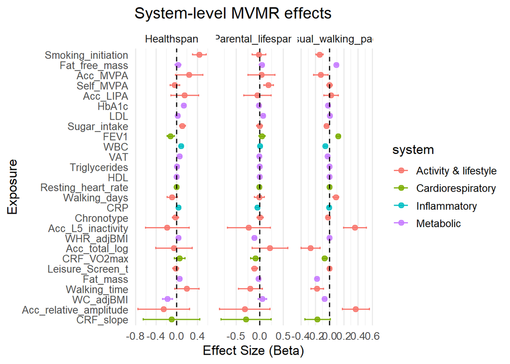

```r
############################################################
# 🔷 SYSTEM-LEVEL MVMR — FINAL CLEAN VERSION
############################################################

library(dplyr)
library(ggplot2)
library(tidyr)
library(knitr)
library(kableExtra)

#------------------------------------------------------------
# LOAD DATA
#------------------------------------------------------------
res_sys    <- readRDS(file.path(out_dir, "mvmr_results_system.rds"))
fstats_sys <- readRDS(file.path(out_dir, "mvmr_fstats_system.rds"))
pleio_sys  <- readRDS(file.path(out_dir, "mvmr_pleiotropy_system.rds"))

qc_info_sys    <- readRDS(file.path(out_dir, "mvmr_snp_info_system.rds"))
qc_contrib_sys <- readRDS(file.path(out_dir, "mvmr_snp_contribution_system.rds"))

############################################################
# 🔷 1️⃣ FOREST PLOT (IMPROVED)
############################################################

p1_sys <- ggplot(res_sys,
                 aes(x = beta,
                     y = reorder(exposure, beta),
                     color = system)) +

  geom_point(size = 2.3, alpha = 0.85) +

  geom_errorbarh(
    aes(xmin = beta - 1.96*se,
        xmax = beta + 1.96*se),
    height = 0.2
  ) +

  facet_wrap(~ outcome, scales = "free_x") +

  geom_vline(xintercept = 0, linetype = "dashed") +

  theme_minimal(base_size = 13) +

  theme(
    legend.position = "right",
    axis.text.y = element_text(size = 10),
    panel.grid.major.y = element_blank()
  ) +

  labs(
    title = "System-level MVMR effects",
    x = "Effect Size (Beta)",
    y = "Exposure"
  )

print(p1_sys)
```

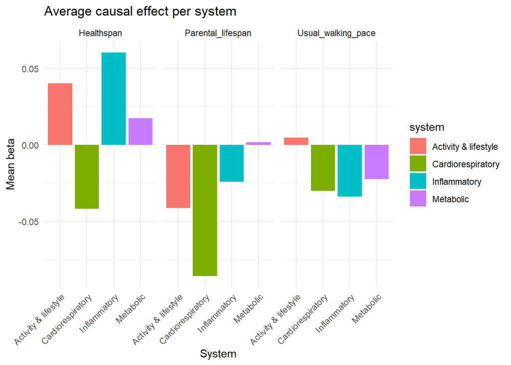

```r
############################################################
# 🔷 2️⃣ SYSTEM SUMMARY (KEEP 🔥)
############################################################

system_summary <- res_sys %>%
  group_by(system, outcome) %>%
  summarise(mean_beta = mean(beta), .groups = "drop")

p2_sys <- ggplot(system_summary,
                 aes(system, mean_beta, fill = system)) +

  geom_col() +

  facet_wrap(~ outcome) +

  theme_minimal() +

  theme(axis.text.x = element_text(angle = 45, hjust = 1)) +

  labs(
    title = "Average causal effect per system",
    y = "Mean beta",
    x = "System"
  )

print(p2_sys)
```

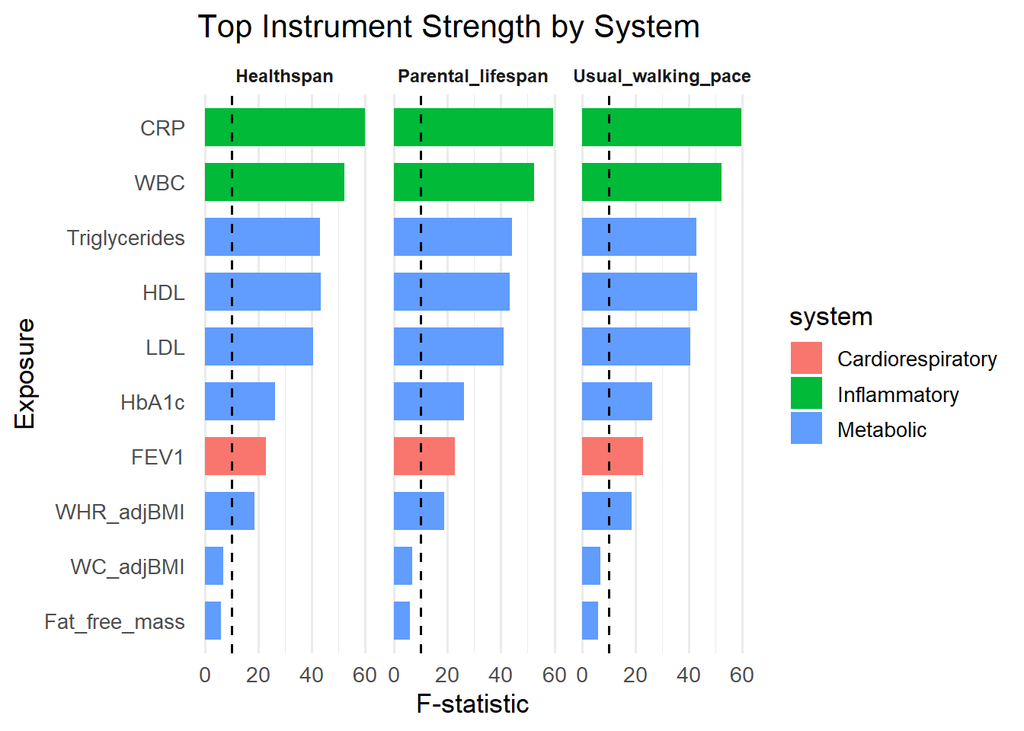

```r
############################################################
# 🔷 3️⃣ F-STATISTICS (TOP 10 — CLEAN)
############################################################

p3_sys <- fstats_sys %>%

  group_by(outcome) %>%
  slice_max(F_stat, n = 10) %>%
  ungroup() %>%

  mutate(exposure = reorder(exposure, F_stat)) %>%

  ggplot(aes(x = F_stat, y = exposure, fill = system)) +

  geom_col(width = 0.7) +

  geom_vline(xintercept = 10, linetype = "dashed") +

  facet_wrap(~ outcome, scales = "free_x", nrow = 1) +

  theme_minimal(base_size = 13) +

  theme(
    legend.position = "right",
    strip.text = element_text(face = "bold", size = 9),
    panel.grid.major.y = element_blank()
  ) +

  labs(
    title = "Top Instrument Strength by System",
    x = "F-statistic",
    y = "Exposure"
  )

print(p3_sys)
```

```r
############################################################
# 🔷 4️⃣ WEAK INSTRUMENT TABLE
############################################################

fstats_flag <- fstats_sys %>%
  mutate(weak = F_stat < 10) %>%
  arrange(outcome, system, desc(F_stat))

fstats_flag %>%
  kable(caption = "System-level F-statistics") %>%
  kable_styling(full_width = FALSE)
```

System-level F-statistics

| exposure | F_stat | outcome | system | weak |
| --- | --- | --- | --- | --- |
| Leisure_Screen_t | 3.5090090 | Healthspan | Activity & lifestyle | TRUE |
| Self_MVPA | 2.5168940 | Healthspan | Activity & lifestyle | TRUE |
| Sugar_intake | 2.3069880 | Healthspan | Activity & lifestyle | TRUE |
| Smoking_initiation | 1.7186540 | Healthspan | Activity & lifestyle | TRUE |
| Chronotype | 1.5981500 | Healthspan | Activity & lifestyle | TRUE |
| Walking_days | 1.5164660 | Healthspan | Activity & lifestyle | TRUE |
| Walking_time | 1.0701310 | Healthspan | Activity & lifestyle | TRUE |
| Acc_total_log | 0.0912379 | Healthspan | Activity & lifestyle | TRUE |
| Acc_LIPA | 0.0906143 | Healthspan | Activity & lifestyle | TRUE |
| Acc_MVPA | 0.0848774 | Healthspan | Activity & lifestyle | TRUE |
| Acc_relative_amplitude | 0.0468510 | Healthspan | Activity & lifestyle | TRUE |
| Acc_L5_inactivity | 0.0464705 | Healthspan | Activity & lifestyle | TRUE |
| FEV1 | 22.7358000 | Healthspan | Cardiorespiratory | FALSE |
| Resting_heart_rate | 1.2298790 | Healthspan | Cardiorespiratory | TRUE |
| CRF_VO2max | 0.8109194 | Healthspan | Cardiorespiratory | TRUE |
| CRF_slope | 0.7595151 | Healthspan | Cardiorespiratory | TRUE |
| CRP | 59.7980000 | Healthspan | Inflammatory | FALSE |
| WBC | 52.2160500 | Healthspan | Inflammatory | FALSE |
| HDL | 43.3544300 | Healthspan | Metabolic | FALSE |
| Triglycerides | 43.0410100 | Healthspan | Metabolic | FALSE |
| LDL | 40.5309100 | Healthspan | Metabolic | FALSE |
| HbA1c | 26.1059500 | Healthspan | Metabolic | FALSE |
| WHR_adjBMI | 18.5631800 | Healthspan | Metabolic | FALSE |
| WC_adjBMI | 6.7474370 | Healthspan | Metabolic | TRUE |
| Fat_free_mass | 5.9513230 | Healthspan | Metabolic | TRUE |
| Fat_mass | 4.0990700 | Healthspan | Metabolic | TRUE |
| VAT | 1.3333290 | Healthspan | Metabolic | TRUE |
| Leisure_Screen_t | 3.2190120 | Parental_lifespan | Activity & lifestyle | TRUE |
| Sugar_intake | 2.5006470 | Parental_lifespan | Activity & lifestyle | TRUE |
| Self_MVPA | 2.4849530 | Parental_lifespan | Activity & lifestyle | TRUE |

[output cut: 51 more lines]

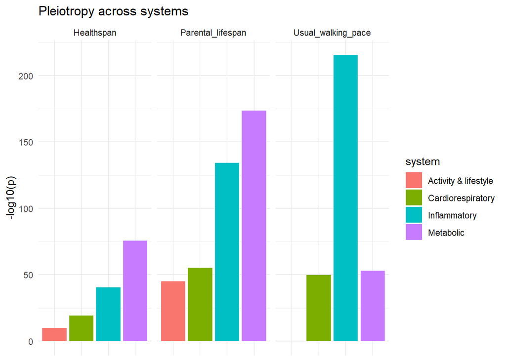

```r
############################################################
# 🔷 5️⃣ PLEIOTROPY (CLEAN)
############################################################

p4_sys <- ggplot(pleio_sys,
                 aes(system, -log10(pleiotropy_p), fill = system)) +

  geom_col() +

  facet_wrap(~ outcome) +

  theme_minimal() +

  theme(
    axis.text.x = element_blank(),
    axis.ticks.x = element_blank()
  ) +

  labs(
    title = "Pleiotropy across systems",
    y = "-log10(p)",
    x = NULL
  )

print(p4_sys)
```

```r
############################################################
# 🔷 6️⃣ QC TABLE
############################################################

qc_table_sys <- qc_info_sys %>%
  mutate(
    total_snps = round(total_snps),
    snps_after_cleaning = round(snps_after_cleaning)
  )

qc_table_sys %>%
  kable(caption = "Instrument selection per system") %>%
  kable_styling(full_width = FALSE)
```

Instrument selection per system

| outcome | system | total_snps | snps_after_cleaning |
| --- | --- | --- | --- |
| Healthspan | Activity & lifestyle | 390 | 367 |
| Parental_lifespan | Activity & lifestyle | 390 | 358 |
| Usual_walking_pace | Activity & lifestyle | 390 | 367 |
| Healthspan | Cardiorespiratory | 611 | 474 |
| Parental_lifespan | Cardiorespiratory | 611 | 468 |
| Usual_walking_pace | Cardiorespiratory | 611 | 474 |
| Healthspan | Inflammatory | 649 | 558 |
| Parental_lifespan | Inflammatory | 649 | 551 |
| Usual_walking_pace | Inflammatory | 649 | 559 |
| Healthspan | Metabolic | 3289 | 1752 |
| Parental_lifespan | Metabolic | 3289 | 1725 |
| Usual_walking_pace | Metabolic | 3289 | 1759 |

```r
############################################################
# 🔷 7️⃣ QC CONTRIBUTION (FIXED CLEAN)
############################################################

qc_contrib_sys_clean <- qc_contrib_sys %>%
  mutate(
    exposure = gsub("\\.\\.\\.[0-9]+$", "", exposure)
  ) %>%
  arrange(outcome, system, desc(snp_count))

qc_contrib_sys_clean %>%
  kable(caption = "SNP contribution per exposure") %>%
  kable_styling(full_width = FALSE)
```

SNP contribution per exposure

|  | exposure | snp_count | outcome | system |
| --- | --- | --- | --- | --- |
| Chronotype…1 | Chronotype | 154 | Healthspan | Activity & lifestyle |
| Leisure_Screen_t…2 | Leisure_Screen_t | 114 | Healthspan | Activity & lifestyle |
| Smoking_initiation…3 | Smoking_initiation | 47 | Healthspan | Activity & lifestyle |
| Sugar_intake…4 | Sugar_intake | 21 | Healthspan | Activity & lifestyle |
| Self_MVPA…5 | Self_MVPA | 18 | Healthspan | Activity & lifestyle |
| Walking_days…6 | Walking_days | 15 | Healthspan | Activity & lifestyle |
| Acc_total_log…7 | Acc_total_log | 9 | Healthspan | Activity & lifestyle |
| Walking_time…8 | Walking_time | 5 | Healthspan | Activity & lifestyle |
| Acc_LIPA…9 | Acc_LIPA | 4 | Healthspan | Activity & lifestyle |
| Acc_relative_amplitude…10 | Acc_relative_amplitude | 4 | Healthspan | Activity & lifestyle |
| Acc_L5_inactivity…11 | Acc_L5_inactivity | 3 | Healthspan | Activity & lifestyle |
| Acc_MVPA…12 | Acc_MVPA | 1 | Healthspan | Activity & lifestyle |
| FEV1…13 | FEV1 | 323 | Healthspan | Cardiorespiratory |
| Resting_heart_rate…14 | Resting_heart_rate | 276 | Healthspan | Cardiorespiratory |
| CRF_VO2max…15 | CRF_VO2max | 9 | Healthspan | Cardiorespiratory |
| CRF_slope…16 | CRF_slope | 6 | Healthspan | Cardiorespiratory |
| WBC…17 | WBC | 387 | Healthspan | Inflammatory |
| CRP…18 | CRP | 264 | Healthspan | Inflammatory |
| Fat_free_mass…19 | Fat_free_mass | 584 | Healthspan | Metabolic |
| HDL…20 | HDL | 532 | Healthspan | Metabolic |
| Fat_mass…21 | Fat_mass | 479 | Healthspan | Metabolic |
| Triglycerides…22 | Triglycerides | 447 | Healthspan | Metabolic |
| HbA1c…23 | HbA1c | 414 | Healthspan | Metabolic |
| LDL…24 | LDL | 376 | Healthspan | Metabolic |
| WHR_adjBMI…25 | WHR_adjBMI | 313 | Healthspan | Metabolic |
| WC_adjBMI…26 | WC_adjBMI | 263 | Healthspan | Metabolic |
| VAT…27 | VAT | 5 | Healthspan | Metabolic |
| Chronotype…28 | Chronotype | 154 | Parental_lifespan | Activity & lifestyle |
| Leisure_Screen_t…29 | Leisure_Screen_t | 114 | Parental_lifespan | Activity & lifestyle |
| Smoking_initiation…30 | Smoking_initiation | 47 | Parental_lifespan | Activity & lifestyle |

[output cut: 51 more lines]

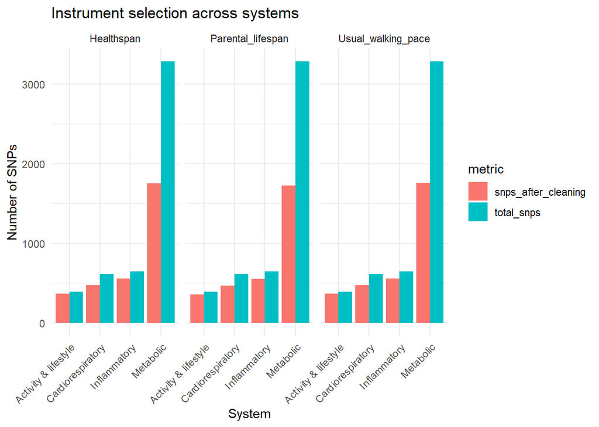

```r
############################################################
# 🔷 8️⃣ QC PLOT
############################################################

qc_long_sys <- qc_info_sys %>%
  pivot_longer(
    cols = c(total_snps, snps_after_cleaning),
    names_to = "metric",
    values_to = "value"
  )

ggplot(qc_long_sys,
       aes(x = system, y = value, fill = metric)) +

  geom_col(position = "dodge") +

  facet_wrap(~ outcome) +

  theme_minimal() +

  theme(
    axis.text.x = element_text(angle = 45, hjust = 1)
  ) +

  labs(
    title = "Instrument selection across systems",
    y = "Number of SNPs",
    x = "System"
  )
```

```r
############################################################
# 🔷 9️⃣ FINAL TABLE (NO HTML BUGS)
############################################################

res_table_sys <- res_sys %>%
  mutate(
    beta = round(beta, 3),
    se   = round(se, 3),
    p_num = p,
    p = formatC(p, format = "f", digits = 4)
  ) %>%
  group_by(outcome, system) %>%
  arrange(desc(beta), .by_group = TRUE) %>%
  ungroup()

kable(res_table_sys,
      caption = "System-level MVMR estimates") %>%
  kable_styling(full_width = FALSE) %>%
  column_spec(
    which(colnames(res_table_sys) == "p"),
    bold = res_table_sys$p_num < 0.05
  )
```

System-level MVMR estimates

| exposure | beta | se | p | outcome | system | p_num |
| --- | --- | --- | --- | --- | --- | --- |
| Smoking_initiation | 0.438 | 0.068 | 0.0000 | Healthspan | Activity & lifestyle | 0.0000000 |
| Acc_MVPA | 0.240 | 0.136 | 0.0778 | Healthspan | Activity & lifestyle | 0.0778290 |
| Walking_time | 0.198 | 0.121 | 0.1016 | Healthspan | Activity & lifestyle | 0.1016207 |
| Acc_LIPA | 0.156 | 0.138 | 0.2596 | Healthspan | Activity & lifestyle | 0.2596226 |
| Sugar_intake | 0.111 | 0.030 | 0.0002 | Healthspan | Activity & lifestyle | 0.0001761 |
| Leisure_Screen_t | -0.018 | 0.028 | 0.5242 | Healthspan | Activity & lifestyle | 0.5241906 |
| Chronotype | -0.025 | 0.030 | 0.4066 | Healthspan | Activity & lifestyle | 0.4066258 |
| Self_MVPA | -0.037 | 0.048 | 0.4425 | Healthspan | Activity & lifestyle | 0.4425139 |
| Acc_total_log | -0.053 | 0.180 | 0.7694 | Healthspan | Activity & lifestyle | 0.7693601 |
| Walking_days | -0.091 | 0.051 | 0.0770 | Healthspan | Activity & lifestyle | 0.0769765 |
| Acc_L5_inactivity | -0.184 | 0.216 | 0.3956 | Healthspan | Activity & lifestyle | 0.3955794 |
| Acc_relative_amplitude | -0.253 | 0.257 | 0.3260 | Healthspan | Activity & lifestyle | 0.3260006 |
| CRF_VO2max | 0.054 | 0.053 | 0.3083 | Healthspan | Cardiorespiratory | 0.3083204 |
| Resting_heart_rate | -0.001 | 0.003 | 0.7889 | Healthspan | Cardiorespiratory | 0.7888583 |
| CRF_slope | -0.101 | 0.280 | 0.7178 | Healthspan | Cardiorespiratory | 0.7178013 |
| FEV1 | -0.119 | 0.035 | 0.0007 | Healthspan | Cardiorespiratory | 0.0006781 |
| WBC | 0.087 | 0.019 | 0.0000 | Healthspan | Inflammatory | 0.0000055 |
| CRP | 0.034 | 0.019 | 0.0680 | Healthspan | Inflammatory | 0.0680236 |
| HbA1c | 0.138 | 0.012 | 0.0000 | Healthspan | Metabolic | 0.0000000 |
| VAT | 0.059 | 0.020 | 0.0031 | Healthspan | Metabolic | 0.0030992 |
| Fat_mass | 0.057 | 0.023 | 0.0125 | Healthspan | Metabolic | 0.0125239 |
| WHR_adjBMI | 0.032 | 0.019 | 0.0970 | Healthspan | Metabolic | 0.0969503 |
| Fat_free_mass | 0.024 | 0.027 | 0.3767 | Healthspan | Metabolic | 0.3766577 |
| LDL | 0.022 | 0.015 | 0.1529 | Healthspan | Metabolic | 0.1529296 |
| Triglycerides | 0.006 | 0.015 | 0.6788 | Healthspan | Metabolic | 0.6787977 |
| HDL | -0.003 | 0.005 | 0.4909 | Healthspan | Metabolic | 0.4908806 |
| WC_adjBMI | -0.178 | 0.049 | 0.0003 | Healthspan | Metabolic | 0.0002503 |
| Acc_total_log | 0.214 | 0.192 | 0.2656 | Parental_lifespan | Activity & lifestyle | 0.2655618 |
| Self_MVPA | 0.186 | 0.052 | 0.0003 | Parental_lifespan | Activity & lifestyle | 0.0003178 |
| Acc_MVPA | 0.035 | 0.146 | 0.8100 | Parental_lifespan | Activity & lifestyle | 0.8100028 |

[output cut: 51 more lines]

```r
############################################################
# 🔷 SAVE
############################################################

ggsave(file.path(out_dir, "system_MVMR_forest.png"), p1_sys, width = 10, height = 6)
ggsave(file.path(out_dir, "system_summary.png"), p2_sys, width = 8, height = 5)
ggsave(file.path(out_dir, "system_fstats.png"), p3_sys, width = 10, height = 6)
ggsave(file.path(out_dir, "system_pleiotropy.png"), p4_sys, width = 8, height = 5)

write.csv(res_table_sys,
          file.path(out_dir, "table_system_mvmr_results.csv"),
          row.names = FALSE)

write.csv(fstats_flag,
          file.path(out_dir, "table_system_fstats.csv"),
          row.names = FALSE)

write.csv(qc_table_sys,
          file.path(out_dir, "table_system_qc_info.csv"),
          row.names = FALSE)

write.csv(qc_contrib_sys_clean,
          file.path(out_dir, "table_system_qc_contribution.csv"),
          row.names = FALSE)

cat("\n✅ SYSTEM-LEVEL ANALYSIS COMPLETE\n")
```

✅ SYSTEM-LEVEL ANALYSIS COMPLETE

# 18. Reduction of SNPs

The harmonized SNP × trait matrix is reduced using variability-based filtering to retain the most genetically informative variants for machine-learning analysis. SNPs are ranked by cross-trait effect size standard deviation, capturing pleiotropic signal strength and multi-trait genetic structure, and the top variants are standardized to produce a computationally efficient Elastic Net input matrix.

```r
###############################################
# SNP REDUCTION — Variability-Based Filtering #
# Applied to FINAL harmonised SNP × trait matrix
###############################################

#------------------------------------------------
# 1. Load final clean Elastic Net input matrix
#------------------------------------------------
# Rows = SNPs
# Columns = GWAS traits
# Already harmonised, ordered, and NA-free

X <- readRDS("X_elastic_net.rds")


#------------------------------------------------
# 2. Compute genetic variability per SNP
#------------------------------------------------
# Standard deviation across traits captures:
#  - multi-trait pleiotropic structure
#  - strength of genetic signal
#  - informative SNPs for Elastic Net

snp_sd <- apply(X, 1, sd)

# Optional sanity check
summary(snp_sd)
```

```
Min.  1st Qu.   Median     Mean  3rd Qu.     Max.
```

0.001673 0.006422 0.009749 0.012160 0.015086 0.433997

```r
#------------------------------------------------
# 3. Choose number of SNPs to retain
#------------------------------------------------
# Typical ranges in large-scale GWAS ML:
#  - 50k  (fast, conservative)
#  - 100k–200k (balanced, recommended)
#  - >200k (max signal, slower)

N <- 150000


#------------------------------------------------
# 4. Rank SNPs by information content
#------------------------------------------------
# Highest SD = strongest multi-trait variation

top_idx <- order(snp_sd, decreasing = TRUE)[1:N]


#------------------------------------------------
# 5. Subset SNP matrix to top informative variants
#------------------------------------------------

X_reduced <- X[top_idx, ]


#------------------------------------------------
# 6. Re-standardize predictors for Elastic Net
#------------------------------------------------
# (critical for regularization stability)

X_reduced <- scale(X_reduced)


#------------------------------------------------
# 7. Final dimension check
#------------------------------------------------
# Should be: N SNPs × number of traits

dim(X_reduced)
```

[1] 150000 32

```r
#------------------------------------------------
# 8. Save reduced matrix for modelling
#------------------------------------------------

saveRDS(X_reduced, "X_elastic_net_reduced_sd.rds")

cat("✅ SNP reduction complete — retained", N, "most informative variants\n")
```

✅ SNP reduction complete — retained 150000 most informative variants

# 19. Baseline predictor screening using SNP-level effect size correlations with aging outcomes

Shared genetic architecture between biological predictors and aging-related outcomes is assessed by computing SNP-level effect size correlations across the reduced variant set. Predictors are ranked by correlation strength to identify traits exhibiting the strongest pleiotropic alignment with each aging outcome.

```r
############################################################
#     Genetic correlation screening using SNP-level effects
#     (pleiotropy proxy across biological systems)
############################################################

# INPUT:
# X_reduced = SNP × trait effect matrix
# Rows      = SNPs
# Columns   = predictors + outcomes
# Already harmonised, ordered, standardized

library(dplyr)
library(ggplot2)
library(knitr)
library(kableExtra)

############################################################
# 0. Define outcomes and predictors
############################################################

# Aging outcomes (targets)
outcomes <- c(
  "Healthspan",
  "Parental_lifespan",
  "Usual_walking_pace"
)

# Everything else is a predictor
predictors <- setdiff(colnames(X_reduced), outcomes)

############################################################
# 1. Function to compute SNP-level genetic correlations
############################################################
# For each predictor:
#   cor( beta_SNP,predictor , beta_SNP,outcome )

run_trait_correlation <- function(outcome_name) {

  y <- X_reduced[, outcome_name]

  cor_results <- lapply(predictors, function(tr) {

    x <- X_reduced[, tr]

    ct <- cor.test(x, y)

    data.frame(
      Predictor   = tr,
      Correlation = unname(ct$estimate),
      P_value     = ct$p.value,
      stringsAsFactors = FALSE
    )
  })

  bind_rows(cor_results) %>%
    arrange(desc(abs(Correlation)))
}

############################################################
# 2. Run correlations for each aging outcome
############################################################

cor_results_all <- list()

cor_results_all[["Healthspan"]]         <- run_trait_correlation("Healthspan")
cor_results_all[["Parental_lifespan"]]  <- run_trait_correlation("Parental_lifespan")
cor_results_all[["Usual_walking_pace"]] <- run_trait_correlation("Usual_walking_pace")

############################################################
# 3. Helper to print collapsible result blocks (R Markdown)
############################################################

show_results_block <- function(df, outcome_label) {

  cat("\n\n<details>\n")
  cat("<summary><strong>", outcome_label,
      " — SNP-level genetic correlation screening</strong></summary>\n\n")

  # --------------------------------------------------------
  # Ranked correlation table
  # --------------------------------------------------------

  print(
    kbl(df, digits = 5) %>%
      kable_styling(full_width = FALSE) %>%
      scroll_box(height = "400px")
  )

  # --------------------------------------------------------
  # Strongest genetically aligned predictor
  # --------------------------------------------------------

  best_trait <- df$Predictor[1]

  cat("\n\n**Top genetically aligned predictor:** ", best_trait, "\n\n")

  # --------------------------------------------------------
  # Visualization
  # --------------------------------------------------------

  print(
    ggplot(df, aes(x = reorder(Predictor, Correlation),
                   y = Correlation)) +
      geom_col() +
      coord_flip() +
      theme_minimal(base_size = 12) +
      labs(
        title = paste("SNP-level genetic correlation with", outcome_label),
        x = "Predictor trait",
        y = "Correlation (β_predictor vs β_outcome)"
      )
  )

  cat("\n</details>\n")
}

############################################################
# 4. Display collapsible results (one per outcome)
############################################################

show_results_block(
  cor_results_all[["Healthspan"]],
  "Healthspan"
)
```

**Healthspan — SNP-level genetic correlation screening**

| Predictor | Correlation | P_value |
| --- | --- | --- |
| HbA1c | 0.16649 | 0.00000 |
| WBC | 0.15076 | 0.00000 |
| Fat_mass | 0.13520 | 0.00000 |
| FEV1 | -0.10286 | 0.00000 |
| Resting_heart_rate | -0.09702 | 0.00000 |
| Fat_free_mass | 0.07673 | 0.00000 |
| Triglycerides | 0.07625 | 0.00000 |
| Smoking_initiation | 0.07567 | 0.00000 |
| Grip_strength | 0.06500 | 0.00000 |
| WC_adjBMI | -0.06488 | 0.00000 |
| Acc_MVPA | 0.06392 | 0.00000 |
| Sugar_intake | 0.06101 | 0.00000 |
| VAT | 0.05704 | 0.00000 |
| Acc_total_log | 0.04631 | 0.00000 |
| CRF_VO2max | 0.04223 | 0.00000 |
| Acc_relative_amplitude | 0.03564 | 0.00000 |
| CRP | 0.02230 | 0.00000 |
| WHR_adjBMI | 0.02178 | 0.00000 |
| Leisure_Screen_t | 0.01881 | 0.00000 |
| LDL | 0.01745 | 0.00000 |
| Acc_LIPA | 0.01715 | 0.00000 |
| Self_MVPA | -0.01691 | 0.00000 |
| Chronotype | 0.01665 | 0.00000 |
| Walking_days | -0.01645 | 0.00000 |
| CRF_slope | 0.00914 | 0.00040 |
| HDL | -0.00829 | 0.00133 |
| Walking_time | -0.00748 | 0.00377 |
| Acc_L5_inactivity | -0.00421 | 0.10283 |
| BMD | -0.00390 | 0.13047 |

**Top genetically aligned predictor:** HbA1c

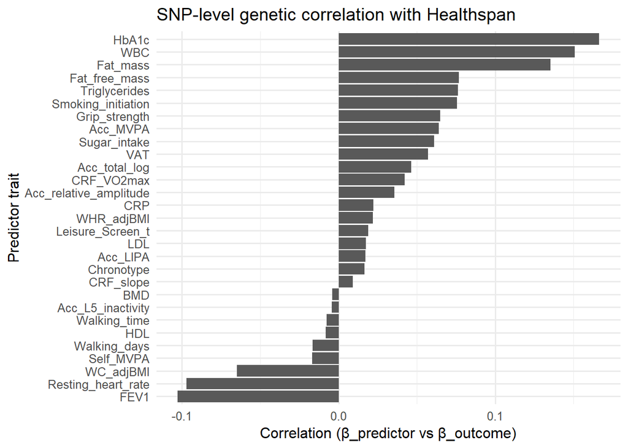

```r
show_results_block(
  cor_results_all[["Parental_lifespan"]],
  "Parental lifespan"
)
```

**Parental lifespan — SNP-level genetic correlation screening**

| Predictor | Correlation | P_value |
| --- | --- | --- |
| Leisure_Screen_t | -0.10569 | 0.00000 |
| CRP | -0.09431 | 0.00000 |
| Self_MVPA | 0.09358 | 0.00000 |
| WHR_adjBMI | -0.05901 | 0.00000 |
| LDL | -0.03145 | 0.00000 |
| Fat_mass | -0.02363 | 0.00000 |
| FEV1 | 0.01983 | 0.00000 |
| Triglycerides | -0.01699 | 0.00000 |
| WBC | -0.01667 | 0.00000 |
| Sugar_intake | -0.01552 | 0.00000 |
| VAT | -0.01540 | 0.00000 |
| Smoking_initiation | -0.01397 | 0.00000 |
| HbA1c | -0.01376 | 0.00000 |
| Acc_MVPA | -0.01332 | 0.00000 |
| Acc_total_log | -0.01250 | 0.00000 |
| Fat_free_mass | -0.01224 | 0.00000 |
| Grip_strength | -0.01060 | 0.00004 |
| Acc_relative_amplitude | -0.00602 | 0.01969 |
| Acc_LIPA | -0.00593 | 0.02155 |
| CRF_VO2max | -0.00548 | 0.03368 |
| Walking_days | -0.00524 | 0.04239 |
| Walking_time | -0.00402 | 0.11967 |
| WC_adjBMI | 0.00322 | 0.21170 |
| Acc_L5_inactivity | -0.00296 | 0.25175 |
| Resting_heart_rate | 0.00287 | 0.26648 |
| BMD | 0.00178 | 0.49062 |
| Chronotype | -0.00100 | 0.69994 |
| HDL | -0.00069 | 0.79062 |
| CRF_slope | -0.00025 | 0.92294 |

**Top genetically aligned predictor:** Leisure_Screen_t

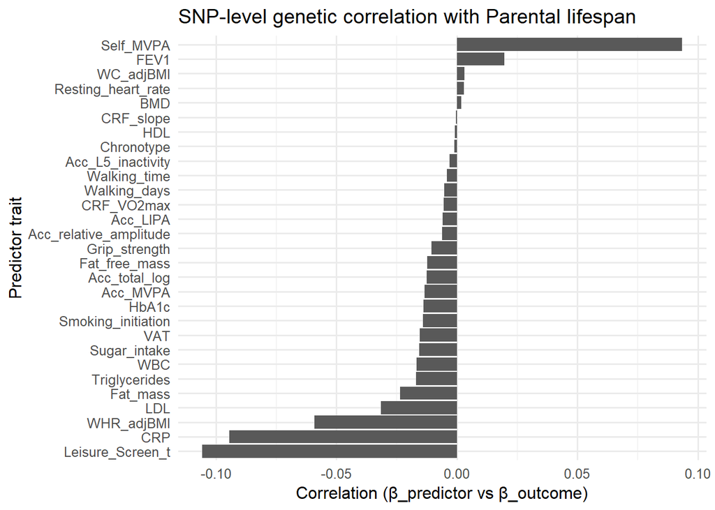

```r
show_results_block(
  cor_results_all[["Usual_walking_pace"]],
  "Usual walking pace"
)
```

**Usual walking pace — SNP-level genetic correlation screening**

| Predictor | Correlation | P_value |
| --- | --- | --- |
| Fat_mass | -0.37510 | 0.00000 |
| WBC | -0.25512 | 0.00000 |
| FEV1 | 0.24675 | 0.00000 |
| Grip_strength | -0.19805 | 0.00000 |
| Resting_heart_rate | 0.18331 | 0.00000 |
| HbA1c | -0.14953 | 0.00000 |
| Acc_MVPA | -0.14441 | 0.00000 |
| VAT | -0.13236 | 0.00000 |
| Triglycerides | -0.12587 | 0.00000 |
| CRF_VO2max | -0.12311 | 0.00000 |
| Walking_days | 0.12118 | 0.00000 |
| Fat_free_mass | -0.11502 | 0.00000 |
| Acc_total_log | -0.11363 | 0.00000 |
| Smoking_initiation | -0.11124 | 0.00000 |
| Acc_relative_amplitude | -0.09878 | 0.00000 |
| Chronotype | -0.06229 | 0.00000 |
| WC_adjBMI | 0.06163 | 0.00000 |
| CRP | -0.06066 | 0.00000 |
| Sugar_intake | -0.05868 | 0.00000 |
| Self_MVPA | 0.05054 | 0.00000 |
| Leisure_Screen_t | -0.04998 | 0.00000 |
| Acc_LIPA | -0.04487 | 0.00000 |
| WHR_adjBMI | -0.02923 | 0.00000 |
| Acc_L5_inactivity | 0.02550 | 0.00000 |
| Walking_time | 0.02043 | 0.00000 |
| BMD | -0.02036 | 0.00000 |
| LDL | -0.01665 | 0.00000 |
| HDL | 0.01116 | 0.00002 |
| CRF_slope | -0.00201 | 0.43615 |

**Top genetically aligned predictor:** Fat_mass

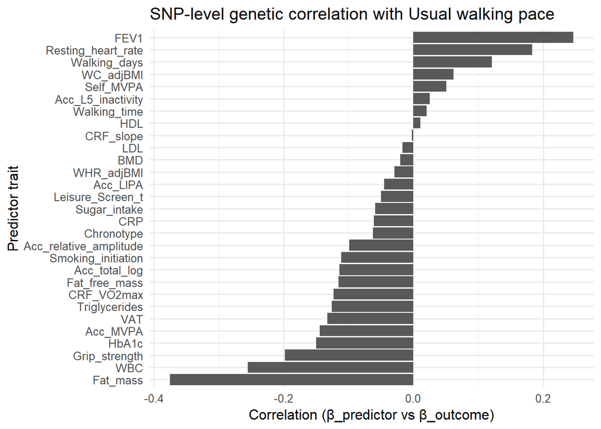

# 20. Baseline predictor screening using univariate SNP-level regression with aging outcomes

Each predictor’s SNP-level effects are regressed against aging outcome effects to quantify directional influence and explained variance. This provides a complementary measure of pleiotropic contribution strength and prioritizes predictors with the greatest genetic impact on aging traits.

```r
############################################################
#     Baseline predictor screening using SNP-level regression
#     (pleiotropy strength + variance explained)
############################################################

# INPUT:
# X_reduced = SNP × trait effect matrix
# Rows      = SNPs
# Columns   = predictors + outcomes
# Already harmonised, ordered, standardized

library(dplyr)
library(ggplot2)
library(knitr)
library(kableExtra)

############################################################
# 0. Define outcomes and predictors
############################################################

outcomes <- c(
  "Healthspan",
  "Parental_lifespan",
  "Usual_walking_pace"
)

predictors <- setdiff(colnames(X_reduced), outcomes)

############################################################
# 1. Function to run univariate regression for one outcome
############################################################

run_univariate_regression <- function(outcome_name) {

  y <- X_reduced[, outcome_name]

  reg_results <- lapply(predictors, function(pred) {

    x <- X_reduced[, pred]

    df <- data.frame(
      outcome   = y,
      predictor = x
    )

    fit <- lm(outcome ~ predictor, data = df)
    s   <- summary(fit)

    data.frame(
      Predictor = pred,
      Beta      = coef(fit)[2],
      P_value   = s$coefficients[2, 4],
      R2        = s$r.squared,
      Direction = ifelse(coef(fit)[2] > 0, "Positive", "Negative"),
      stringsAsFactors = FALSE
    )
  })

  bind_rows(reg_results) %>%
    arrange(desc(R2))
}

############################################################
# 2. Run regressions for each aging outcome
############################################################

reg_results_all <- list()

reg_results_all[["Healthspan"]]         <- run_univariate_regression("Healthspan")
reg_results_all[["Parental_lifespan"]]  <- run_univariate_regression("Parental_lifespan")
reg_results_all[["Usual_walking_pace"]] <- run_univariate_regression("Usual_walking_pace")

############################################################
# 3. Helper to print collapsible blocks (R Markdown)
############################################################

show_regression_block <- function(df, outcome_label) {

  cat("\n<details>\n")
  cat("<summary><strong>", outcome_label,
      " — Univariate SNP-level regression screening</strong></summary>\n\n")

  # --------------------------------------------------------
  # Ranked regression table
  # --------------------------------------------------------

  print(
    kbl(
      df,
      digits = 5,
      caption = paste("Univariate genetic regression: predictors →", outcome_label)
    ) %>%
      kable_styling(full_width = FALSE) %>%
      scroll_box(height = "400px")
  )

  # --------------------------------------------------------
  # Best baseline predictor
  # --------------------------------------------------------

  best_trait <- df$Predictor[1]

  cat("\n\n**Best baseline predictor (highest R²):** ", best_trait, "\n\n")

  # --------------------------------------------------------
  # Visualization
  # --------------------------------------------------------

  print(
    ggplot(df, aes(x = reorder(Predictor, R2), y = R2)) +
      geom_col() +
      coord_flip() +
      theme_minimal(base_size = 12) +
      labs(
        title = paste("Explained SNP-level variance for", outcome_label),
        x = "Predictor trait",
        y = "R² (variance explained)"
      )
  )

  cat("\n</details>\n\n")
}

############################################################
# 4. Display collapsible results (one per outcome)
############################################################

show_regression_block(
  reg_results_all[["Healthspan"]],
  "Healthspan"
)
```

**Healthspan — Univariate SNP-level regression screening**

Univariate genetic regression: predictors → Healthspan

|  | Predictor | Beta | P_value | R2 | Direction |
| --- | --- | --- | --- | --- | --- |
| predictor…1 | HbA1c | 0.16649 | 0.00000 | 0.02772 | Positive |
| predictor…2 | WBC | 0.15076 | 0.00000 | 0.02273 | Positive |
| predictor…3 | Fat_mass | 0.13520 | 0.00000 | 0.01828 | Positive |
| predictor…4 | FEV1 | -0.10286 | 0.00000 | 0.01058 | Negative |
| predictor…5 | Resting_heart_rate | -0.09702 | 0.00000 | 0.00941 | Negative |
| predictor…6 | Fat_free_mass | 0.07673 | 0.00000 | 0.00589 | Positive |
| predictor…7 | Triglycerides | 0.07625 | 0.00000 | 0.00581 | Positive |
| predictor…8 | Smoking_initiation | 0.07567 | 0.00000 | 0.00573 | Positive |
| predictor…9 | Grip_strength | 0.06500 | 0.00000 | 0.00422 | Positive |
| predictor…10 | WC_adjBMI | -0.06488 | 0.00000 | 0.00421 | Negative |
| predictor…11 | Acc_MVPA | 0.06392 | 0.00000 | 0.00409 | Positive |
| predictor…12 | Sugar_intake | 0.06101 | 0.00000 | 0.00372 | Positive |
| predictor…13 | VAT | 0.05704 | 0.00000 | 0.00325 | Positive |
| predictor…14 | Acc_total_log | 0.04631 | 0.00000 | 0.00214 | Positive |
| predictor…15 | CRF_VO2max | 0.04223 | 0.00000 | 0.00178 | Positive |
| predictor…16 | Acc_relative_amplitude | 0.03564 | 0.00000 | 0.00127 | Positive |
| predictor…17 | CRP | 0.02230 | 0.00000 | 0.00050 | Positive |
| predictor…18 | WHR_adjBMI | 0.02178 | 0.00000 | 0.00047 | Positive |
| predictor…19 | Leisure_Screen_t | 0.01881 | 0.00000 | 0.00035 | Positive |
| predictor…20 | LDL | 0.01745 | 0.00000 | 0.00030 | Positive |
| predictor…21 | Acc_LIPA | 0.01715 | 0.00000 | 0.00029 | Positive |
| predictor…22 | Self_MVPA | -0.01691 | 0.00000 | 0.00029 | Negative |
| predictor…23 | Chronotype | 0.01665 | 0.00000 | 0.00028 | Positive |
| predictor…24 | Walking_days | -0.01645 | 0.00000 | 0.00027 | Negative |
| predictor…25 | CRF_slope | 0.00914 | 0.00040 | 0.00008 | Positive |
| predictor…26 | HDL | -0.00829 | 0.00133 | 0.00007 | Negative |
| predictor…27 | Walking_time | -0.00748 | 0.00377 | 0.00006 | Negative |
| predictor…28 | Acc_L5_inactivity | -0.00421 | 0.10283 | 0.00002 | Negative |
| predictor…29 | BMD | -0.00390 | 0.13047 | 0.00002 | Negative |

**Best baseline predictor (highest R²):** HbA1c

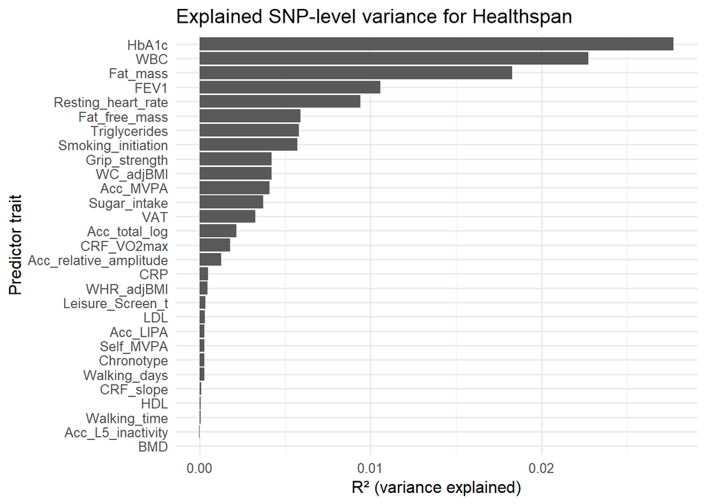

```r
show_regression_block(
  reg_results_all[["Parental_lifespan"]],
  "Parental lifespan"
)
```

**Parental lifespan — Univariate SNP-level regression screening**

Univariate genetic regression: predictors → Parental lifespan

|  | Predictor | Beta | P_value | R2 | Direction |
| --- | --- | --- | --- | --- | --- |
| predictor…1 | Leisure_Screen_t | -0.10569 | 0.00000 | 0.01117 | Negative |
| predictor…2 | CRP | -0.09431 | 0.00000 | 0.00889 | Negative |
| predictor…3 | Self_MVPA | 0.09358 | 0.00000 | 0.00876 | Positive |
| predictor…4 | WHR_adjBMI | -0.05901 | 0.00000 | 0.00348 | Negative |
| predictor…5 | LDL | -0.03145 | 0.00000 | 0.00099 | Negative |
| predictor…6 | Fat_mass | -0.02363 | 0.00000 | 0.00056 | Negative |
| predictor…7 | FEV1 | 0.01983 | 0.00000 | 0.00039 | Positive |
| predictor…8 | Triglycerides | -0.01699 | 0.00000 | 0.00029 | Negative |
| predictor…9 | WBC | -0.01667 | 0.00000 | 0.00028 | Negative |
| predictor…10 | Sugar_intake | -0.01552 | 0.00000 | 0.00024 | Negative |
| predictor…11 | VAT | -0.01540 | 0.00000 | 0.00024 | Negative |
| predictor…12 | Smoking_initiation | -0.01397 | 0.00000 | 0.00020 | Negative |
| predictor…13 | HbA1c | -0.01376 | 0.00000 | 0.00019 | Negative |
| predictor…14 | Acc_MVPA | -0.01332 | 0.00000 | 0.00018 | Negative |
| predictor…15 | Acc_total_log | -0.01250 | 0.00000 | 0.00016 | Negative |
| predictor…16 | Fat_free_mass | -0.01224 | 0.00000 | 0.00015 | Negative |
| predictor…17 | Grip_strength | -0.01060 | 0.00004 | 0.00011 | Negative |
| predictor…18 | Acc_relative_amplitude | -0.00602 | 0.01969 | 0.00004 | Negative |
| predictor…19 | Acc_LIPA | -0.00593 | 0.02155 | 0.00004 | Negative |
| predictor…20 | CRF_VO2max | -0.00548 | 0.03368 | 0.00003 | Negative |
| predictor…21 | Walking_days | -0.00524 | 0.04239 | 0.00003 | Negative |
| predictor…22 | Walking_time | -0.00402 | 0.11967 | 0.00002 | Negative |
| predictor…23 | WC_adjBMI | 0.00322 | 0.21170 | 0.00001 | Positive |
| predictor…24 | Acc_L5_inactivity | -0.00296 | 0.25175 | 0.00001 | Negative |
| predictor…25 | Resting_heart_rate | 0.00287 | 0.26648 | 0.00001 | Positive |
| predictor…26 | BMD | 0.00178 | 0.49062 | 0.00000 | Positive |
| predictor…27 | Chronotype | -0.00100 | 0.69994 | 0.00000 | Negative |
| predictor…28 | HDL | -0.00069 | 0.79062 | 0.00000 | Negative |
| predictor…29 | CRF_slope | -0.00025 | 0.92294 | 0.00000 | Negative |

**Best baseline predictor (highest R²):** Leisure_Screen_t

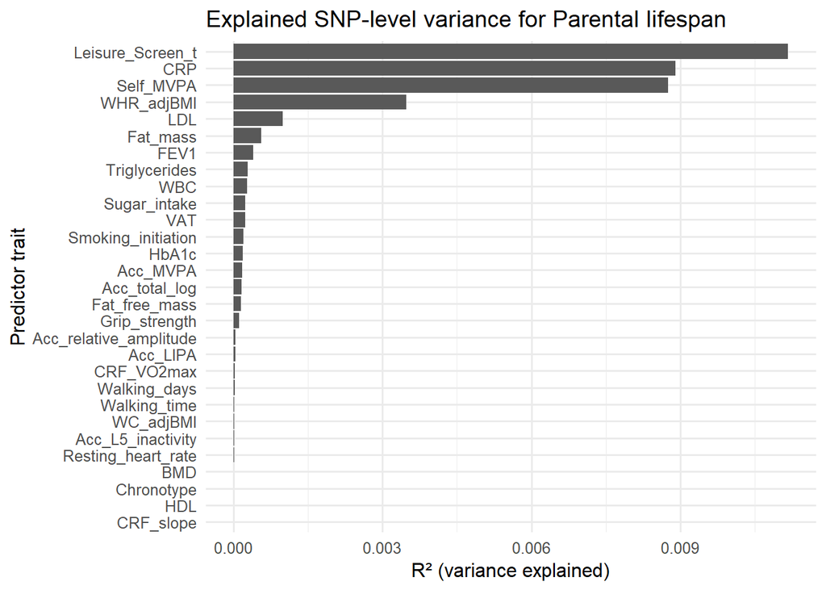

```r
show_regression_block(
  reg_results_all[["Usual_walking_pace"]],
  "Usual walking pace"
)
```

**Usual walking pace — Univariate SNP-level regression screening**

Univariate genetic regression: predictors → Usual walking pace

|  | Predictor | Beta | P_value | R2 | Direction |
| --- | --- | --- | --- | --- | --- |
| predictor…1 | Fat_mass | -0.37510 | 0.00000 | 0.14070 | Negative |
| predictor…2 | WBC | -0.25512 | 0.00000 | 0.06509 | Negative |
| predictor…3 | FEV1 | 0.24675 | 0.00000 | 0.06088 | Positive |
| predictor…4 | Grip_strength | -0.19805 | 0.00000 | 0.03922 | Negative |
| predictor…5 | Resting_heart_rate | 0.18331 | 0.00000 | 0.03360 | Positive |
| predictor…6 | HbA1c | -0.14953 | 0.00000 | 0.02236 | Negative |
| predictor…7 | Acc_MVPA | -0.14441 | 0.00000 | 0.02085 | Negative |
| predictor…8 | VAT | -0.13236 | 0.00000 | 0.01752 | Negative |
| predictor…9 | Triglycerides | -0.12587 | 0.00000 | 0.01584 | Negative |
| predictor…10 | CRF_VO2max | -0.12311 | 0.00000 | 0.01516 | Negative |
| predictor…11 | Walking_days | 0.12118 | 0.00000 | 0.01468 | Positive |
| predictor…12 | Fat_free_mass | -0.11502 | 0.00000 | 0.01323 | Negative |
| predictor…13 | Acc_total_log | -0.11363 | 0.00000 | 0.01291 | Negative |
| predictor…14 | Smoking_initiation | -0.11124 | 0.00000 | 0.01237 | Negative |
| predictor…15 | Acc_relative_amplitude | -0.09878 | 0.00000 | 0.00976 | Negative |
| predictor…16 | Chronotype | -0.06229 | 0.00000 | 0.00388 | Negative |
| predictor…17 | WC_adjBMI | 0.06163 | 0.00000 | 0.00380 | Positive |
| predictor…18 | CRP | -0.06066 | 0.00000 | 0.00368 | Negative |
| predictor…19 | Sugar_intake | -0.05868 | 0.00000 | 0.00344 | Negative |
| predictor…20 | Self_MVPA | 0.05054 | 0.00000 | 0.00255 | Positive |
| predictor…21 | Leisure_Screen_t | -0.04998 | 0.00000 | 0.00250 | Negative |
| predictor…22 | Acc_LIPA | -0.04487 | 0.00000 | 0.00201 | Negative |
| predictor…23 | WHR_adjBMI | -0.02923 | 0.00000 | 0.00085 | Negative |
| predictor…24 | Acc_L5_inactivity | 0.02550 | 0.00000 | 0.00065 | Positive |
| predictor…25 | Walking_time | 0.02043 | 0.00000 | 0.00042 | Positive |
| predictor…26 | BMD | -0.02036 | 0.00000 | 0.00041 | Negative |
| predictor…27 | LDL | -0.01665 | 0.00000 | 0.00028 | Negative |
| predictor…28 | HDL | 0.01116 | 0.00002 | 0.00012 | Positive |
| predictor…29 | CRF_slope | -0.00201 | 0.43615 | 0.00000 | Negative |

**Best baseline predictor (highest R²):** Fat_mass

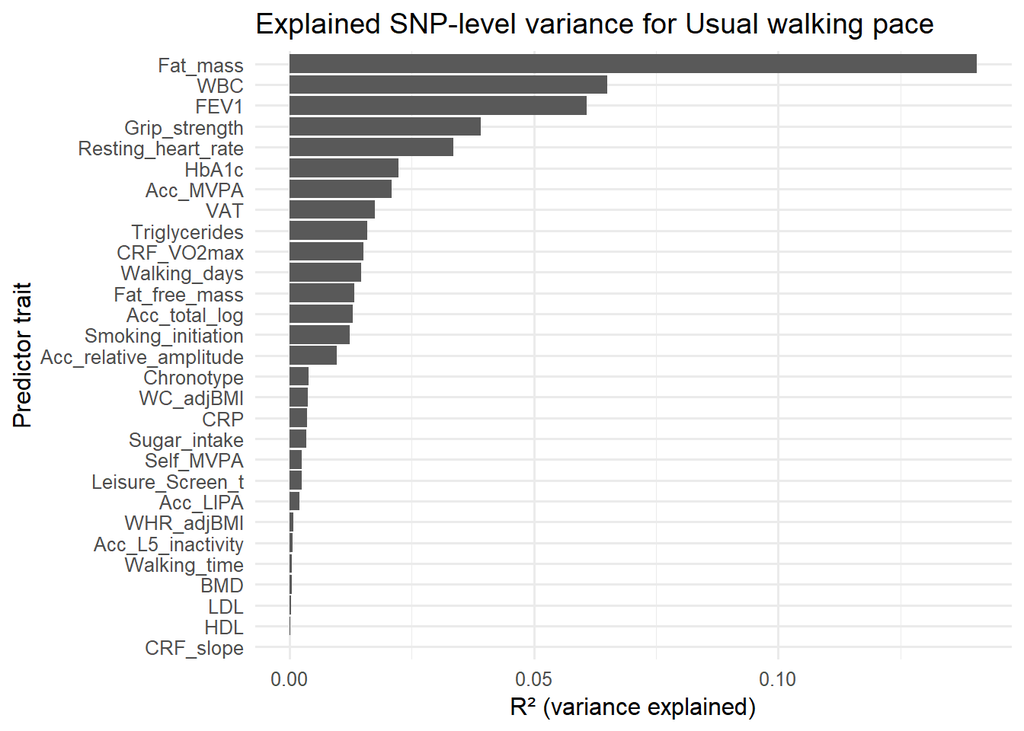

# 21. Overlap of Top Predictors Across Screening Methods (per outcome)

Results from correlation-based and regression-based screening are integrated to identify predictors consistently prioritized across both approaches. Overlap visualization and direction consistency analyses highlight robust genetic contributors to aging outcomes supported by multiple pleiotropic metrics.

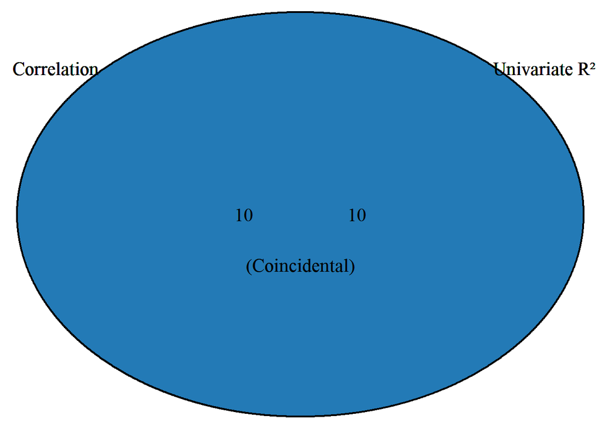

```r
# Overlap of Top Predictors Across Screening Methods (per outcome)

############################################################
# Goal:
# For each aging outcome:
#   Compare top predictors identified by:
#     • correlation screening
#     • univariate regression screening
#   using a Venn diagram and direction consistency check
############################################################

library(dplyr)
library(VennDiagram)
library(knitr)
library(kableExtra)
library(grid)

############################################################
# Outcomes used in baseline screening
############################################################

outcomes <- c(
  "Healthspan",
  "Parental_lifespan",
  "Usual_walking_pace"
)

############################################################
# Loop over outcomes
############################################################

for (out in outcomes) {

  cat("\n<details>\n")
  cat(paste0("<summary><b>", out, " — Overlap of top predictors across methods</b></summary>\n\n"))

  ##########################################################
  # Retrieve correlation + regression tables for this outcome
  # (from Section 17 & 18 results you generated)
  ##########################################################

  cor_df_out <- cor_results_all[[out]]   # you created these per outcome
  reg_df_out <- reg_results_all[[out]]

  ##########################################################
  # Top 10 by absolute correlation
  ##########################################################

  top10_cor <- cor_df_out %>%
    mutate(abs_cor = abs(Correlation)) %>%
    arrange(desc(abs_cor)) %>%
    slice(1:10) %>%
    pull(Predictor)

  ##########################################################
  # Top 10 by explained variance (R²)
  ##########################################################

  top10_r2 <- reg_df_out %>%
    arrange(desc(R2)) %>%
    slice(1:10) %>%
    pull(Predictor)

  ##########################################################
  # Intersection
  ##########################################################

  intersect_traits <- intersect(top10_cor, top10_r2)

  ##########################################################
  # Venn diagram
  ##########################################################

  venn.plot <- draw.pairwise.venn(
    area1 = length(top10_cor),
    area2 = length(top10_r2),
    cross.area = length(intersect_traits),
    category = c("Correlation", "Univariate R²"),
    fill = c("#1f77b4", "#ff7f0e"),
    alpha = 0.5,
    cex = 1.3,
    cat.cex = 1.3
  )

  grid.draw(venn.plot)

  ##########################################################
  # Direction consistency table
  ##########################################################

  direction_df <- data.frame(
    Predictor = intersect_traits,
    Correlation = cor_df_out$Correlation[
      match(intersect_traits, cor_df_out$Predictor)
    ],
    Beta = reg_df_out$Beta[
      match(intersect_traits, reg_df_out$Predictor)
    ],
    stringsAsFactors = FALSE
  )

  direction_df$Sign_correlation <- ifelse(direction_df$Correlation > 0, "Positive", "Negative")
  direction_df$Sign_regression  <- ifelse(direction_df$Beta > 0, "Positive", "Negative")

  direction_df$Consistent_direction <-
    direction_df$Sign_correlation == direction_df$Sign_regression

  ##########################################################
  # Display
  ##########################################################

  kbl(
    direction_df,
    digits = 4,
    caption = paste("Direction consistency of overlapping predictors for", out)
  ) %>%
    kable_styling(full_width = FALSE)

  ##########################################################
  # Quick interpretation
  ##########################################################

  cat("\n")
  cat("Overlapping predictors:", length(intersect_traits), "\n")
  cat(
    "Consistent direction:",
    sum(direction_df$Consistent_direction),
    "/", nrow(direction_df), "\n\n"
  )

  cat("</details>\n\n")
}
```

**Healthspan — Overlap of top predictors across methods**

Overlapping predictors: 10 Consistent direction: 10 / 10

**Parental_lifespan — Overlap of top predictors across methods**

Overlapping predictors: 10 Consistent direction: 10 / 10

**Usual_walking_pace — Overlap of top predictors across methods**

Overlapping predictors: 10 Consistent direction: 10 / 10

```r
rm(pa_lookup, X, snp_sd, snps_ref, X_reduced)
gc(TRUE)
```

```
        used   (Mb) gc trigger   (Mb)   max used    (Mb)
```

Ncells 58982770 3150.1 163420670 8727.7 163420670 8727.7 Vcells 437560697 3338.4 1063414618 8113.3 2816754386 21490.2

# 22. Selection of Baseline Model Traits using LDSC Automation

```r
#############################################
### LDSC AUTOMATION SCRIPT FOR 27 PA TRAITS
### Runs in RStudio, calls Python LDSC
#############################################

library(data.table)
library(stringr)

### ---- 1. Define paths ---- ###
ldsc_path <- "C:/ldsc/"   # folder where ldsc.py and munge_sumstats.py are
ref_ld <- file.path(ldsc_path, "eur_w_ld_chr")
hm3 <- file.path(ldsc_path, "w_hm3.snplist")

pa_folder <- "C:/Users/75118/Desktop/UEA/Proyecto 1/data/"
bmd_file  <- "C:/Users/75118/Desktop/UEA/Proyecto 1/data outcome/Biobank2-British-Bmd-As-C-Gwas-SumStats.txt"

out_folder <- "C:/Users/75118/Desktop/UEA/Proyecto 1/ldsc_results/"
dir.create(out_folder, showWarnings = FALSE)

### ---- 2. List all PA GWAS files ---- ###
pa_files <- list.files(pa_folder, pattern = "\\.tsv$", full.names = TRUE)

### ---- 3. MUNGE BMD FILE ---- ###
bmd_munged <- file.path(out_folder, "BMD.sumstats.gz")

cmd_munge_bmd <- paste(
  "python", file.path(ldsc_path, "munge_sumstats.py"),
  "--sumstats", shQuote(bmd_file),
  "--merge-alleles", shQuote(hm3),
  "--out", shQuote(file.path(out_folder, "BMD"))
)

system(cmd_munge_bmd)
cat("BMD munge done.\n")


### ---- 4. Loop over PA traits: munge + LDSC ---- ###

results <- data.frame(
  trait = character(),
  rg = numeric(),
  se = numeric(),
  p = numeric(),
  stringsAsFactors = FALSE
)

for (f in pa_files) {

  trait_name <- str_replace(basename(f), "_buildGRCh37.tsv", "")
  cat("Processing:", trait_name, "\n")

  ### -- 4A. Munge PA file -- ###
  munged_out <- file.path(out_folder, paste0(trait_name))

  cmd_munge <- paste(
    "python", file.path(ldsc_path, "munge_sumstats.py"),
    "--sumstats", shQuote(f),
    "--merge-alleles", shQuote(hm3),
    "--out", shQuote(munged_out)
  )
  system(cmd_munge)

  ### -- 4B. Run LDSC -- ###
  pa_sumstats <- paste0(munged_out, ".sumstats.gz")
  ldsc_out <- file.path(out_folder, paste0(trait_name, "_vs_BMD"))

  cmd_ldsc <- paste(
    "python", file.path(ldsc_path, "ldsc.py"),
    "--rg", paste0(pa_sumstats, ",", bmd_munged),
    "--ref-ld-chr", shQuote(ref_ld),
    "--w-ld-chr", shQuote(ref_ld),
    "--out", shQuote(ldsc_out)
  )
  system(cmd_ldsc)

  ### -- 4C. Extract rg, SE, p-value from LDSC output -- ###
  log_file <- paste0(ldsc_out, ".log")
  log_text <- readLines(log_file)

  rg_line <- log_text[grepl("Genetic correlation:", log_text)]

  # Example line: "Genetic correlation: -0.2483 (0.062) p = 3e-05"
  rg_val <- sub(".*: (.*) \\(.*", "\\1", rg_line)
  se_val <- sub(".*\\((.*)\\).*", "\\1", rg_line)
  p_val  <- sub(".*p = (.*)", "\\1", rg_line)

  results <- rbind(results,
                   data.frame(trait = trait_name,
                              rg = as.numeric(rg_val),
                              se = as.numeric(se_val),
                              p = as.numeric(p_val)))
}

### ---- 5. Save results ---- ###
write.csv(results, file.path(out_folder, "genetic_correlations_PA_vs_BMD.csv"), row.names = FALSE)

cat("DONE! Results saved.\n")
```